# Adult WEBL provisioning behavior in heat

# Questions & Hypotheses

1. How do adult birds with active nests change their provisioning behavior during hot periods? We hypothesized that adult birds will
1. (H1) reduce their provisioning rates during hot periods because they must put more time and/or energy into thermoregulation to avoid hyperthermia
2. (H1A) increase their provisioning rates during hot periods because they must deliver more energy to compensate for thermoregulatory costs to chicks (water or energy)
2. What mediates how responsive provisioning rates are to temperature?
1. (H1) Less optimal foraging conditions over the prior day will make provisioning rates less responsive to temperature because adults will respond to their chicks being hungrier when they were fed less over the prior day.
2. (H2) females in better condition (mass/tarsus) would be less likely than females in worse condition to reduce their visits during hot periods because they are able to mobilize the energy required to engage in more energetically costly active thermoregulatory behaviors and
3. (H3) Females with higher baseline cort will be less responsive to temperature - possibly because they are exposing themselves to suboptimal conditions
4. (H4) Females with higher stress-induced cort will be more responsive to temperature because they have been experiencing their environment as stressful, and therefore may not have extra energy to put towards thermoregulation during hot periods.
3. How does heat affect female body condition and stress status? baseline and stress-induced?
1. H1: Females that experienced worse heat over the prior week will be more likely to show reduced body condition.
2. H2: females that experienced heat over the prior day will be more likely to show elevated baseline corticosterone levels because they may upregulate their HPA axis in response to more challenging heat conditions
3. H3: females that experienced heat over the prior week will be more likely to show elevated stress-induced corticosterone levels because challenging environmental conditions are correlated with elevated stress-induced corticosterone levels.
4. Does body condition mediate cort response?
1. (H1) females in better body condition would be more likely to show elevated baseline cort after a hot period because they have the energetic capacity to respond to stress
2. (H2) Females in better body condition would be less likely to show elevated stress-induced corticosterone after a hot period than females in worse body condition.

Q4 no longer really fits with this new organization.

# Question 1: How do adult birds with active nests change their provisioning behavior during hot periods?

## Hypothesis 1: We hypothesized that adults will reduce their provisioning rates during hot periods because they must put more time and/or energy into thermoregulation to avoid hyperthermia

Prediction: provis peaks at intermediate temp

## (H1A) increase their provisioning rates during hot periods because they must deliver more energy to compensate for thermoregulatory costs to chicks (water or energy)

### WEBL

```r
m_WEBL <- glmmTMB(valid_detections ~ poly(mean_temp_scaled,2) + poly(tod_h_scaled,2) + mean_nestling_age_scaled + brood_size_scaled + year_fct +  (1|site:attempt_id),
           family = nbinom2(),
           ziformula = ~ (1|site:attempt_id),
           data = dplyr::filter(p,!is.na(mean_temp),
                                  # !is.na(julian_date),
                                  !is.na(mean_nestling_age),
                                  !is.na(brood_size),
                                  !is.na(tod_h),
                                  !is.na(site),
                                  !is.na(attempt_id),
                                  !is.na(year_fct),
                                  species == "WEBL"# ,
                                                # tod >= hms::as.hms('11:00:00', tz = "America/Los_Angeles"),
                                                # tod_end <= hms::as.hms('17:00:00',tz = "America/Los_Angeles"),
                                                # tod_end >= hms::as.hms('11:00:00', tz = "America/Los_Angeles")
                                                ) %>%
                        mutate(across(c(tod_h,mean_temp,julian_date,mean_nestling_age,brood_size),
                                                    ~ scale(.x)[,1],
                                                    .names = "{.col}_scaled")),
           )

m_WEBL_notod <- glmmTMB(valid_detections ~ poly(mean_temp_scaled,2) + mean_nestling_age_scaled + brood_size_scaled + year_fct +  (1|site:attempt_id),
           family = nbinom2(),
           ziformula = ~ (1|site:attempt_id),
           data = dplyr::filter(p,!is.na(mean_temp),
                                  # !is.na(julian_date),
                                  !is.na(mean_nestling_age),
                                  !is.na(brood_size),
                                  !is.na(tod_h),
                                  !is.na(site),
                                  !is.na(attempt_id),
                                  !is.na(year_fct),
                                  species == "WEBL"# ,
                                                # tod >= hms::as.hms('11:00:00', tz = "America/Los_Angeles"),
                                                # tod_end <= hms::as.hms('17:00:00',tz = "America/Los_Angeles"),
                                                # tod_end >= hms::as.hms('11:00:00', tz = "America/Los_Angeles")
                                                ) %>%
                        mutate(across(c(tod_h,mean_temp,julian_date,mean_nestling_age,brood_size),
                                                    ~ scale(.x)[,1],
                                                    .names = "{.col}_scaled")),
           )

# m_WEBL_linint <- glmmTMB(valid_detections ~ mean_temp_scaled * habitat + poly(mean_temp_scaled,degree = 2) + poly(tod_h_scaled,2) + mean_nestling_age_scaled + brood_size_scaled + year_fct + (1|site:attempt_id),
#            family = nbinom2(),
#            ziformula = ~ (1|attempt_id),
#            data = dplyr::filter(p,!is.na(mean_temp),
#                                 # !is.na(julian_date),
#                                 !is.na(mean_nestling_age),
#                                 !is.na(brood_size),
#                                 !is.na(tod_h),
#                                 !is.na(site),
#                                 !is.na(attempt_id),
#                                 !is.na(year),
#                                 species == "WEBL"# ,
#                                               # tod >= hms::as.hms('11:00:00', tz = "America/Los_Angeles"),
#                                               # tod_end <= hms::as.hms('17:00:00',tz = "America/Los_Angeles"),
#                                               # tod_end >= hms::as.hms('11:00:00', tz = "America/Los_Angeles")
#                                               ) %>%
#                       mutate(across(c(tod_h,mean_temp,julian_date,mean_nestling_age,brood_size),
#                                                   ~ scale(.x)[,1],
#                                                   .names = "{.col}_scaled")),
#            )
#
# m_WEBL_noint <- glmmTMB(valid_detections ~ habitat + poly(mean_temp_scaled,degree = 2) + poly(tod_h_scaled,2) + mean_nestling_age_scaled + brood_size_scaled + year_fct + (1|site:attempt_id),
#            family = nbinom2(),
#            ziformula = ~ (1|attempt_id),
#            data = dplyr::filter(p,!is.na(mean_temp),
#                                 # !is.na(julian_date),
#                                 !is.na(mean_nestling_age),
#                                 !is.na(brood_size),
#                                 !is.na(tod_h),
#                                 !is.na(site),
#                                 !is.na(attempt_id),
#                                 !is.na(year),
#                                 species == "WEBL"# ,
#                                               # tod >= hms::as.hms('11:00:00', tz = "America/Los_Angeles"),
#                                               # tod_end <= hms::as.hms('17:00:00',tz = "America/Los_Angeles"),
#                                               # tod_end >= hms::as.hms('11:00:00', tz = "America/Los_Angeles")
#                                               ) %>%
#                       mutate(across(c(tod_h,mean_temp,julian_date,mean_nestling_age,brood_size),
#                                                   ~ scale(.x)[,1],
#                                                   .names = "{.col}_scaled")),
#            )




c <- anova(m_WEBL,m_WEBL_notod) %>% tibble() %>% mutate(Model = c("No time of day term","Squared time of day term"),.before = Df)

(tab <- c %>%
  as.tibble() %>%
  mutate(across(where(is.numeric),~round(.x,digits = 4)),
         P = `Pr(>Chisq)`) %>%
  dplyr::select(Model,AIC,Chisq,P) %>%
  mutate(across(c(AIC,Chisq), ~ round(.x, digits = 2)),
         P = if_else(P < 0.001,"<0.001",as.character(P))) %>% gt())
```

| Model | AIC | Chisq | P |
| --- | --- | --- | --- |
| No time of day term | 1857.66 | NA | NA |
| Squared time of day term | 1858.29 | 3.37 | 0.1856 |

```r
gtsave(tab,"../figures/int_tab_provis_ch3_webl.html")

summary(m_WEBL_notod)
```

```
##  Family: nbinom2  ( log )
## Formula:
## valid_detections ~ poly(mean_temp_scaled, 2) + mean_nestling_age_scaled +
##     brood_size_scaled + year_fct + (1 | site:attempt_id)
## Zero inflation:                    ~(1 | site:attempt_id)
## Data: dplyr::filter(p, !is.na(mean_temp), !is.na(mean_nestling_age),
##     !is.na(brood_size), !is.na(tod_h), !is.na(site), !is.na(attempt_id),
##     !is.na(year_fct), species == "WEBL") %>% mutate(across(c(tod_h,
##     mean_temp, julian_date, mean_nestling_age, brood_size), ~scale(.x)[,
##     1], .names = "{.col}_scaled"))
##
##      AIC      BIC   logLik deviance df.resid
##   1857.7   1899.0   -917.8   1835.7      306
##
## Random effects:
##
## Conditional model:
##  Groups          Name        Variance Std.Dev.
##  site:attempt_id (Intercept) 0.1781   0.422
## Number of obs: 317, groups:  site:attempt_id, 29
##
## Zero-inflation model:
##  Groups          Name        Variance Std.Dev.
##  site:attempt_id (Intercept) 4.826    2.197
## Number of obs: 317, groups:  site:attempt_id, 29
##
## Dispersion parameter for nbinom2 family (): 4.57
##
## Conditional model:
##                            Estimate Std. Error z value Pr(>|z|)
## (Intercept)                 2.39538    0.34065   7.032 2.04e-12 ***
## poly(mean_temp_scaled, 2)1 -1.76929    0.88460  -2.000   0.0455 *
## poly(mean_temp_scaled, 2)2 -0.13693    0.78543  -0.174   0.8616
## mean_nestling_age_scaled    0.21471    0.04693   4.575 4.76e-06 ***
## brood_size_scaled           0.14887    0.11171   1.333   0.1827
## year_fct2022               -0.36480    0.38199  -0.955   0.3396
## year_fct2023               -0.48220    0.37589  -1.283   0.1996
## ---
## Signif. codes:  0 '***' 0.001 '**' 0.01 '*' 0.05 '.' 0.1 ' ' 1
##
## Zero-inflation model:
##             Estimate Std. Error z value Pr(>|z|)
## (Intercept)  -3.0958     0.6914  -4.478 7.55e-06 ***
## ---
## Signif. codes:  0 '***' 0.001 '**' 0.01 '*' 0.05 '.' 0.1 ' ' 1
```

```r
m_webl_q1h1 <- m_WEBL_notod

check_zeroinflation(m_WEBL_notod)
```

```
## # Check for zero-inflation
##
##    Observed zeros: 45
##   Predicted zeros: 50
##             Ratio: 1.10
```

[output not shown]

```r
# (t <- emtrends(m_webl_q1h1,specs = ~ habitat, var = c("mean_temp_scaled"),max.degree = 1) %>% test() %>%
#    mutate(across(where(is.numeric), ~ round(.x, digits = 3)),
#           df = round(df),
#           p.value = if_else(p.value == 0.000,"<0.001",as.character(p.value))) %>%
#    rename(Habitat = "habitat", `Max temp trend` = "mean_temp_scaled.trend",Df = "df", `Z-ratio` = "z.ratio", P = "p.value") %>%
#    #group_by(degree) %>%
#    gt())

ss_year_webl_provis <- m_webl_q1h1$frame %>%
  group_by(year_fct) %>%
  summarize(count_ind = n(),count_attempt = n_distinct(attempt_id)) %>%
  rowwise() %>%
  mutate(count = tibble(count_ind,count_attempt)) %>%
  dplyr::select(-c(count_ind, count_attempt)) %>%
  pivot_wider(values_from = count,names_from = year_fct) %>%
  as.tibble() %>% # rename(Habitat = 'habitat') %>%
  ungroup() %>%
  mutate(`2021` = replace_na(`2021`,list(count_ind = 0,count_attempt = 0))) %>%
  mutate(Total = `2021` + `2022` + `2023`) %>%
  rowwise() %>%
  mutate(`2021` = paste0(`2021`$count_ind,", ",`2021`$count_attempt),
         `2022` = paste0(`2022`$count_ind,", ",`2022`$count_attempt),
         `2023` = paste0(`2023`$count_ind,", ",`2023`$count_attempt),
         Total = paste0(Total$count_ind,", ",Total$count_attempt)
  )

(t_ss_year_webl_provis <- ss_year_webl_provis %>% gt() %>%
    grand_summary_rows(fns = list(id = "Total") ~ {
      t <- str_split(.,", ",simplify = TRUE)
      t[,1] %>% as.numeric() %>% sum(na.rm = TRUE) %>% paste(t[,2] %>% as.numeric() %>% sum(na.rm = TRUE),sep = ", ")
    })
)
```

|  | 2021 | 2022 | 2023 | Total |
| --- | --- | --- | --- | --- |
|  | 21, 3 | 153, 12 | 143, 14 | 317, 29 |
| Total | 21, 3 | 153, 12 | 143, 14 | 317, 29 |

```r
t_ss_year_webl_provis %>% gtsave("../figures/ss_year_webl_provis_ch3.html")

samp <- m_webl_q1h1$frame %>% summarize(count = n())
samp %>% gt() %>% gtsave("../figures/ss_webl_provis_ch3.html")


dat_text_webl_q1h1 <- data.frame(
  label = paste("N =",samp$count)# ,
  #group   = factor(c("Forest","Orchard","Grassland","Row crop"))
)

## num nestboxes
m_webl_q1h1$frame %>% pull(attempt_id) %>% unique() %>% length()
```

```
## [1] 29
```

```
## You are calculating adjusted predictions on the population-level (i.e.
##   `type = "fixed"`) for a *generalized* linear mixed model.
##   This may produce biased estimates due to Jensen's inequality. Consider
##   setting `bias_correction = TRUE` to correct for this bias.
##   See also the documentation of the `bias_correction` argument.
```

```
## Data points may overlap. Use the `jitter` argument to add some amount of
##   random variation to the location of data points and avoid overplotting.
```

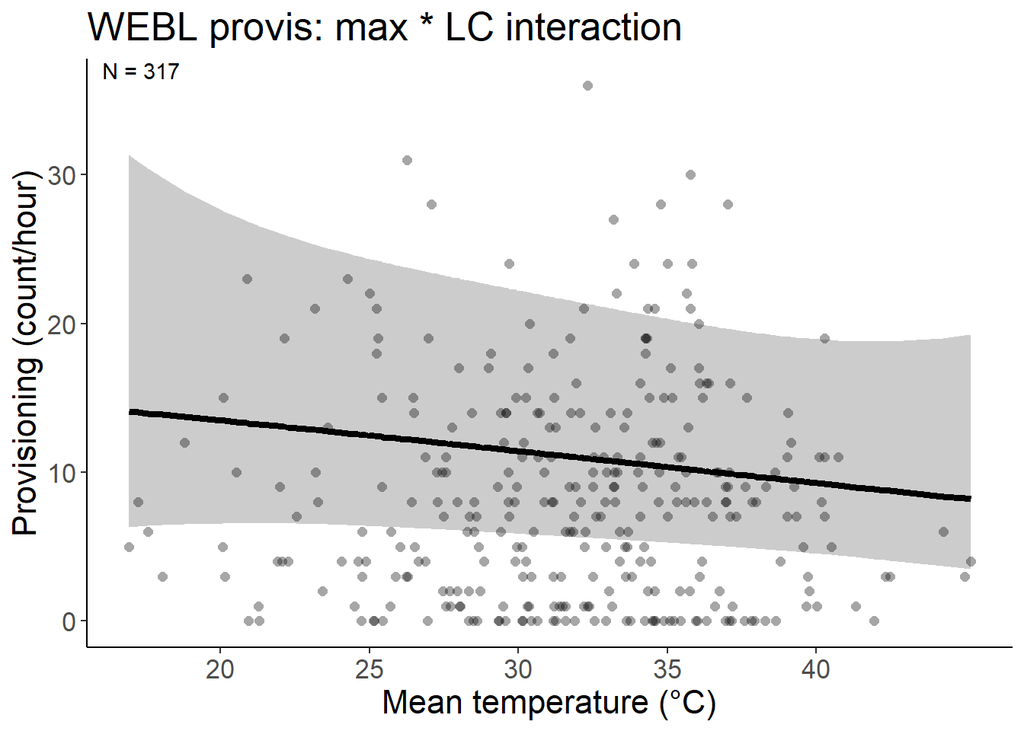

```r
data_webl_q1h1 = dplyr::filter(p,!is.na(mean_temp),
                                  # !is.na(julian_date),
                                  !is.na(mean_nestling_age),
                                  !is.na(brood_size),
                                  !is.na(tod_h),
                                  !is.na(site),
                                  !is.na(attempt_id),
                                  !is.na(year),
                                  species == "WEBL"# ,
                                                # tod >= hms::as.hms('11:00:00', tz = "America/Los_Angeles"),
                                                # tod_end <= hms::as.hms('17:00:00',tz = "America/Los_Angeles"),
                                                # tod_end >= hms::as.hms('11:00:00', tz = "America/Los_Angeles")
                                                ) %>%
                        mutate(across(c(tod_h,mean_temp,julian_date,mean_nestling_age,brood_size),
                                                    ~ scale(.x)[,1],
                                                    .names = "{.col}_scaled"))


mean_temp_webl_q1h1 <- mean(data_webl_q1h1 %>% pull(mean_temp))
sd_temp_webl_q1h1 <- sd(data_webl_q1h1 %>% pull(mean_temp))


temp_trans_webl_q1h1 <- trans_new("temp_trans_webl_q1h1",
                             transform = function(x){(x * sd_temp_webl_q1h1) + mean_temp_webl_q1h1},
                             inverse = function(x){x})

(figq1h1_webl <- predict_response(m_webl_q1h1,terms = c("mean_temp_scaled [all]")) %>%
    plot(line_size = 1.5,alpha = .2,show_data = TRUE,limit_range = TRUE) +
    aes(linetype = .data[["group"]]) +
    theme_classic() +
    # facet_wrap(~ group, ncol = 2) +
    xlab("Mean temperature (\u00b0C)") +
    ylab("Provisioning (count/hour)") +
    scale_fill_viridis(discrete = TRUE) +
    scale_color_viridis(discrete = TRUE) +
    theme(text = element_text(size = 16)) +
    labs(title =  "WEBL provis: max * LC interaction") +
    scale_x_continuous(trans = temp_trans_webl_q1h1,
                       breaks = c((20-mean_temp_webl_q1h1)/sd_temp_webl_q1h1,
                                  (25-mean_temp_webl_q1h1)/sd_temp_webl_q1h1,
                                  (30-mean_temp_webl_q1h1)/sd_temp_webl_q1h1,
                                  (35-mean_temp_webl_q1h1)/sd_temp_webl_q1h1,
                                  (40-mean_temp_webl_q1h1)/sd_temp_webl_q1h1),
                       # breaks = c(20,30,40,50),
                       # labels = c("20","30","40","50"),
                       # limits = c((15-mean(g$meanmaxtempI,na.rm = TRUE))/sd(g$meanmaxtempI,na.rm = TRUE),
                       #            (55-mean(g$meanmaxtempI,na.rm = TRUE))/sd(g$meanmaxtempI,na.rm = TRUE))
                       # limits = c(18,5)
    ) +
    scale_linetype_manual(values = "solid") +
    #ylim(-5,5) +
    geom_text(data = dat_text_webl_q1h1, mapping = aes(x = -Inf, y = Inf,label = label),hjust = -.2, vjust = 1.2,inherit.aes = FALSE) +
    theme(legend.position = "none")
)
```

```r
ggsave("../figures/provisbymaxtempxhab_WEBL_q1h1.png",plot =  figq1h1_webl, width = 10, height = 6.6)
```

Another question out of this is, are the adults responding to their own physiological state or are they responding to nestlings’ condition? The tough part is that I could imagine that they’re responding to nestlings’ begging behavior. Does begging behavior peak at some intermediate condition (i.e. when nestlings are really hungry but not yet weakened by it), or is it strongest when nestlings are fed well?

From the reading, it looks like what we should expect is that in resource-poor environments (i.e. agriculture), provisioning should respond to quality of nestlings, whereas in resource-poor environments, provisioning should respond to need of nestlings. But also, in the short term, nestling begging rate is driven by hunger, and generally reduced in small nestlings in large broods.

### TRES

```r
m_TRES <- glmmTMB(valid_detections ~ poly(mean_temp_scaled,2) + poly(tod_h_scaled,2) + mean_nestling_age_scaled + brood_size_scaled + year_fct +  (1|site:attempt_id),
           family = nbinom2(),
           ziformula = ~ (1|site:attempt_id),
           data = dplyr::filter(p,!is.na(mean_temp),
                                  # !is.na(julian_date),
                                  !is.na(mean_nestling_age),
                                  !is.na(brood_size),
                                  !is.na(tod_h),
                                  !is.na(site),
                                  !is.na(attempt_id),
                                  !is.na(year_fct),
                                  species == "TRES"# ,
                                                # tod >= hms::as.hms('11:00:00', tz = "America/Los_Angeles"),
                                                # tod_end <= hms::as.hms('17:00:00',tz = "America/Los_Angeles"),
                                                # tod_end >= hms::as.hms('11:00:00', tz = "America/Los_Angeles")
                                                ) %>%
                        mutate(across(c(tod_h,mean_temp,julian_date,mean_nestling_age,brood_size),
                                                    ~ scale(.x)[,1],
                                                    .names = "{.col}_scaled")),
           )

m_TRES_notod <- glmmTMB(valid_detections ~ poly(mean_temp_scaled,2) + mean_nestling_age_scaled + brood_size_scaled + year_fct +  (1|site:attempt_id),
           family = nbinom2(),
           ziformula = ~ (1|site:attempt_id),
           data = dplyr::filter(p,!is.na(mean_temp),
                                  # !is.na(julian_date),
                                  !is.na(mean_nestling_age),
                                  !is.na(brood_size),
                                  !is.na(tod_h),
                                  !is.na(site),
                                  !is.na(attempt_id),
                                  !is.na(year_fct),
                                  species == "TRES"# ,
                                                # tod >= hms::as.hms('11:00:00', tz = "America/Los_Angeles"),
                                                # tod_end <= hms::as.hms('17:00:00',tz = "America/Los_Angeles"),
                                                # tod_end >= hms::as.hms('11:00:00', tz = "America/Los_Angeles")
                                                ) %>%
                        mutate(across(c(tod_h,mean_temp,julian_date,mean_nestling_age,brood_size),
                                                    ~ scale(.x)[,1],
                                                    .names = "{.col}_scaled")),
           )

# m_TRES_linint <- glmmTMB(valid_detections ~ mean_temp_scaled * habitat + poly(mean_temp_scaled,degree = 2) + poly(tod_h_scaled,2) + mean_nestling_age_scaled + brood_size_scaled + year_fct + (1|site:attempt_id),
#            family = nbinom2(),
#            ziformula = ~ (1|attempt_id),
#            data = dplyr::filter(p,!is.na(mean_temp),
#                                 # !is.na(julian_date),
#                                 !is.na(mean_nestling_age),
#                                 !is.na(brood_size),
#                                 !is.na(tod_h),
#                                 !is.na(site),
#                                 !is.na(attempt_id),
#                                 !is.na(year),
#                                 species == "TRES"# ,
#                                               # tod >= hms::as.hms('11:00:00', tz = "America/Los_Angeles"),
#                                               # tod_end <= hms::as.hms('17:00:00',tz = "America/Los_Angeles"),
#                                               # tod_end >= hms::as.hms('11:00:00', tz = "America/Los_Angeles")
#                                               ) %>%
#                       mutate(across(c(tod_h,mean_temp,julian_date,mean_nestling_age,brood_size),
#                                                   ~ scale(.x)[,1],
#                                                   .names = "{.col}_scaled")),
#            )
#
# m_TRES_noint <- glmmTMB(valid_detections ~ habitat + poly(mean_temp_scaled,degree = 2) + poly(tod_h_scaled,2) + mean_nestling_age_scaled + brood_size_scaled + year_fct + (1|site:attempt_id),
#            family = nbinom2(),
#            ziformula = ~ (1|attempt_id),
#            data = dplyr::filter(p,!is.na(mean_temp),
#                                 # !is.na(julian_date),
#                                 !is.na(mean_nestling_age),
#                                 !is.na(brood_size),
#                                 !is.na(tod_h),
#                                 !is.na(site),
#                                 !is.na(attempt_id),
#                                 !is.na(year),
#                                 species == "TRES"# ,
#                                               # tod >= hms::as.hms('11:00:00', tz = "America/Los_Angeles"),
#                                               # tod_end <= hms::as.hms('17:00:00',tz = "America/Los_Angeles"),
#                                               # tod_end >= hms::as.hms('11:00:00', tz = "America/Los_Angeles")
#                                               ) %>%
#                       mutate(across(c(tod_h,mean_temp,julian_date,mean_nestling_age,brood_size),
#                                                   ~ scale(.x)[,1],
#                                                   .names = "{.col}_scaled")),
#            )




c <- anova(m_TRES,m_TRES_notod) %>% tibble() %>% mutate(Model = c("No time of day term","Squared time of day term"),.before = Df)

(tab <- c %>%
  as.tibble() %>%
  mutate(across(where(is.numeric),~round(.x,digits = 4)),
         P = `Pr(>Chisq)`) %>%
  dplyr::select(Model,AIC,Chisq,P) %>%
  mutate(across(c(AIC,Chisq), ~ round(.x, digits = 2)),
         P = if_else(P < 0.001,"<0.001",as.character(P))) %>% gt())
```

| Model | AIC | Chisq | P |
| --- | --- | --- | --- |
| No time of day term | 1502.87 | NA | NA |
| Squared time of day term | 1499.71 | 7.15 | 0.028 |

```r
gtsave(tab,"../figures/int_tab_provis_ch3_tres.html")

summary(m_TRES)
```

```
##  Family: nbinom2  ( log )
## Formula:
## valid_detections ~ poly(mean_temp_scaled, 2) + poly(tod_h_scaled,
##     2) + mean_nestling_age_scaled + brood_size_scaled + year_fct +
##     (1 | site:attempt_id)
## Zero inflation:                    ~(1 | site:attempt_id)
## Data: dplyr::filter(p, !is.na(mean_temp), !is.na(mean_nestling_age),
##     !is.na(brood_size), !is.na(tod_h), !is.na(site), !is.na(attempt_id),
##     !is.na(year_fct), species == "TRES") %>% mutate(across(c(tod_h,
##     mean_temp, julian_date, mean_nestling_age, brood_size), ~scale(.x)[,
##     1], .names = "{.col}_scaled"))
##
##      AIC      BIC   logLik deviance df.resid
##   1499.7   1544.5   -736.9   1473.7      218
##
## Random effects:
##
## Conditional model:
##  Groups          Name        Variance Std.Dev.
##  site:attempt_id (Intercept) 0.2058   0.4537
## Number of obs: 231, groups:  site:attempt_id, 23
##
## Zero-inflation model:
##  Groups          Name        Variance Std.Dev.
##  site:attempt_id (Intercept) 3.985    1.996
## Number of obs: 231, groups:  site:attempt_id, 23
##
## Dispersion parameter for nbinom2 family (): 3.37
##
## Conditional model:
##                            Estimate Std. Error z value Pr(>|z|)
## (Intercept)                 2.62996    0.23365  11.256  < 2e-16 ***
## poly(mean_temp_scaled, 2)1  5.93888    1.66099   3.575  0.00035 ***
## poly(mean_temp_scaled, 2)2 -1.77555    0.91846  -1.933  0.05321 .
## poly(tod_h_scaled, 2)1      0.98665    0.80486   1.226  0.22025
## poly(tod_h_scaled, 2)2      2.39314    1.15884   2.065  0.03891 *
## mean_nestling_age_scaled   -0.01391    0.07273  -0.191  0.84829
## brood_size_scaled           0.29801    0.15060   1.979  0.04784 *
## year_fct2022                0.10218    0.37370   0.273  0.78453
## year_fct2023               -0.32976    0.30153  -1.094  0.27412
## ---
## Signif. codes:  0 '***' 0.001 '**' 0.01 '*' 0.05 '.' 0.1 ' ' 1
##
## Zero-inflation model:
##             Estimate Std. Error z value Pr(>|z|)
## (Intercept)  -2.2349     0.6162  -3.627 0.000287 ***
## ---
## Signif. codes:  0 '***' 0.001 '**' 0.01 '*' 0.05 '.' 0.1 ' ' 1
```

```r
m_tres_q1h1 <- m_TRES

check_zeroinflation(m_TRES)
```

```
## # Check for zero-inflation
##
##    Observed zeros: 51
##   Predicted zeros: 51
##             Ratio: 1.00
```

```
## Model seems ok, ratio of observed and predicted zeros is within the
##   tolerance range (p = 0.904).
```

```r
# (t <- emtrends(m_tres_q1h1,specs = ~ habitat, var = c("mean_temp_scaled"),max.degree = 1) %>% test() %>%
#    mutate(across(where(is.numeric), ~ round(.x, digits = 3)),
#           df = round(df),
#           p.value = if_else(p.value == 0.000,"<0.001",as.character(p.value))) %>%
#    rename(Habitat = "habitat", `Max temp trend` = "mean_temp_scaled.trend",Df = "df", `Z-ratio` = "z.ratio", P = "p.value") %>%
#    #group_by(degree) %>%
#    gt())

ss_year_tres_provis <- m_tres_q1h1$frame %>%
  group_by(year_fct) %>%
  summarize(count_ind = n(),count_attempt = n_distinct(attempt_id)) %>%
  rowwise() %>%
  mutate(count = tibble(count_ind,count_attempt)) %>%
  dplyr::select(-c(count_ind, count_attempt)) %>%
  pivot_wider(values_from = count,names_from = year_fct) %>%
  as.tibble() %>% # rename(Habitat = 'habitat') %>%
  ungroup() %>%
  mutate(`2021` = replace_na(`2021`,list(count_ind = 0,count_attempt = 0))) %>%
  mutate(Total = `2021` + `2022` + `2023`) %>%
  rowwise() %>%
  mutate(`2021` = paste0(`2021`$count_ind,", ",`2021`$count_attempt),
         `2022` = paste0(`2022`$count_ind,", ",`2022`$count_attempt),
         `2023` = paste0(`2023`$count_ind,", ",`2023`$count_attempt),
         Total = paste0(Total$count_ind,", ",Total$count_attempt)
  )

(t_ss_year_tres_provis <- ss_year_tres_provis %>% gt() %>%
    grand_summary_rows(fns = list(id = "Total") ~ {
      t <- str_split(.,", ",simplify = TRUE)
      t[,1] %>% as.numeric() %>% sum(na.rm = TRUE) %>% paste(t[,2] %>% as.numeric() %>% sum(na.rm = TRUE),sep = ", ")
    })
)
```

|  | 2021 | 2022 | 2023 | Total |
| --- | --- | --- | --- | --- |
|  | 64, 7 | 75, 7 | 92, 9 | 231, 23 |
| Total | 64, 7 | 75, 7 | 92, 9 | 231, 23 |

```r
t_ss_year_tres_provis %>% gtsave("../figures/ss_year_tres_provis_ch3.html")

samp <- m_tres_q1h1$frame %>% summarize(count = n())
samp %>% gt() %>% gtsave("../figures/ss_tres_provis_ch3.html")


dat_text_tres_q1h1 <- data.frame(
  label = paste("N =",samp$count)# ,
  #group   = factor(c("Forest","Orchard","Grassland","Row crop"))
)

## num nestboxes
m_tres_q1h1$frame %>% pull(attempt_id) %>% unique() %>% length()
```

```
## [1] 23
```

```
## Data points may overlap. Use the `jitter` argument to add some amount of
##   random variation to the location of data points and avoid overplotting.
```

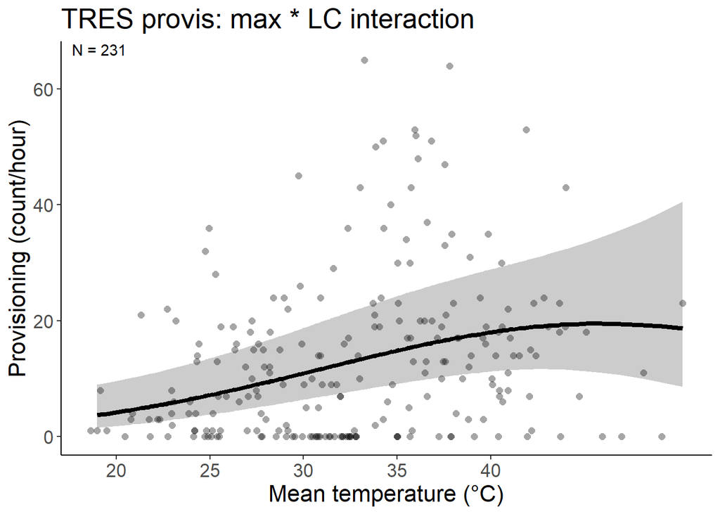

```r
data_tres_q1h1 = dplyr::filter(p,!is.na(mean_temp),
                                  # !is.na(julian_date),
                                  !is.na(mean_nestling_age),
                                  !is.na(brood_size),
                                  !is.na(tod_h),
                                  !is.na(site),
                                  !is.na(attempt_id),
                                  !is.na(year),
                                  species == "TRES"# ,
                                                # tod >= hms::as.hms('11:00:00', tz = "America/Los_Angeles"),
                                                # tod_end <= hms::as.hms('17:00:00',tz = "America/Los_Angeles"),
                                                # tod_end >= hms::as.hms('11:00:00', tz = "America/Los_Angeles")
                                                ) %>%
                        mutate(across(c(tod_h,mean_temp,julian_date,mean_nestling_age,brood_size),
                                                    ~ scale(.x)[,1],
                                                    .names = "{.col}_scaled"))


mean_temp_tres_q1h1 <- mean(data_tres_q1h1 %>% pull(mean_temp))
sd_temp_tres_q1h1 <- sd(data_tres_q1h1 %>% pull(mean_temp))


temp_trans_tres_q1h1 <- trans_new("temp_trans_tres_q1h1",
                             transform = function(x){(x * sd_temp_tres_q1h1) + mean_temp_tres_q1h1},
                             inverse = function(x){x})

(figq1h1_tres <- predict_response(m_tres_q1h1,terms = c("mean_temp_scaled [all]")) %>%
    plot(line_size = 1.5,alpha = .2,show_data = TRUE,limit_range = TRUE) +
    aes(linetype = .data[["group"]]) +
    theme_classic() +
    # facet_wrap(~ group, ncol = 2) +
    xlab("Mean temperature (\u00b0C)") +
    ylab("Provisioning (count/hour)") +
    scale_fill_viridis(discrete = TRUE) +
    scale_color_viridis(discrete = TRUE) +
    theme(text = element_text(size = 16)) +
    labs(title =  "TRES provis: max * LC interaction") +
    scale_x_continuous(trans = temp_trans_tres_q1h1,
                       breaks = c((20-mean_temp_tres_q1h1)/sd_temp_tres_q1h1,
                                  (25-mean_temp_tres_q1h1)/sd_temp_tres_q1h1,
                                  (30-mean_temp_tres_q1h1)/sd_temp_tres_q1h1,
                                  (35-mean_temp_tres_q1h1)/sd_temp_tres_q1h1,
                                  (40-mean_temp_tres_q1h1)/sd_temp_tres_q1h1),
                       # breaks = c(20,30,40,50),
                       # labels = c("20","30","40","50"),
                       # limits = c((15-mean(g$meanmaxtempI,na.rm = TRUE))/sd(g$meanmaxtempI,na.rm = TRUE),
                       #            (55-mean(g$meanmaxtempI,na.rm = TRUE))/sd(g$meanmaxtempI,na.rm = TRUE))
                       # limits = c(18,5)
    ) +
    scale_linetype_manual(values = "solid") +
    #ylim(-5,5) +
    geom_text(data = dat_text_tres_q1h1, mapping = aes(x = -Inf, y = Inf,label = label),hjust = -.2, vjust = 1.2,inherit.aes = FALSE) +
    theme(legend.position = "none")
)
```

```r
ggsave("../figures/provisbymaxtempxhab_TRES_q1h1.png",plot =  figq1h1_tres, width = 10, height = 6.6)
```

So WEBL decrease provis with temp and TRES increase provis with temp.

## Q2H1

2. What mediates how responsive provisioning rates are to temperature?
1. (H1) Less optimal foraging conditions over the prior day will make provisioning rates less responsive to temperature because adults will respond to their chicks being hungrier when they were fed less over the prior day.

provis ~ priordaytempgoodness * tnow^2

How to measure prior day temp goodness? 1. degree hours of difference from 35C (both cold and hot contribute to less optimal) 2. Degree hours of difference from 30C (both cold and hot contribute to less optimal) 3 Degree hours above 35C 4. Degree hours above 30C 5. Maximum temperature of the prior day

```r
p <- read_rds("../data/provis_manytempmeasures.rds")
```

## Degree hours difference from 35C

### WEBL

```r
m_WEBL <- glmmTMB(valid_detections ~ poly(mean_temp_scaled,2) * deghours_diff_35C_priorday_scaled + poly(tod_h_scaled,2) + mean_nestling_age_scaled + brood_size_scaled + year_fct +  (1|site:attempt_id),
           family = nbinom2(),
           ziformula = ~ attempt_id,
           data = dplyr::filter(p,!is.na(mean_temp),
                                  # !is.na(julian_date),
                                  !is.na(mean_nestling_age),
                                  !is.na(deghours_diff_35C_priorday),
                                  !is.na(brood_size),
                                  !is.na(tod_h),
                                  !is.na(site),
                                  !is.na(attempt_id),
                                  !is.na(year_fct),
                                  species == "WEBL"# ,
                                                # tod >= hms::as.hms('11:00:00', tz = "America/Los_Angeles"),
                                                # tod_end <= hms::as.hms('17:00:00',tz = "America/Los_Angeles"),
                                                # tod_end >= hms::as.hms('11:00:00', tz = "America/Los_Angeles")
                                                ) %>%
                        mutate(across(c(tod_h,mean_temp,deghours_diff_35C_priorday,julian_date,mean_nestling_age,brood_size),
                                                    ~ scale(.x)[,1],
                                                    .names = "{.col}_scaled")),
           )

summary(m_WEBL)
```

```
##  Family: nbinom2  ( log )
## Formula:
## valid_detections ~ poly(mean_temp_scaled, 2) * deghours_diff_35C_priorday_scaled +
##     poly(tod_h_scaled, 2) + mean_nestling_age_scaled + brood_size_scaled +
##     year_fct + (1 | site:attempt_id)
## Zero inflation:                    ~attempt_id
## Data: dplyr::filter(p, !is.na(mean_temp), !is.na(mean_nestling_age),
##     !is.na(deghours_diff_35C_priorday), !is.na(brood_size), !is.na(tod_h),
##     !is.na(site), !is.na(attempt_id), !is.na(year_fct), species ==
##         "WEBL") %>% mutate(across(c(tod_h, mean_temp, deghours_diff_35C_priorday,
##     julian_date, mean_nestling_age, brood_size), ~scale(.x)[,
##     1], .names = "{.col}_scaled"))
##
##      AIC      BIC   logLik deviance df.resid
##   1857.8   2019.4   -885.9   1771.8      274
##
## Random effects:
##
## Conditional model:
##  Groups          Name        Variance Std.Dev.
##  site:attempt_id (Intercept) 0.1816   0.4261
## Number of obs: 317, groups:  site:attempt_id, 29
##
## Dispersion parameter for nbinom2 family ():  5.1
##
## Conditional model:
##                                                              Estimate
## (Intercept)                                                   2.35749
## poly(mean_temp_scaled, 2)1                                   -0.30461
## poly(mean_temp_scaled, 2)2                                   -1.24787
## deghours_diff_35C_priorday_scaled                            -0.04831
## poly(tod_h_scaled, 2)1                                        0.02754
## poly(tod_h_scaled, 2)2                                        1.74933
## mean_nestling_age_scaled                                      0.19466
## brood_size_scaled                                             0.12949
## year_fct2022                                                 -0.36366
## year_fct2023                                                 -0.46872
## poly(mean_temp_scaled, 2)1:deghours_diff_35C_priorday_scaled -2.21005
## poly(mean_temp_scaled, 2)2:deghours_diff_35C_priorday_scaled  0.23732
##                                                              Std. Error z value
```

[output cut: 46 more lines]

```
## attempt_id2023_BRO6_1   -2.914e-01  1.538e+00  -0.189  0.84977
## attempt_id2023_MBNG14_1 -1.873e+01  1.010e+04  -0.002  0.99852
## attempt_id2023_PCC8_1   -2.100e+01  1.047e+04  -0.002  0.99840
## attempt_id2023_PCC8_2    2.580e-01  1.427e+00   0.181  0.85655
## attempt_id2023_PCC9_1   -7.088e-01  7.890e-01  -0.898  0.36900
## attempt_id2023_PICG7_1  -2.995e+00  1.639e+00  -1.827  0.06776 .
## attempt_id2023_PICO1_2  -2.150e+01  1.169e+04  -0.002  0.99853
## attempt_id2023_PICO13_1 -2.067e+00  1.016e+00  -2.034  0.04192 *
## attempt_id2023_PICO4_1  -1.873e+01  1.010e+04  -0.002  0.99852
## attempt_id2023_PICR10_1 -1.839e+01  6.030e+03  -0.003  0.99757
## attempt_id2023_RRRR3_1  -2.661e+00  9.637e-01  -2.761  0.00577 **
## attempt_id2023_RRRR8_1  -2.136e+01  1.136e+04  -0.002  0.99850
## attempt_id2023_RRRR8_2  -2.119e+01  1.095e+04  -0.002  0.99846
## ---
## Signif. codes:  0 '***' 0.001 '**' 0.01 '*' 0.05 '.' 0.1 ' ' 1
```

```r
m_webl_q2h1_deghrdiff35 <- m_WEBL

check_zeroinflation(m_WEBL)
```

```
## # Check for zero-inflation
##
##    Observed zeros: 45
##   Predicted zeros: 48
##             Ratio: 1.07
```

```
## Model seems ok, ratio of observed and predicted zeros is within the
##   tolerance range (p = 0.600).
```

```r
# (t <- emtrends(m_webl_q1h1,specs = ~ habitat, var = c("mean_temp_scaled"),max.degree = 1) %>% test() %>%
#    mutate(across(where(is.numeric), ~ round(.x, digits = 3)),
#           df = round(df),
#           p.value = if_else(p.value == 0.000,"<0.001",as.character(p.value))) %>%
#    rename(Habitat = "habitat", `Max temp trend` = "mean_temp_scaled.trend",Df = "df", `Z-ratio` = "z.ratio", P = "p.value") %>%
#    #group_by(degree) %>%
#    gt())

ss_year_webl_provis_q2h1_deghrdiff35 <- m_webl_q2h1_deghrdiff35$frame %>%
  group_by(year_fct) %>%
  summarize(count_ind = n(),count_attempt = n_distinct(attempt_id)) %>%
  rowwise() %>%
  mutate(count = tibble(count_ind,count_attempt)) %>%
  dplyr::select(-c(count_ind, count_attempt)) %>%
  pivot_wider(values_from = count,names_from = year_fct) %>%
  as.tibble() %>% # rename(Habitat = 'habitat') %>%
  ungroup() %>%
  mutate(`2021` = replace_na(`2021`,list(count_ind = 0,count_attempt = 0))) %>%
  mutate(Total = `2021` + `2022` + `2023`) %>%
  rowwise() %>%
  mutate(`2021` = paste0(`2021`$count_ind,", ",`2021`$count_attempt),
         `2022` = paste0(`2022`$count_ind,", ",`2022`$count_attempt),
         `2023` = paste0(`2023`$count_ind,", ",`2023`$count_attempt),
         Total = paste0(Total$count_ind,", ",Total$count_attempt)
  )

(t_ss_year_webl_provis_q2h1_deghrdiff35 <- ss_year_webl_provis_q2h1_deghrdiff35 %>% gt() %>%
    grand_summary_rows(fns = list(id = "Total") ~ {
      t <- str_split(.,", ",simplify = TRUE)
      t[,1] %>% as.numeric() %>% sum(na.rm = TRUE) %>% paste(t[,2] %>% as.numeric() %>% sum(na.rm = TRUE),sep = ", ")
    })
)
```

|  | 2021 | 2022 | 2023 | Total |
| --- | --- | --- | --- | --- |
|  | 21, 3 | 153, 12 | 143, 14 | 317, 29 |
| Total | 21, 3 | 153, 12 | 143, 14 | 317, 29 |

```r
t_ss_year_webl_provis_q2h1_deghrdiff35 %>% gtsave("../figures/ss_year_webl_provis_ch3_q2h1_deghrdiff35.html")

samp_q2h1_deghrdiff35 <- m_webl_q2h1_deghrdiff35$frame %>% summarize(count = n())
samp_q2h1_deghrdiff35 %>% gt() %>% gtsave("../figures/ss_webl_provis_ch3_q2h1_deghrdiff35.html")


dat_text_webl_q2h1_deghrdiff35 <- data.frame(
  label = paste("N =",samp_q2h1_deghrdiff35$count)# ,
  #group   = factor(c("Forest","Orchard","Grassland","Row crop"))
)

## num nestboxes
m_webl_q2h1_deghrdiff35$frame %>% pull(attempt_id) %>% unique() %>% length()
```

```
## [1] 29
```

```
## Data points may overlap. Use the `jitter` argument to add some amount of
##   random variation to the location of data points and avoid overplotting.
```

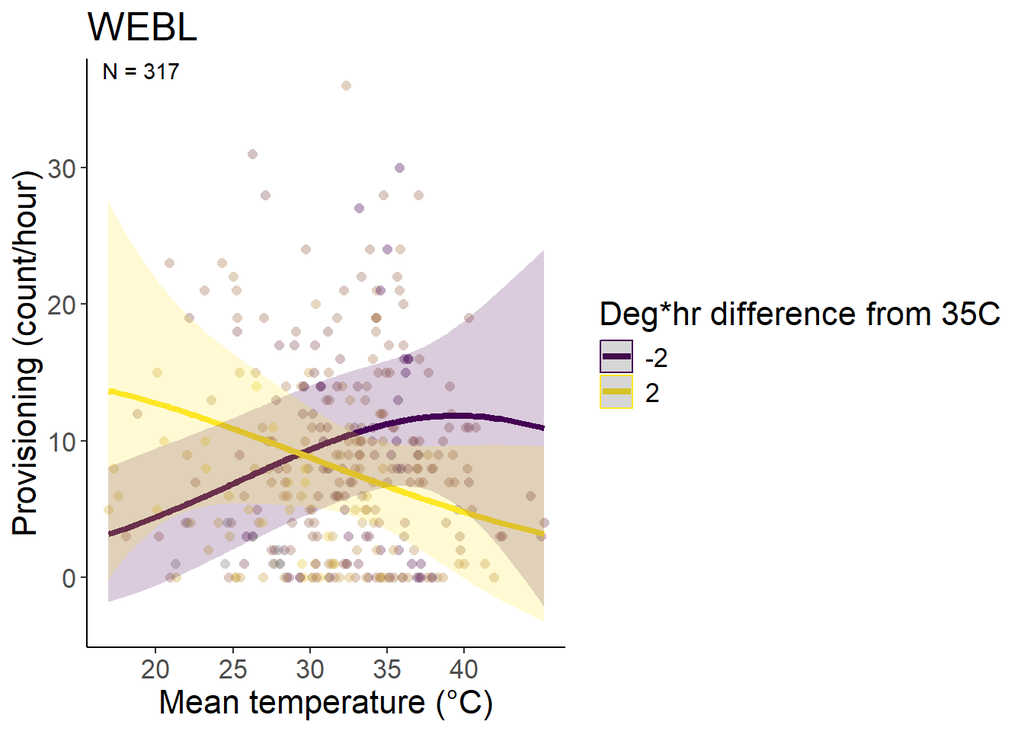

```r
data_webl_q2h1_deghrdiff35 = dplyr::filter(p,!is.na(mean_temp),
                                  # !is.na(julian_date),
                                  !is.na(mean_nestling_age),
                                  !is.na(deghours_diff_35C_priorday),
                                  !is.na(brood_size),
                                  !is.na(tod_h),
                                  !is.na(site),
                                  !is.na(attempt_id),
                                  !is.na(year_fct),
                                  species == "WEBL"# ,
                                                # tod >= hms::as.hms('11:00:00', tz = "America/Los_Angeles"),
                                                # tod_end <= hms::as.hms('17:00:00',tz = "America/Los_Angeles"),
                                                # tod_end >= hms::as.hms('11:00:00', tz = "America/Los_Angeles")
                                                ) %>%
                        mutate(across(c(tod_h,mean_temp,deghours_diff_35C_priorday,julian_date,mean_nestling_age,brood_size),
                                                    ~ scale(.x)[,1],
                                                    .names = "{.col}_scaled"))


mean_temp_webl_q2h1_deghrdiff35 <- mean(data_webl_q2h1_deghrdiff35 %>% pull(mean_temp))
sd_temp_webl_q2h1_deghrdiff35 <- sd(data_webl_q2h1_deghrdiff35 %>% pull(mean_temp))


temp_trans_webl_q2h1_deghrdiff35 <- trans_new("temp_trans_webl_q2h1_deghrdiff35",
                             transform = function(x){(x * sd_temp_webl_q2h1_deghrdiff35) + mean_temp_webl_q2h1_deghrdiff35},
                             inverse = function(x){x})

(figq2h1_deghrdiff35_webl <- predict_response(m_webl_q2h1_deghrdiff35,terms = c("mean_temp_scaled [all]","deghours_diff_35C_priorday_scaled [-2,2]"),margin = "empirical") %>%
    plot(line_size = 1.5,alpha = .2,limit_range = TRUE,show_data = TRUE,colors = "viridis") +
    # scale_color_hue(labels = c("Low","High")) +
    # aes(linetype = .data[["group"]]) +
    theme_classic() +
    # facet_wrap(~ group, ncol = 2) +
    xlab("Mean temperature (\u00b0C)") +
    ylab("Provisioning (count/hour)") +
    # scale_fill_viridis(discrete = TRUE) +
    # scale_color_viridis(discrete = TRUE) +
    theme(text = element_text(size = 16)) +
    labs(title =  "WEBL", color = "Deg*hr difference from 35C", fill = "Deg*hr difference from 35C") +
    scale_x_continuous(trans = temp_trans_webl_q2h1_deghrdiff35,
                       breaks = c((20-mean_temp_webl_q2h1_deghrdiff35)/sd_temp_webl_q2h1_deghrdiff35,
                                  (25-mean_temp_webl_q2h1_deghrdiff35)/sd_temp_webl_q2h1_deghrdiff35,
                                  (30-mean_temp_webl_q2h1_deghrdiff35)/sd_temp_webl_q2h1_deghrdiff35,
                                  (35-mean_temp_webl_q2h1_deghrdiff35)/sd_temp_webl_q2h1_deghrdiff35,
                                  (40-mean_temp_webl_q2h1_deghrdiff35)/sd_temp_webl_q2h1_deghrdiff35),
                       # breaks = c(20,30,40,50),
                       # labels = c("20","30","40","50"),
                       # limits = c((15-mean(g$meanmaxtempI,na.rm = TRUE))/sd(g$meanmaxtempI,na.rm = TRUE),
                       #            (55-mean(g$meanmaxtempI,na.rm = TRUE))/sd(g$meanmaxtempI,na.rm = TRUE))
                       # limits = c(18,5)
    ) +
    # scale_linetype_manual(values = "solid") +
    #ylim(-5,5) +
    geom_text(data = dat_text_webl_q2h1_deghrdiff35, mapping = aes(x = -Inf, y = Inf,label = label),hjust = -.2, vjust = 1.2,inherit.aes = FALSE) # +
    #theme(legend.position = "none")
)
```

```r
ggsave("../figures/provisbymaxtempxhab_WEBL_q2h1_deghrdiff35.png",plot =  figq2h1_deghrdiff35_webl, width = 10, height = 6.6)
```

### TRES

```r
m_TRES <- glmmTMB(valid_detections ~ poly(mean_temp_scaled,2) * deghours_diff_35C_priorday_scaled + poly(tod_h_scaled,2) + mean_nestling_age_scaled + brood_size_scaled + year_fct +  (1|site:attempt_id),
           family = nbinom2(),
           ziformula = ~ (1|site:attempt_id),
           data = dplyr::filter(p,!is.na(mean_temp),
                                  # !is.na(julian_date),
                                  !is.na(mean_nestling_age),
                                  !is.na(deghours_diff_35C_priorday),
                                  !is.na(brood_size),
                                  !is.na(tod_h),
                                  !is.na(site),
                                  !is.na(attempt_id),
                                  !is.na(year_fct),
                                  species == "TRES"# ,
                                                # tod >= hms::as.hms('11:00:00', tz = "America/Los_Angeles"),
                                                # tod_end <= hms::as.hms('17:00:00',tz = "America/Los_Angeles"),
                                                # tod_end >= hms::as.hms('11:00:00', tz = "America/Los_Angeles")
                                                ) %>%
                        mutate(across(c(tod_h,mean_temp,deghours_diff_35C_priorday,julian_date,mean_nestling_age,brood_size),
                                                    ~ scale(.x)[,1],
                                                    .names = "{.col}_scaled")),
           )

summary(m_TRES)
```

```
##  Family: nbinom2  ( log )
## Formula:
## valid_detections ~ poly(mean_temp_scaled, 2) * deghours_diff_35C_priorday_scaled +
##     poly(tod_h_scaled, 2) + mean_nestling_age_scaled + brood_size_scaled +
##     year_fct + (1 | site:attempt_id)
## Zero inflation:                    ~(1 | site:attempt_id)
## Data: dplyr::filter(p, !is.na(mean_temp), !is.na(mean_nestling_age),
##     !is.na(deghours_diff_35C_priorday), !is.na(brood_size), !is.na(tod_h),
##     !is.na(site), !is.na(attempt_id), !is.na(year_fct), species ==
##         "TRES") %>% mutate(across(c(tod_h, mean_temp, deghours_diff_35C_priorday,
##     julian_date, mean_nestling_age, brood_size), ~scale(.x)[,
##     1], .names = "{.col}_scaled"))
##
##      AIC      BIC   logLik deviance df.resid
##   1499.7   1554.8   -733.9   1467.7      215
##
## Random effects:
##
## Conditional model:
##  Groups          Name        Variance Std.Dev.
##  site:attempt_id (Intercept) 0.2042   0.4519
## Number of obs: 231, groups:  site:attempt_id, 23
##
## Zero-inflation model:
##  Groups          Name        Variance Std.Dev.
##  site:attempt_id (Intercept) 3.966    1.991
## Number of obs: 231, groups:  site:attempt_id, 23
##
## Dispersion parameter for nbinom2 family (): 3.51
##
## Conditional model:
##                                                               Estimate
## (Intercept)                                                   2.664194
## poly(mean_temp_scaled, 2)1                                    6.687453
## poly(mean_temp_scaled, 2)2                                   -1.253721
## deghours_diff_35C_priorday_scaled                             0.009217
## poly(tod_h_scaled, 2)1                                        1.161967
## poly(tod_h_scaled, 2)2                                        2.030518
## mean_nestling_age_scaled                                     -0.022320
## brood_size_scaled                                             0.289367
```

[output cut: 23 more lines]

```
## poly(tod_h_scaled, 2)2                                       0.112640
## mean_nestling_age_scaled                                     0.763981
## brood_size_scaled                                            0.056315 .
## year_fct2022                                                 0.947648
## year_fct2023                                                 0.213407
## poly(mean_temp_scaled, 2)1:deghours_diff_35C_priorday_scaled 0.795724
## poly(mean_temp_scaled, 2)2:deghours_diff_35C_priorday_scaled 0.027407 *
## ---
## Signif. codes:  0 '***' 0.001 '**' 0.01 '*' 0.05 '.' 0.1 ' ' 1
##
## Zero-inflation model:
##             Estimate Std. Error z value Pr(>|z|)
## (Intercept)  -2.2168     0.6002  -3.693 0.000221 ***
## ---
## Signif. codes:  0 '***' 0.001 '**' 0.01 '*' 0.05 '.' 0.1 ' ' 1
```

```r
m_TRES_q2h1_deghrdiff35 <- m_TRES

check_zeroinflation(m_TRES)
```

```
## # Check for zero-inflation
##
##    Observed zeros: 51
##   Predicted zeros: 50
##             Ratio: 0.98
```

```
## Model seems ok, ratio of observed and predicted zeros is within the
##   tolerance range (p = 0.896).
```

```r
# (t <- emtrends(m_TRES_q1h1,specs = ~ habitat, var = c("mean_temp_scaled"),max.degree = 1) %>% test() %>%
#    mutate(across(where(is.numeric), ~ round(.x, digits = 3)),
#           df = round(df),
#           p.value = if_else(p.value == 0.000,"<0.001",as.character(p.value))) %>%
#    rename(Habitat = "habitat", `Max temp trend` = "mean_temp_scaled.trend",Df = "df", `Z-ratio` = "z.ratio", P = "p.value") %>%
#    #group_by(degree) %>%
#    gt())

ss_year_TRES_provis_q2h1_deghrdiff35 <- m_TRES_q2h1_deghrdiff35$frame %>%
  group_by(year_fct) %>%
  summarize(count_ind = n(),count_attempt = n_distinct(attempt_id)) %>%
  rowwise() %>%
  mutate(count = tibble(count_ind,count_attempt)) %>%
  dplyr::select(-c(count_ind, count_attempt)) %>%
  pivot_wider(values_from = count,names_from = year_fct) %>%
  as.tibble() %>% # rename(Habitat = 'habitat') %>%
  ungroup() %>%
  mutate(`2021` = replace_na(`2021`,list(count_ind = 0,count_attempt = 0))) %>%
  mutate(Total = `2021` + `2022` + `2023`) %>%
  rowwise() %>%
  mutate(`2021` = paste0(`2021`$count_ind,", ",`2021`$count_attempt),
         `2022` = paste0(`2022`$count_ind,", ",`2022`$count_attempt),
         `2023` = paste0(`2023`$count_ind,", ",`2023`$count_attempt),
         Total = paste0(Total$count_ind,", ",Total$count_attempt)
  )

(t_ss_year_TRES_provis_q2h1_deghrdiff35 <- ss_year_TRES_provis_q2h1_deghrdiff35 %>% gt() %>%
    grand_summary_rows(fns = list(id = "Total") ~ {
      t <- str_split(.,", ",simplify = TRUE)
      t[,1] %>% as.numeric() %>% sum(na.rm = TRUE) %>% paste(t[,2] %>% as.numeric() %>% sum(na.rm = TRUE),sep = ", ")
    })
)
```

|  | 2021 | 2022 | 2023 | Total |
| --- | --- | --- | --- | --- |
|  | 64, 7 | 75, 7 | 92, 9 | 231, 23 |
| Total | 64, 7 | 75, 7 | 92, 9 | 231, 23 |

```r
t_ss_year_TRES_provis_q2h1_deghrdiff35 %>% gtsave("../figures/ss_year_TRES_provis_ch3_q2h1_deghrdiff35.html")

samp_q2h1_deghrdiff35 <- m_TRES_q2h1_deghrdiff35$frame %>% summarize(count = n())
samp_q2h1_deghrdiff35 %>% gt() %>% gtsave("../figures/ss_TRES_provis_ch3_q2h1_deghrdiff35.html")


dat_text_TRES_q2h1_deghrdiff35 <- data.frame(
  label = paste("N =",samp_q2h1_deghrdiff35$count)# ,
  #group   = factor(c("Forest","Orchard","Grassland","Row crop"))
)

## num nestboxes
m_TRES_q2h1_deghrdiff35$frame %>% pull(attempt_id) %>% unique() %>% length()
```

```
## [1] 23
```

```
## Data points may overlap. Use the `jitter` argument to add some amount of
##   random variation to the location of data points and avoid overplotting.
```

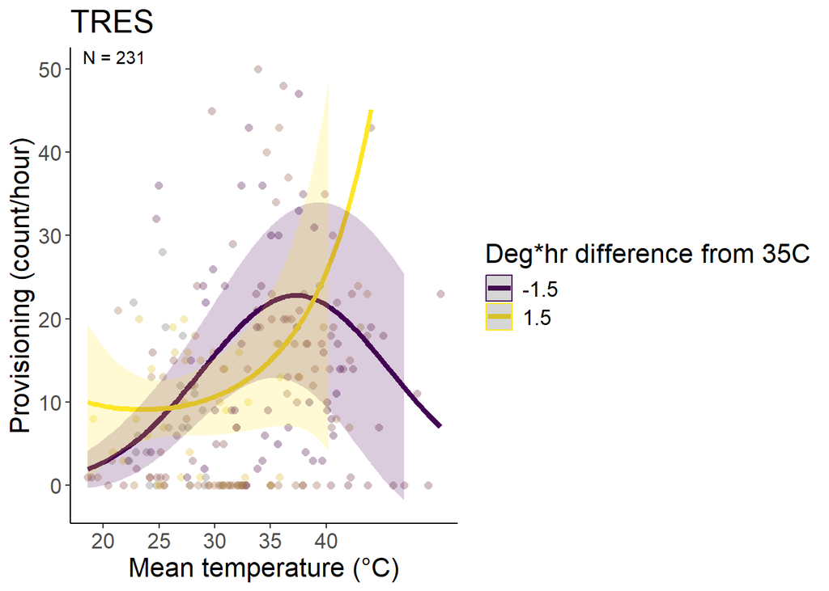

```r
data_TRES_q2h1_deghrdiff35 = dplyr::filter(p,!is.na(mean_temp),
                                  # !is.na(julian_date),
                                  !is.na(mean_nestling_age),
                                  !is.na(deghours_diff_35C_priorday),
                                  !is.na(brood_size),
                                  !is.na(tod_h),
                                  !is.na(site),
                                  !is.na(attempt_id),
                                  !is.na(year_fct),
                                  species == "TRES"# ,
                                                # tod >= hms::as.hms('11:00:00', tz = "America/Los_Angeles"),
                                                # tod_end <= hms::as.hms('17:00:00',tz = "America/Los_Angeles"),
                                                # tod_end >= hms::as.hms('11:00:00', tz = "America/Los_Angeles")
                                                ) %>%
                        mutate(across(c(tod_h,mean_temp,deghours_diff_35C_priorday,julian_date,mean_nestling_age,brood_size),
                                                    ~ scale(.x)[,1],
                                                    .names = "{.col}_scaled"))


mean_temp_TRES_q2h1_deghrdiff35 <- mean(data_TRES_q2h1_deghrdiff35 %>% pull(mean_temp))
sd_temp_TRES_q2h1_deghrdiff35 <- sd(data_TRES_q2h1_deghrdiff35 %>% pull(mean_temp))


temp_trans_TRES_q2h1_deghrdiff35 <- trans_new("temp_trans_TRES_q2h1_deghrdiff35",
                             transform = function(x){(x * sd_temp_TRES_q2h1_deghrdiff35) + mean_temp_TRES_q2h1_deghrdiff35},
                             inverse = function(x){x})

(figq2h1_deghrdiff35_TRES <- predict_response(m_TRES_q2h1_deghrdiff35,terms = c("mean_temp_scaled [all]","deghours_diff_35C_priorday_scaled [-1.5,1.5]"),margin = "empirical") %>%
    plot(line_size = 1.5,alpha = .2,limit_range = TRUE,show_data = TRUE,colors = "viridis") +
    # scale_color_hue(labels = c("Low","High")) +
    # aes(linetype = .data[["group"]]) +
    theme_classic() +
    # facet_wrap(~ group, ncol = 2) +
    xlab("Mean temperature (\u00b0C)") +
    ylab("Provisioning (count/hour)") +
    # scale_fill_viridis(discrete = TRUE) +
    # scale_color_viridis(discrete = TRUE) +
    theme(text = element_text(size = 16)) +
    labs(title =  "TRES", color = "Deg*hr difference from 35C", fill = "Deg*hr difference from 35C") +
    scale_x_continuous(trans = temp_trans_TRES_q2h1_deghrdiff35,
                       breaks = c((20-mean_temp_TRES_q2h1_deghrdiff35)/sd_temp_TRES_q2h1_deghrdiff35,
                                  (25-mean_temp_TRES_q2h1_deghrdiff35)/sd_temp_TRES_q2h1_deghrdiff35,
                                  (30-mean_temp_TRES_q2h1_deghrdiff35)/sd_temp_TRES_q2h1_deghrdiff35,
                                  (35-mean_temp_TRES_q2h1_deghrdiff35)/sd_temp_TRES_q2h1_deghrdiff35,
                                  (40-mean_temp_TRES_q2h1_deghrdiff35)/sd_temp_TRES_q2h1_deghrdiff35),
                       # breaks = c(20,30,40,50),
                       # labels = c("20","30","40","50"),
                       # limits = c((15-mean(g$meanmaxtempI,na.rm = TRUE))/sd(g$meanmaxtempI,na.rm = TRUE),
                       #            (55-mean(g$meanmaxtempI,na.rm = TRUE))/sd(g$meanmaxtempI,na.rm = TRUE))
                       # limits = c(18,5)
    ) +
    # scale_linetype_manual(values = "solid") +
    ylim(-2,50) +
    geom_text(data = dat_text_TRES_q2h1_deghrdiff35, mapping = aes(x = -Inf, y = Inf,label = label),hjust = -.2, vjust = 1.2,inherit.aes = FALSE) # +
    #theme(legend.position = "none")
)
```

```r
ggsave("../figures/provisbymaxtempxhab_TRES_q2h1_deghrdiff35.png",plot =  figq2h1_deghrdiff35_TRES, width = 10, height = 6.6)
```

## Degree hours difference from 30C

### WEBL

```r
m_WEBL <- glmmTMB(valid_detections ~ poly(mean_temp_scaled,2) * deghours_diff_30C_priorday_scaled + poly(tod_h_scaled,2) + mean_nestling_age_scaled + brood_size_scaled + year_fct +  (1|site:attempt_id),
           family = nbinom2(),
           ziformula = ~ attempt_id,
           data = dplyr::filter(p,!is.na(mean_temp),
                                  # !is.na(julian_date),
                                  !is.na(mean_nestling_age),
                                  !is.na(deghours_diff_30C_priorday),
                                  !is.na(brood_size),
                                  !is.na(tod_h),
                                  !is.na(site),
                                  !is.na(attempt_id),
                                  !is.na(year_fct),
                                  species == "WEBL"# ,
                                                # tod >= hms::as.hms('11:00:00', tz = "America/Los_Angeles"),
                                                # tod_end <= hms::as.hms('17:00:00',tz = "America/Los_Angeles"),
                                                # tod_end >= hms::as.hms('11:00:00', tz = "America/Los_Angeles")
                                                ) %>%
                        mutate(across(c(tod_h,mean_temp,deghours_diff_30C_priorday,julian_date,mean_nestling_age,brood_size),
                                                    ~ scale(.x)[,1],
                                                    .names = "{.col}_scaled")),
           )

summary(m_WEBL)
```

```
##  Family: nbinom2  ( log )
## Formula:
## valid_detections ~ poly(mean_temp_scaled, 2) * deghours_diff_30C_priorday_scaled +
##     poly(tod_h_scaled, 2) + mean_nestling_age_scaled + brood_size_scaled +
##     year_fct + (1 | site:attempt_id)
## Zero inflation:                    ~attempt_id
## Data: dplyr::filter(p, !is.na(mean_temp), !is.na(mean_nestling_age),
##     !is.na(deghours_diff_30C_priorday), !is.na(brood_size), !is.na(tod_h),
##     !is.na(site), !is.na(attempt_id), !is.na(year_fct), species ==
##         "WEBL") %>% mutate(across(c(tod_h, mean_temp, deghours_diff_30C_priorday,
##     julian_date, mean_nestling_age, brood_size), ~scale(.x)[,
##     1], .names = "{.col}_scaled"))
##
##      AIC      BIC   logLik deviance df.resid
##   1847.6   2009.3   -880.8   1761.6      274
##
## Random effects:
##
## Conditional model:
##  Groups          Name        Variance Std.Dev.
##  site:attempt_id (Intercept) 0.1949   0.4414
## Number of obs: 317, groups:  site:attempt_id, 29
##
## Dispersion parameter for nbinom2 family (): 5.53
##
## Conditional model:
##                                                              Estimate
## (Intercept)                                                   2.36306
## poly(mean_temp_scaled, 2)1                                   -0.53561
## poly(mean_temp_scaled, 2)2                                   -0.60906
## deghours_diff_30C_priorday_scaled                            -0.07338
## poly(tod_h_scaled, 2)1                                        0.10179
## poly(tod_h_scaled, 2)2                                        1.63675
## mean_nestling_age_scaled                                      0.20343
## brood_size_scaled                                             0.13503
## year_fct2022                                                 -0.36789
## year_fct2023                                                 -0.47487
## poly(mean_temp_scaled, 2)1:deghours_diff_30C_priorday_scaled -3.73275
## poly(mean_temp_scaled, 2)2:deghours_diff_30C_priorday_scaled -2.82553
##                                                              Std. Error z value
```

[output cut: 46 more lines]

```
## attempt_id2023_BRO6_1   -2.738e-01  1.542e+00  -0.178  0.85910
## attempt_id2023_MBNG14_1 -1.911e+01  1.235e+04  -0.002  0.99877
## attempt_id2023_PCC8_1   -2.242e+01  2.159e+04  -0.001  0.99917
## attempt_id2023_PCC8_2    2.738e-01  1.432e+00   0.191  0.84830
## attempt_id2023_PCC9_1   -6.574e-01  7.864e-01  -0.836  0.40314
## attempt_id2023_PICG7_1  -2.909e+00  1.557e+00  -1.868  0.06174 .
## attempt_id2023_PICO1_2  -2.286e+01  2.326e+04  -0.001  0.99922
## attempt_id2023_PICO13_1 -2.028e+00  1.008e+00  -2.012  0.04427 *
## attempt_id2023_PICO4_1  -1.911e+01  1.235e+04  -0.002  0.99877
## attempt_id2023_PICR10_1 -1.911e+01  8.741e+03  -0.002  0.99826
## attempt_id2023_RRRR3_1  -2.637e+00  9.655e-01  -2.732  0.00630 **
## attempt_id2023_RRRR8_1  -2.275e+01  2.294e+04  -0.001  0.99921
## attempt_id2023_RRRR8_2  -2.260e+01  2.240e+04  -0.001  0.99919
## ---
## Signif. codes:  0 '***' 0.001 '**' 0.01 '*' 0.05 '.' 0.1 ' ' 1
```

```r
m_webl_q2h1_deghrdiff30 <- m_WEBL

check_zeroinflation(m_WEBL)
```

```
## # Check for zero-inflation
##
##    Observed zeros: 45
##   Predicted zeros: 49
##             Ratio: 1.08
```

```
## Model seems ok, ratio of observed and predicted zeros is within the
##   tolerance range (p = 0.576).
```

```r
# (t <- emtrends(m_webl_q1h1,specs = ~ habitat, var = c("mean_temp_scaled"),max.degree = 1) %>% test() %>%
#    mutate(across(where(is.numeric), ~ round(.x, digits = 3)),
#           df = round(df),
#           p.value = if_else(p.value == 0.000,"<0.001",as.character(p.value))) %>%
#    rename(Habitat = "habitat", `Max temp trend` = "mean_temp_scaled.trend",Df = "df", `Z-ratio` = "z.ratio", P = "p.value") %>%
#    #group_by(degree) %>%
#    gt())

ss_year_webl_provis_q2h1_deghrdiff30 <- m_webl_q2h1_deghrdiff30$frame %>%
  group_by(year_fct) %>%
  summarize(count_ind = n(),count_attempt = n_distinct(attempt_id)) %>%
  rowwise() %>%
  mutate(count = tibble(count_ind,count_attempt)) %>%
  dplyr::select(-c(count_ind, count_attempt)) %>%
  pivot_wider(values_from = count,names_from = year_fct) %>%
  as.tibble() %>% # rename(Habitat = 'habitat') %>%
  ungroup() %>%
  mutate(`2021` = replace_na(`2021`,list(count_ind = 0,count_attempt = 0))) %>%
  mutate(Total = `2021` + `2022` + `2023`) %>%
  rowwise() %>%
  mutate(`2021` = paste0(`2021`$count_ind,", ",`2021`$count_attempt),
         `2022` = paste0(`2022`$count_ind,", ",`2022`$count_attempt),
         `2023` = paste0(`2023`$count_ind,", ",`2023`$count_attempt),
         Total = paste0(Total$count_ind,", ",Total$count_attempt)
  )

(t_ss_year_webl_provis_q2h1_deghrdiff30 <- ss_year_webl_provis_q2h1_deghrdiff30 %>% gt() %>%
    grand_summary_rows(fns = list(id = "Total") ~ {
      t <- str_split(.,", ",simplify = TRUE)
      t[,1] %>% as.numeric() %>% sum(na.rm = TRUE) %>% paste(t[,2] %>% as.numeric() %>% sum(na.rm = TRUE),sep = ", ")
    })
)
```

|  | 2021 | 2022 | 2023 | Total |
| --- | --- | --- | --- | --- |
|  | 21, 3 | 153, 12 | 143, 14 | 317, 29 |
| Total | 21, 3 | 153, 12 | 143, 14 | 317, 29 |

```r
t_ss_year_webl_provis_q2h1_deghrdiff30 %>% gtsave("../figures/ss_year_webl_provis_ch3_q2h1_deghrdiff30.html")

samp_q2h1_deghrdiff30 <- m_webl_q2h1_deghrdiff30$frame %>% summarize(count = n())
samp_q2h1_deghrdiff30 %>% gt() %>% gtsave("../figures/ss_webl_provis_ch3_q2h1_deghrdiff30.html")


dat_text_webl_q2h1_deghrdiff30 <- data.frame(
  label = paste("N =",samp_q2h1_deghrdiff30$count)# ,
  #group   = factor(c("Forest","Orchard","Grassland","Row crop"))
)

## num nestboxes
m_webl_q2h1_deghrdiff30$frame %>% pull(attempt_id) %>% unique() %>% length()
```

```
## [1] 29
```

```
## Data points may overlap. Use the `jitter` argument to add some amount of
##   random variation to the location of data points and avoid overplotting.
```

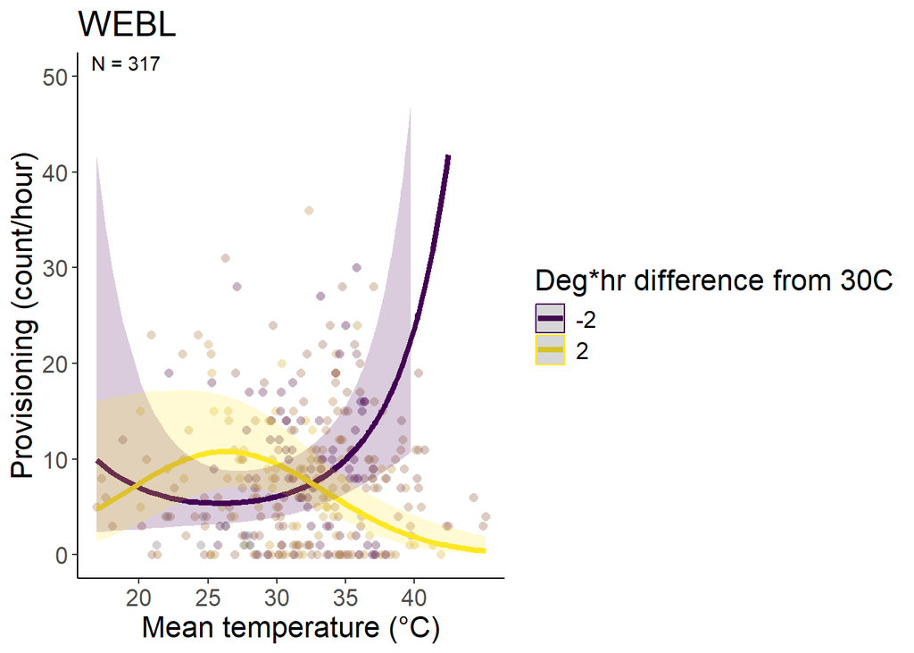

```r
data_webl_q2h1_deghrdiff30 = dplyr::filter(p,!is.na(mean_temp),
                                  # !is.na(julian_date),
                                  !is.na(mean_nestling_age),
                                  !is.na(deghours_diff_30C_priorday),
                                  !is.na(brood_size),
                                  !is.na(tod_h),
                                  !is.na(site),
                                  !is.na(attempt_id),
                                  !is.na(year_fct),
                                  species == "WEBL"# ,
                                                # tod >= hms::as.hms('11:00:00', tz = "America/Los_Angeles"),
                                                # tod_end <= hms::as.hms('17:00:00',tz = "America/Los_Angeles"),
                                                # tod_end >= hms::as.hms('11:00:00', tz = "America/Los_Angeles")
                                                ) %>%
                        mutate(across(c(tod_h,mean_temp,deghours_diff_30C_priorday,julian_date,mean_nestling_age,brood_size),
                                                    ~ scale(.x)[,1],
                                                    .names = "{.col}_scaled"))


mean_temp_webl_q2h1_deghrdiff30 <- mean(data_webl_q2h1_deghrdiff30 %>% pull(mean_temp))
sd_temp_webl_q2h1_deghrdiff30 <- sd(data_webl_q2h1_deghrdiff30 %>% pull(mean_temp))


temp_trans_webl_q2h1_deghrdiff30 <- trans_new("temp_trans_webl_q2h1_deghrdiff30",
                             transform = function(x){(x * sd_temp_webl_q2h1_deghrdiff30) + mean_temp_webl_q2h1_deghrdiff30},
                             inverse = function(x){x})

(figq2h1_deghrdiff30_webl <- predict_response(m_webl_q2h1_deghrdiff30,terms = c("mean_temp_scaled [all]","deghours_diff_30C_priorday_scaled [-2,2]"),margin = "marginalmeans") %>%
    plot(line_size = 1.5,alpha = .2,limit_range = TRUE,show_data = TRUE,colors = "viridis") +
    # scale_color_hue(labels = c("Low","High")) +
    # aes(linetype = .data[["group"]]) +
    theme_classic() +
    # facet_wrap(~ group, ncol = 2) +
    xlab("Mean temperature (\u00b0C)") +
    ylab("Provisioning (count/hour)") +
    # scale_fill_viridis(discrete = TRUE) +
    # scale_color_viridis(discrete = TRUE) +
    theme(text = element_text(size = 16)) +
    labs(title =  "WEBL", color = "Deg*hr difference from 30C", fill = "Deg*hr difference from 30C") +
    scale_x_continuous(trans = temp_trans_webl_q2h1_deghrdiff30,
                       breaks = c((20-mean_temp_webl_q2h1_deghrdiff30)/sd_temp_webl_q2h1_deghrdiff30,
                                  (25-mean_temp_webl_q2h1_deghrdiff30)/sd_temp_webl_q2h1_deghrdiff30,
                                  (30-mean_temp_webl_q2h1_deghrdiff30)/sd_temp_webl_q2h1_deghrdiff30,
                                  (35-mean_temp_webl_q2h1_deghrdiff30)/sd_temp_webl_q2h1_deghrdiff30,
                                  (40-mean_temp_webl_q2h1_deghrdiff30)/sd_temp_webl_q2h1_deghrdiff30),
                       # breaks = c(20,30,40,50),
                       # labels = c("20","30","40","50"),
                       # limits = c((15-mean(g$meanmaxtempI,na.rm = TRUE))/sd(g$meanmaxtempI,na.rm = TRUE),
                       #            (55-mean(g$meanmaxtempI,na.rm = TRUE))/sd(g$meanmaxtempI,na.rm = TRUE))
                       # limits = c(18,5)
    ) +
    # scale_linetype_manual(values = "solid") +
    ylim(0,50) +
    geom_text(data = dat_text_webl_q2h1_deghrdiff30, mapping = aes(x = -Inf, y = Inf,label = label),hjust = -.2, vjust = 1.2,inherit.aes = FALSE) # +
    #theme(legend.position = "none")
)
```

```r
ggsave("../figures/provisbymaxtempxhab_WEBL_q2h1_deghrdiff30.png",plot =  figq2h1_deghrdiff30_webl, width = 10, height = 6.6)
```

### TRES

```r
m_TRES <- glmmTMB(valid_detections ~ poly(mean_temp_scaled,2) * deghours_diff_30C_priorday_scaled + poly(tod_h_scaled,2) + mean_nestling_age_scaled + brood_size_scaled + year_fct +  (1|site:attempt_id),
           family = nbinom2(),
           ziformula = ~ (1|site:attempt_id),
           data = dplyr::filter(p,!is.na(mean_temp),
                                  # !is.na(julian_date),
                                  !is.na(mean_nestling_age),
                                  !is.na(deghours_diff_30C_priorday),
                                  !is.na(brood_size),
                                  !is.na(tod_h),
                                  !is.na(site),
                                  !is.na(attempt_id),
                                  !is.na(year_fct),
                                  species == "TRES"# ,
                                                # tod >= hms::as.hms('11:00:00', tz = "America/Los_Angeles"),
                                                # tod_end <= hms::as.hms('17:00:00',tz = "America/Los_Angeles"),
                                                # tod_end >= hms::as.hms('11:00:00', tz = "America/Los_Angeles")
                                                ) %>%
                        mutate(across(c(tod_h,mean_temp,deghours_diff_30C_priorday,julian_date,mean_nestling_age,brood_size),
                                                    ~ scale(.x)[,1],
                                                    .names = "{.col}_scaled")),
           )

summary(m_TRES)
```

```
##  Family: nbinom2  ( log )
## Formula:
## valid_detections ~ poly(mean_temp_scaled, 2) * deghours_diff_30C_priorday_scaled +
##     poly(tod_h_scaled, 2) + mean_nestling_age_scaled + brood_size_scaled +
##     year_fct + (1 | site:attempt_id)
## Zero inflation:                    ~(1 | site:attempt_id)
## Data: dplyr::filter(p, !is.na(mean_temp), !is.na(mean_nestling_age),
##     !is.na(deghours_diff_30C_priorday), !is.na(brood_size), !is.na(tod_h),
##     !is.na(site), !is.na(attempt_id), !is.na(year_fct), species ==
##         "TRES") %>% mutate(across(c(tod_h, mean_temp, deghours_diff_30C_priorday,
##     julian_date, mean_nestling_age, brood_size), ~scale(.x)[,
##     1], .names = "{.col}_scaled"))
##
##      AIC      BIC   logLik deviance df.resid
##   1499.5   1554.6   -733.8   1467.5      215
##
## Random effects:
##
## Conditional model:
##  Groups          Name        Variance Std.Dev.
##  site:attempt_id (Intercept) 0.2053   0.4531
## Number of obs: 231, groups:  site:attempt_id, 23
##
## Zero-inflation model:
##  Groups          Name        Variance Std.Dev.
##  site:attempt_id (Intercept) 4.06     2.015
## Number of obs: 231, groups:  site:attempt_id, 23
##
## Dispersion parameter for nbinom2 family (): 3.54
##
## Conditional model:
##                                                              Estimate
## (Intercept)                                                   2.64834
## poly(mean_temp_scaled, 2)1                                    5.19495
## poly(mean_temp_scaled, 2)2                                   -2.13371
## deghours_diff_30C_priorday_scaled                            -0.06075
## poly(tod_h_scaled, 2)1                                        1.15834
## poly(tod_h_scaled, 2)2                                        2.00505
## mean_nestling_age_scaled                                     -0.01028
## brood_size_scaled                                             0.31092
```

[output cut: 23 more lines]

```
## poly(tod_h_scaled, 2)2                                         0.0857 .
## mean_nestling_age_scaled                                       0.8874
## brood_size_scaled                                              0.0428 *
## year_fct2022                                                   0.7852
## year_fct2023                                                   0.2238
## poly(mean_temp_scaled, 2)1:deghours_diff_30C_priorday_scaled   0.8449
## poly(mean_temp_scaled, 2)2:deghours_diff_30C_priorday_scaled   0.0160 *
## ---
## Signif. codes:  0 '***' 0.001 '**' 0.01 '*' 0.05 '.' 0.1 ' ' 1
##
## Zero-inflation model:
##             Estimate Std. Error z value Pr(>|z|)
## (Intercept)  -2.2284     0.6046  -3.686 0.000228 ***
## ---
## Signif. codes:  0 '***' 0.001 '**' 0.01 '*' 0.05 '.' 0.1 ' ' 1
```

```r
m_TRES_q2h1_deghrdiff30 <- m_TRES

check_zeroinflation(m_TRES)
```

```
## # Check for zero-inflation
##
##    Observed zeros: 51
##   Predicted zeros: 51
##             Ratio: 0.99
```

```
## Model seems ok, ratio of observed and predicted zeros is within the
##   tolerance range (p = 0.952).
```

```r
# (t <- emtrends(m_TRES_q1h1,specs = ~ habitat, var = c("mean_temp_scaled"),max.degree = 1) %>% test() %>%
#    mutate(across(where(is.numeric), ~ round(.x, digits = 3)),
#           df = round(df),
#           p.value = if_else(p.value == 0.000,"<0.001",as.character(p.value))) %>%
#    rename(Habitat = "habitat", `Max temp trend` = "mean_temp_scaled.trend",Df = "df", `Z-ratio` = "z.ratio", P = "p.value") %>%
#    #group_by(degree) %>%
#    gt())

ss_year_TRES_provis_q2h1_deghrdiff30 <- m_TRES_q2h1_deghrdiff30$frame %>%
  group_by(year_fct) %>%
  summarize(count_ind = n(),count_attempt = n_distinct(attempt_id)) %>%
  rowwise() %>%
  mutate(count = tibble(count_ind,count_attempt)) %>%
  dplyr::select(-c(count_ind, count_attempt)) %>%
  pivot_wider(values_from = count,names_from = year_fct) %>%
  as.tibble() %>% # rename(Habitat = 'habitat') %>%
  ungroup() %>%
  mutate(`2021` = replace_na(`2021`,list(count_ind = 0,count_attempt = 0))) %>%
  mutate(Total = `2021` + `2022` + `2023`) %>%
  rowwise() %>%
  mutate(`2021` = paste0(`2021`$count_ind,", ",`2021`$count_attempt),
         `2022` = paste0(`2022`$count_ind,", ",`2022`$count_attempt),
         `2023` = paste0(`2023`$count_ind,", ",`2023`$count_attempt),
         Total = paste0(Total$count_ind,", ",Total$count_attempt)
  )

(t_ss_year_TRES_provis_q2h1_deghrdiff30 <- ss_year_TRES_provis_q2h1_deghrdiff30 %>% gt() %>%
    grand_summary_rows(fns = list(id = "Total") ~ {
      t <- str_split(.,", ",simplify = TRUE)
      t[,1] %>% as.numeric() %>% sum(na.rm = TRUE) %>% paste(t[,2] %>% as.numeric() %>% sum(na.rm = TRUE),sep = ", ")
    })
)
```

|  | 2021 | 2022 | 2023 | Total |
| --- | --- | --- | --- | --- |
|  | 64, 7 | 75, 7 | 92, 9 | 231, 23 |
| Total | 64, 7 | 75, 7 | 92, 9 | 231, 23 |

```r
t_ss_year_TRES_provis_q2h1_deghrdiff30 %>% gtsave("../figures/ss_year_TRES_provis_ch3_q2h1_deghrdiff30.html")

samp_q2h1_deghrdiff30 <- m_TRES_q2h1_deghrdiff30$frame %>% summarize(count = n())
samp_q2h1_deghrdiff30 %>% gt() %>% gtsave("../figures/ss_TRES_provis_ch3_q2h1_deghrdiff30.html")


dat_text_TRES_q2h1_deghrdiff30 <- data.frame(
  label = paste("N =",samp_q2h1_deghrdiff30$count)# ,
  #group   = factor(c("Forest","Orchard","Grassland","Row crop"))
)

## num nestboxes
m_TRES_q2h1_deghrdiff30$frame %>% pull(attempt_id) %>% unique() %>% length()
```

```
## [1] 23
```

```
## Data points may overlap. Use the `jitter` argument to add some amount of
##   random variation to the location of data points and avoid overplotting.
```

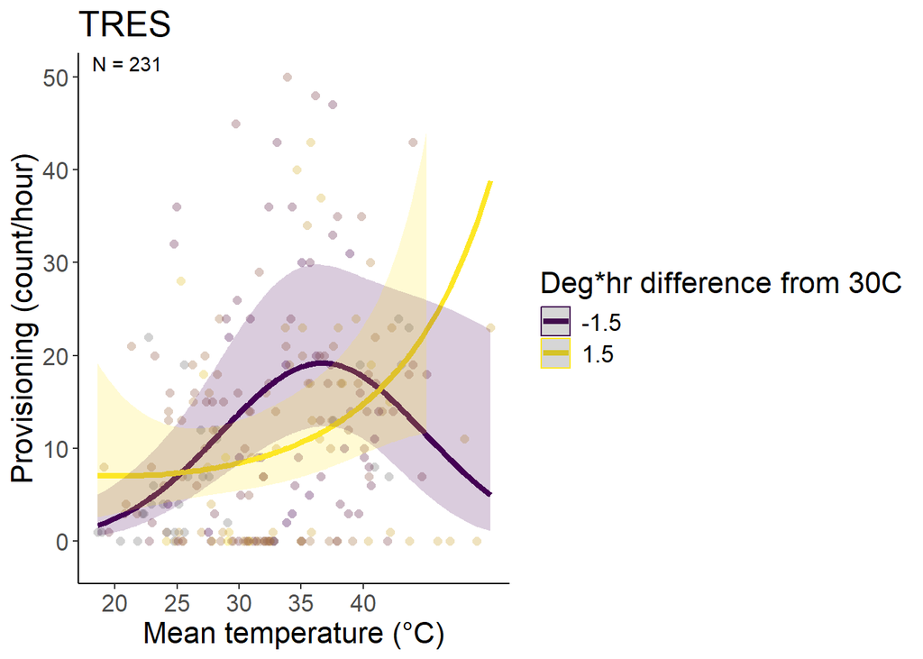

```r
data_TRES_q2h1_deghrdiff30 = dplyr::filter(p,!is.na(mean_temp),
                                  # !is.na(julian_date),
                                  !is.na(mean_nestling_age),
                                  !is.na(deghours_diff_30C_priorday),
                                  !is.na(brood_size),
                                  !is.na(tod_h),
                                  !is.na(site),
                                  !is.na(attempt_id),
                                  !is.na(year_fct),
                                  species == "TRES"# ,
                                                # tod >= hms::as.hms('11:00:00', tz = "America/Los_Angeles"),
                                                # tod_end <= hms::as.hms('17:00:00',tz = "America/Los_Angeles"),
                                                # tod_end >= hms::as.hms('11:00:00', tz = "America/Los_Angeles")
                                                ) %>%
                        mutate(across(c(tod_h,mean_temp,deghours_diff_30C_priorday,julian_date,mean_nestling_age,brood_size),
                                                    ~ scale(.x)[,1],
                                                    .names = "{.col}_scaled"))


mean_temp_TRES_q2h1_deghrdiff30 <- mean(data_TRES_q2h1_deghrdiff30 %>% pull(mean_temp))
sd_temp_TRES_q2h1_deghrdiff30 <- sd(data_TRES_q2h1_deghrdiff30 %>% pull(mean_temp))


temp_trans_TRES_q2h1_deghrdiff30 <- trans_new("temp_trans_TRES_q2h1_deghrdiff30",
                             transform = function(x){(x * sd_temp_TRES_q2h1_deghrdiff30) + mean_temp_TRES_q2h1_deghrdiff30},
                             inverse = function(x){x})

(figq2h1_deghrdiff30_TRES <- predict_response(m_TRES_q2h1_deghrdiff30,terms = c("mean_temp_scaled [all]","deghours_diff_30C_priorday_scaled [-1.5,1.5]"),margin = "marginalmeans") %>%
    plot(line_size = 1.5,alpha = .2,limit_range = TRUE,show_data = TRUE,colors = "viridis") +
    # scale_color_hue(labels = c("Low","High")) +
    # aes(linetype = .data[["group"]]) +
    theme_classic() +
    # facet_wrap(~ group, ncol = 2) +
    xlab("Mean temperature (\u00b0C)") +
    ylab("Provisioning (count/hour)") +
    # scale_fill_viridis(discrete = TRUE) +
    # scale_color_viridis(discrete = TRUE) +
    theme(text = element_text(size = 16)) +
    labs(title =  "TRES", color = "Deg*hr difference from 30C", fill = "Deg*hr difference from 30C") +
    scale_x_continuous(trans = temp_trans_TRES_q2h1_deghrdiff30,
                       breaks = c((20-mean_temp_TRES_q2h1_deghrdiff30)/sd_temp_TRES_q2h1_deghrdiff30,
                                  (25-mean_temp_TRES_q2h1_deghrdiff30)/sd_temp_TRES_q2h1_deghrdiff30,
                                  (30-mean_temp_TRES_q2h1_deghrdiff30)/sd_temp_TRES_q2h1_deghrdiff30,
                                  (35-mean_temp_TRES_q2h1_deghrdiff30)/sd_temp_TRES_q2h1_deghrdiff30,
                                  (40-mean_temp_TRES_q2h1_deghrdiff30)/sd_temp_TRES_q2h1_deghrdiff30),
                       # breaks = c(20,30,40,50),
                       # labels = c("20","30","40","50"),
                       # limits = c((15-mean(g$meanmaxtempI,na.rm = TRUE))/sd(g$meanmaxtempI,na.rm = TRUE),
                       #            (55-mean(g$meanmaxtempI,na.rm = TRUE))/sd(g$meanmaxtempI,na.rm = TRUE))
                       # limits = c(18,5)
    ) +
    # scale_linetype_manual(values = "solid") +
    ylim(-2,50) +
    geom_text(data = dat_text_TRES_q2h1_deghrdiff30, mapping = aes(x = -Inf, y = Inf,label = label),hjust = -.2, vjust = 1.2,inherit.aes = FALSE) # +
    #theme(legend.position = "none")
)
```

```r
ggsave("../figures/provisbymaxtempxhab_TRES_q2h1_deghrdiff30.png",plot =  figq2h1_deghrdiff30_TRES, width = 10, height = 6.6)
```

## Degree hours above 35C

### WEBL

```r
m_WEBL <- glmmTMB(valid_detections ~ poly(mean_temp_scaled,2) * degreehours_over_35C_priorday_scaled + poly(tod_h_scaled,2) + mean_nestling_age_scaled + brood_size_scaled + year_fct +  (1|site:attempt_id),
           family = nbinom2(),
           ziformula = ~ attempt_id,
           data = dplyr::filter(p,!is.na(mean_temp),
                                  # !is.na(julian_date),
                                  !is.na(mean_nestling_age),
                                  !is.na(degreehours_over_35C_priorday),
                                  !is.na(brood_size),
                                  !is.na(tod_h),
                                  !is.na(site),
                                  !is.na(attempt_id),
                                  !is.na(year_fct),
                                  species == "WEBL"# ,
                                                # tod >= hms::as.hms('11:00:00', tz = "America/Los_Angeles"),
                                                # tod_end <= hms::as.hms('17:00:00',tz = "America/Los_Angeles"),
                                                # tod_end >= hms::as.hms('11:00:00', tz = "America/Los_Angeles")
                                                ) %>%
                        mutate(across(c(tod_h,mean_temp,degreehours_over_35C_priorday,julian_date,mean_nestling_age,brood_size),
                                                    ~ scale(.x)[,1],
                                                    .names = "{.col}_scaled")),
           )

summary(m_WEBL)
```

```
##  Family: nbinom2  ( log )
## Formula:
## valid_detections ~ poly(mean_temp_scaled, 2) * degreehours_over_35C_priorday_scaled +
##     poly(tod_h_scaled, 2) + mean_nestling_age_scaled + brood_size_scaled +
##     year_fct + (1 | site:attempt_id)
## Zero inflation:                    ~attempt_id
## Data: dplyr::filter(p, !is.na(mean_temp), !is.na(mean_nestling_age),
##     !is.na(degreehours_over_35C_priorday), !is.na(brood_size),
##     !is.na(tod_h), !is.na(site), !is.na(attempt_id), !is.na(year_fct),
##     species == "WEBL") %>% mutate(across(c(tod_h, mean_temp,
##     degreehours_over_35C_priorday, julian_date, mean_nestling_age,
##     brood_size), ~scale(.x)[, 1], .names = "{.col}_scaled"))
##
##      AIC      BIC   logLik deviance df.resid
##   1849.1   2010.7   -881.5   1763.1      274
##
## Random effects:
##
## Conditional model:
##  Groups          Name        Variance Std.Dev.
##  site:attempt_id (Intercept) 0.1186   0.3445
## Number of obs: 317, groups:  site:attempt_id, 29
##
## Dispersion parameter for nbinom2 family (): 5.22
##
## Conditional model:
##                                                                 Estimate
## (Intercept)                                                      2.45022
## poly(mean_temp_scaled, 2)1                                       0.79336
## poly(mean_temp_scaled, 2)2                                       1.00874
## degreehours_over_35C_priorday_scaled                             0.05365
## poly(tod_h_scaled, 2)1                                           0.06710
## poly(tod_h_scaled, 2)2                                           1.27308
## mean_nestling_age_scaled                                         0.18406
## brood_size_scaled                                                0.12823
## year_fct2022                                                    -0.38915
## year_fct2023                                                    -0.38626
## poly(mean_temp_scaled, 2)1:degreehours_over_35C_priorday_scaled -1.76642
## poly(mean_temp_scaled, 2)2:degreehours_over_35C_priorday_scaled -1.55042
##                                                                 Std. Error
```

[output cut: 59 more lines]

```
## attempt_id2023_BRO6_1   -3.249e-01  1.540e+00  -0.211  0.83296
## attempt_id2023_MBNG14_1 -1.837e+01  8.328e+03  -0.002  0.99824
## attempt_id2023_PCC8_1   -2.190e+01  1.619e+04  -0.001  0.99892
## attempt_id2023_PCC8_2    2.171e-01  1.430e+00   0.152  0.87932
## attempt_id2023_PCC9_1   -7.116e-01  7.782e-01  -0.914  0.36050
## attempt_id2023_PICG7_1  -2.905e+00  1.492e+00  -1.947  0.05152 .
## attempt_id2023_PICO1_2  -2.252e+01  1.914e+04  -0.001  0.99906
## attempt_id2023_PICO13_1 -2.085e+00  1.007e+00  -2.072  0.03831 *
## attempt_id2023_PICO4_1  -1.837e+01  8.328e+03  -0.002  0.99824
## attempt_id2023_PICR10_1 -1.889e+01  7.648e+03  -0.002  0.99803
## attempt_id2023_RRRR3_1  -2.689e+00  9.603e-01  -2.800  0.00510 **
## attempt_id2023_RRRR8_1  -2.234e+01  1.826e+04  -0.001  0.99902
## attempt_id2023_RRRR8_2  -2.213e+01  1.728e+04  -0.001  0.99898
## ---
## Signif. codes:  0 '***' 0.001 '**' 0.01 '*' 0.05 '.' 0.1 ' ' 1
```

```r
m_webl_q2h1_deghrover35 <- m_WEBL

check_zeroinflation(m_WEBL)
```

```
## # Check for zero-inflation
##
##    Observed zeros: 45
##   Predicted zeros: 48
##             Ratio: 1.06
```

```
## Model seems ok, ratio of observed and predicted zeros is within the
##   tolerance range (p = 0.584).
```

```r
# (t <- emtrends(m_webl_q1h1,specs = ~ habitat, var = c("mean_temp_scaled"),max.degree = 1) %>% test() %>%
#    mutate(across(where(is.numeric), ~ round(.x, digits = 3)),
#           df = round(df),
#           p.value = if_else(p.value == 0.000,"<0.001",as.character(p.value))) %>%
#    rename(Habitat = "habitat", `Max temp trend` = "mean_temp_scaled.trend",Df = "df", `Z-ratio` = "z.ratio", P = "p.value") %>%
#    #group_by(degree) %>%
#    gt())

ss_year_webl_provis_q2h1_deghrover35 <- m_webl_q2h1_deghrover35$frame %>%
  group_by(year_fct) %>%
  summarize(count_ind = n(),count_attempt = n_distinct(attempt_id)) %>%
  rowwise() %>%
  mutate(count = tibble(count_ind,count_attempt)) %>%
  dplyr::select(-c(count_ind, count_attempt)) %>%
  pivot_wider(values_from = count,names_from = year_fct) %>%
  as.tibble() %>% # rename(Habitat = 'habitat') %>%
  ungroup() %>%
  mutate(`2021` = replace_na(`2021`,list(count_ind = 0,count_attempt = 0))) %>%
  mutate(Total = `2021` + `2022` + `2023`) %>%
  rowwise() %>%
  mutate(`2021` = paste0(`2021`$count_ind,", ",`2021`$count_attempt),
         `2022` = paste0(`2022`$count_ind,", ",`2022`$count_attempt),
         `2023` = paste0(`2023`$count_ind,", ",`2023`$count_attempt),
         Total = paste0(Total$count_ind,", ",Total$count_attempt)
  )

(t_ss_year_webl_provis_q2h1_deghrover35 <- ss_year_webl_provis_q2h1_deghrover35 %>% gt() %>%
    grand_summary_rows(fns = list(id = "Total") ~ {
      t <- str_split(.,", ",simplify = TRUE)
      t[,1] %>% as.numeric() %>% sum(na.rm = TRUE) %>% paste(t[,2] %>% as.numeric() %>% sum(na.rm = TRUE),sep = ", ")
    })
)
```

|  | 2021 | 2022 | 2023 | Total |
| --- | --- | --- | --- | --- |
|  | 21, 3 | 153, 12 | 143, 14 | 317, 29 |
| Total | 21, 3 | 153, 12 | 143, 14 | 317, 29 |

```r
t_ss_year_webl_provis_q2h1_deghrover35 %>% gtsave("../figures/ss_year_webl_provis_ch3_q2h1_deghrover35.html")

samp_q2h1_deghrover35 <- m_webl_q2h1_deghrover35$frame %>% summarize(count = n())
samp_q2h1_deghrover35 %>% gt() %>% gtsave("../figures/ss_webl_provis_ch3_q2h1_deghrover35.html")


dat_text_webl_q2h1_deghrover35 <- data.frame(
  label = paste("N =",samp_q2h1_deghrover35$count)# ,
  #group   = factor(c("Forest","Orchard","Grassland","Row crop"))
)

## num nestboxes
m_webl_q2h1_deghrover35$frame %>% pull(attempt_id) %>% unique() %>% length()
```

```
## [1] 29
```

```
## Data points may overlap. Use the `jitter` argument to add some amount of
##   random variation to the location of data points and avoid overplotting.
```

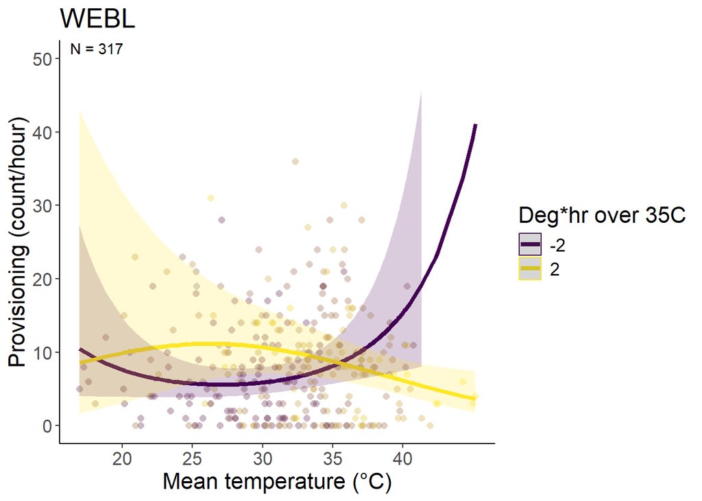

```r
data_webl_q2h1_deghrover35 = dplyr::filter(p,!is.na(mean_temp),
                                  # !is.na(julian_date),
                                  !is.na(mean_nestling_age),
                                  !is.na(degreehours_over_35C_priorday),
                                  !is.na(brood_size),
                                  !is.na(tod_h),
                                  !is.na(site),
                                  !is.na(attempt_id),
                                  !is.na(year_fct),
                                  species == "WEBL"# ,
                                                # tod >= hms::as.hms('11:00:00', tz = "America/Los_Angeles"),
                                                # tod_end <= hms::as.hms('17:00:00',tz = "America/Los_Angeles"),
                                                # tod_end >= hms::as.hms('11:00:00', tz = "America/Los_Angeles")
                                                ) %>%
                        mutate(across(c(tod_h,mean_temp,degreehours_over_35C_priorday,julian_date,mean_nestling_age,brood_size),
                                                    ~ scale(.x)[,1],
                                                    .names = "{.col}_scaled"))


mean_temp_webl_q2h1_deghrover35 <- mean(data_webl_q2h1_deghrover35 %>% pull(mean_temp))
sd_temp_webl_q2h1_deghrover35 <- sd(data_webl_q2h1_deghrover35 %>% pull(mean_temp))


temp_trans_webl_q2h1_deghrover35 <- trans_new("temp_trans_webl_q2h1_deghrover35",
                             transform = function(x){(x * sd_temp_webl_q2h1_deghrover35) + mean_temp_webl_q2h1_deghrover35},
                             inverse = function(x){x})

(figq2h1_deghrover35_webl <- predict_response(m_webl_q2h1_deghrover35,terms = c("mean_temp_scaled [all]","degreehours_over_35C_priorday_scaled [-2,2]"),margin = "marginalmeans") %>%
    plot(line_size = 1.5,alpha = .2,limit_range = TRUE,show_data = TRUE,colors = "viridis") +
    # scale_color_hue(labels = c("Low","High")) +
    # aes(linetype = .data[["group"]]) +
    theme_classic() +
    # facet_wrap(~ group, ncol = 2) +
    xlab("Mean temperature (\u00b0C)") +
    ylab("Provisioning (count/hour)") +
    # scale_fill_viridis(discrete = TRUE) +
    # scale_color_viridis(discrete = TRUE) +
    theme(text = element_text(size = 16)) +
    labs(title =  "WEBL", color = "Deg*hr over 35C", fill = "Deg*hr over 35C") +
    scale_x_continuous(trans = temp_trans_webl_q2h1_deghrover35,
                       breaks = c((20-mean_temp_webl_q2h1_deghrover35)/sd_temp_webl_q2h1_deghrover35,
                                  (25-mean_temp_webl_q2h1_deghrover35)/sd_temp_webl_q2h1_deghrover35,
                                  (30-mean_temp_webl_q2h1_deghrover35)/sd_temp_webl_q2h1_deghrover35,
                                  (35-mean_temp_webl_q2h1_deghrover35)/sd_temp_webl_q2h1_deghrover35,
                                  (40-mean_temp_webl_q2h1_deghrover35)/sd_temp_webl_q2h1_deghrover35),
                       # breaks = c(20,30,40,50),
                       # labels = c("20","30","40","50"),
                       # limits = c((15-mean(g$meanmaxtempI,na.rm = TRUE))/sd(g$meanmaxtempI,na.rm = TRUE),
                       #            (55-mean(g$meanmaxtempI,na.rm = TRUE))/sd(g$meanmaxtempI,na.rm = TRUE))
                       # limits = c(18,5)
    ) +
    # scale_linetype_manual(values = "solid") +
    ylim(0,50) +
    geom_text(data = dat_text_webl_q2h1_deghrover35, mapping = aes(x = -Inf, y = Inf,label = label),hjust = -.2, vjust = 1.2,inherit.aes = FALSE) # +
    #theme(legend.position = "none")
)
```

```r
ggsave("../figures/provisbymaxtempxhab_WEBL_q2h1_deghrover35.png",plot =  figq2h1_deghrover35_webl, width = 10, height = 6.6)
```

### TRES

```r
m_TRES <- glmmTMB(valid_detections ~ poly(mean_temp_scaled,2) * degreehours_over_35C_priorday_scaled + poly(tod_h_scaled,2) + mean_nestling_age_scaled + brood_size_scaled + year_fct +  (1|site:attempt_id),
           family = nbinom2(),
           ziformula = ~ (1|site:attempt_id),
           data = dplyr::filter(p,!is.na(mean_temp),
                                  # !is.na(julian_date),
                                  !is.na(mean_nestling_age),
                                  !is.na(degreehours_over_35C_priorday),
                                  !is.na(brood_size),
                                  !is.na(tod_h),
                                  !is.na(site),
                                  !is.na(attempt_id),
                                  !is.na(year_fct),
                                  species == "TRES"# ,
                                                # tod >= hms::as.hms('11:00:00', tz = "America/Los_Angeles"),
                                                # tod_end <= hms::as.hms('17:00:00',tz = "America/Los_Angeles"),
                                                # tod_end >= hms::as.hms('11:00:00', tz = "America/Los_Angeles")
                                                ) %>%
                        mutate(across(c(tod_h,mean_temp,degreehours_over_35C_priorday,julian_date,mean_nestling_age,brood_size),
                                                    ~ scale(.x)[,1],
                                                    .names = "{.col}_scaled")),
           )

m_TRES_noint <- glmmTMB(valid_detections ~ poly(mean_temp_scaled,2) + degreehours_over_35C_priorday_scaled + poly(tod_h_scaled,2) + mean_nestling_age_scaled + brood_size_scaled + year_fct +  (1|site:attempt_id),
           family = nbinom2(),
           ziformula = ~ (1|site:attempt_id),
           data = dplyr::filter(p,!is.na(mean_temp),
                                  # !is.na(julian_date),
                                  !is.na(mean_nestling_age),
                                  !is.na(degreehours_over_35C_priorday),
                                  !is.na(brood_size),
                                  !is.na(tod_h),
                                  !is.na(site),
                                  !is.na(attempt_id),
                                  !is.na(year_fct),
                                  species == "TRES"# ,
                                                # tod >= hms::as.hms('11:00:00', tz = "America/Los_Angeles"),
                                                # tod_end <= hms::as.hms('17:00:00',tz = "America/Los_Angeles"),
                                                # tod_end >= hms::as.hms('11:00:00', tz = "America/Los_Angeles")
                                                ) %>%
                        mutate(across(c(tod_h,mean_temp,degreehours_over_35C_priorday,julian_date,mean_nestling_age,brood_size),
                                                    ~ scale(.x)[,1],
                                                    .names = "{.col}_scaled")),
           )



summary(m_TRES)
```

```
##  Family: nbinom2  ( log )
## Formula:
## valid_detections ~ poly(mean_temp_scaled, 2) * degreehours_over_35C_priorday_scaled +
##     poly(tod_h_scaled, 2) + mean_nestling_age_scaled + brood_size_scaled +
##     year_fct + (1 | site:attempt_id)
## Zero inflation:                    ~(1 | site:attempt_id)
## Data: dplyr::filter(p, !is.na(mean_temp), !is.na(mean_nestling_age),
##     !is.na(degreehours_over_35C_priorday), !is.na(brood_size),
##     !is.na(tod_h), !is.na(site), !is.na(attempt_id), !is.na(year_fct),
##     species == "TRES") %>% mutate(across(c(tod_h, mean_temp,
##     degreehours_over_35C_priorday, julian_date, mean_nestling_age,
##     brood_size), ~scale(.x)[, 1], .names = "{.col}_scaled"))
##
##      AIC      BIC   logLik deviance df.resid
##   1504.6   1559.7   -736.3   1472.6      215
##
## Random effects:
##
## Conditional model:
##  Groups          Name        Variance Std.Dev.
##  site:attempt_id (Intercept) 0.2159   0.4647
## Number of obs: 231, groups:  site:attempt_id, 23
##
## Zero-inflation model:
##  Groups          Name        Variance Std.Dev.
##  site:attempt_id (Intercept) 3.903    1.976
## Number of obs: 231, groups:  site:attempt_id, 23
##
## Dispersion parameter for nbinom2 family (): 3.42
##
## Conditional model:
##                                                                 Estimate
## (Intercept)                                                      2.56706
## poly(mean_temp_scaled, 2)1                                       5.66028
## poly(mean_temp_scaled, 2)2                                      -1.87572
## degreehours_over_35C_priorday_scaled                             0.09532
## poly(tod_h_scaled, 2)1                                           0.95460
## poly(tod_h_scaled, 2)2                                           2.32204
## mean_nestling_age_scaled                                        -0.03108
## brood_size_scaled                                                0.30188
```

[output cut: 36 more lines]

```
## poly(tod_h_scaled, 2)2                                           0.07841 .
## mean_nestling_age_scaled                                         0.68179
## brood_size_scaled                                                0.04872 *
## year_fct2022                                                     0.84539
## year_fct2023                                                     0.37345
## poly(mean_temp_scaled, 2)1:degreehours_over_35C_priorday_scaled  0.65059
## poly(mean_temp_scaled, 2)2:degreehours_over_35C_priorday_scaled  0.62326
## ---
## Signif. codes:  0 '***' 0.001 '**' 0.01 '*' 0.05 '.' 0.1 ' ' 1
##
## Zero-inflation model:
##             Estimate Std. Error z value Pr(>|z|)
## (Intercept)  -2.2182     0.6073  -3.652  0.00026 ***
## ---
## Signif. codes:  0 '***' 0.001 '**' 0.01 '*' 0.05 '.' 0.1 ' ' 1
```

```r
summary(m_TRES_noint)
```

```
##  Family: nbinom2  ( log )
## Formula:
## valid_detections ~ poly(mean_temp_scaled, 2) + degreehours_over_35C_priorday_scaled +
##     poly(tod_h_scaled, 2) + mean_nestling_age_scaled + brood_size_scaled +
##     year_fct + (1 | site:attempt_id)
## Zero inflation:                    ~(1 | site:attempt_id)
## Data: dplyr::filter(p, !is.na(mean_temp), !is.na(mean_nestling_age),
##     !is.na(degreehours_over_35C_priorday), !is.na(brood_size),
##     !is.na(tod_h), !is.na(site), !is.na(attempt_id), !is.na(year_fct),
##     species == "TRES") %>% mutate(across(c(tod_h, mean_temp,
##     degreehours_over_35C_priorday, julian_date, mean_nestling_age,
##     brood_size), ~scale(.x)[, 1], .names = "{.col}_scaled"))
##
##      AIC      BIC   logLik deviance df.resid
##   1501.0   1549.2   -736.5   1473.0      217
##
## Random effects:
##
## Conditional model:
##  Groups          Name        Variance Std.Dev.
##  site:attempt_id (Intercept) 0.2095   0.4577
## Number of obs: 231, groups:  site:attempt_id, 23
##
## Zero-inflation model:
##  Groups          Name        Variance Std.Dev.
##  site:attempt_id (Intercept) 3.942    1.985
## Number of obs: 231, groups:  site:attempt_id, 23
##
## Dispersion parameter for nbinom2 family ():  3.4
##
## Conditional model:
##                                      Estimate Std. Error z value Pr(>|z|)
## (Intercept)                           2.59894    0.23760  10.938  < 2e-16 ***
## poly(mean_temp_scaled, 2)1            5.21594    1.85638   2.810  0.00496 **
## poly(mean_temp_scaled, 2)2           -1.65805    0.92966  -1.783  0.07450 .
## degreehours_over_35C_priorday_scaled  0.09849    0.11671   0.844  0.39871
## poly(tod_h_scaled, 2)1                0.96093    0.80376   1.196  0.23187
## poly(tod_h_scaled, 2)2                2.04716    1.22246   1.675  0.09401 .
## mean_nestling_age_scaled             -0.02736    0.07510  -0.364  0.71556
## brood_size_scaled                     0.30094    0.15145   1.987  0.04691 *
## year_fct2022                          0.08624    0.37598   0.229  0.81857
## year_fct2023                         -0.27907    0.30790  -0.906  0.36473
## ---
## Signif. codes:  0 '***' 0.001 '**' 0.01 '*' 0.05 '.' 0.1 ' ' 1
##
## Zero-inflation model:
##             Estimate Std. Error z value Pr(>|z|)
## (Intercept)  -2.2250     0.6105  -3.645 0.000268 ***
## ---
## Signif. codes:  0 '***' 0.001 '**' 0.01 '*' 0.05 '.' 0.1 ' ' 1
```

```r
m_TRES_q2h1_deghrover35 <- m_TRES_noint

check_zeroinflation(m_TRES)
```

```
## # Check for zero-inflation
##
##    Observed zeros: 51
##   Predicted zeros: 49
##             Ratio: 0.95
```

```
## Model seems ok, ratio of observed and predicted zeros is within the
##   tolerance range (p = 0.824).
```

```r
# (t <- emtrends(m_TRES_q1h1,specs = ~ habitat, var = c("mean_temp_scaled"),max.degree = 1) %>% test() %>%
#    mutate(across(where(is.numeric), ~ round(.x, digits = 3)),
#           df = round(df),
#           p.value = if_else(p.value == 0.000,"<0.001",as.character(p.value))) %>%
#    rename(Habitat = "habitat", `Max temp trend` = "mean_temp_scaled.trend",Df = "df", `Z-ratio` = "z.ratio", P = "p.value") %>%
#    #group_by(degree) %>%
#    gt())

ss_year_TRES_provis_q2h1_deghrover35 <- m_TRES_q2h1_deghrover35$frame %>%
  group_by(year_fct) %>%
  summarize(count_ind = n(),count_attempt = n_distinct(attempt_id)) %>%
  rowwise() %>%
  mutate(count = tibble(count_ind,count_attempt)) %>%
  dplyr::select(-c(count_ind, count_attempt)) %>%
  pivot_wider(values_from = count,names_from = year_fct) %>%
  as.tibble() %>% # rename(Habitat = 'habitat') %>%
  ungroup() %>%
  mutate(`2021` = replace_na(`2021`,list(count_ind = 0,count_attempt = 0))) %>%
  mutate(Total = `2021` + `2022` + `2023`) %>%
  rowwise() %>%
  mutate(`2021` = paste0(`2021`$count_ind,", ",`2021`$count_attempt),
         `2022` = paste0(`2022`$count_ind,", ",`2022`$count_attempt),
         `2023` = paste0(`2023`$count_ind,", ",`2023`$count_attempt),
         Total = paste0(Total$count_ind,", ",Total$count_attempt)
  )

(t_ss_year_TRES_provis_q2h1_deghrover35 <- ss_year_TRES_provis_q2h1_deghrover35 %>% gt() %>%
    grand_summary_rows(fns = list(id = "Total") ~ {
      t <- str_split(.,", ",simplify = TRUE)
      t[,1] %>% as.numeric() %>% sum(na.rm = TRUE) %>% paste(t[,2] %>% as.numeric() %>% sum(na.rm = TRUE),sep = ", ")
    })
)
```

|  | 2021 | 2022 | 2023 | Total |
| --- | --- | --- | --- | --- |
|  | 64, 7 | 75, 7 | 92, 9 | 231, 23 |
| Total | 64, 7 | 75, 7 | 92, 9 | 231, 23 |

```r
t_ss_year_TRES_provis_q2h1_deghrover35 %>% gtsave("../figures/ss_year_TRES_provis_ch3_q2h1_deghrover35.html")

samp_q2h1_deghrover35 <- m_TRES_q2h1_deghrover35$frame %>% summarize(count = n())
samp_q2h1_deghrover35 %>% gt() %>% gtsave("../figures/ss_TRES_provis_ch3_q2h1_deghrover35.html")


dat_text_TRES_q2h1_deghrover35 <- data.frame(
  label = paste("N =",samp_q2h1_deghrover35$count)# ,
  #group   = factor(c("Forest","Orchard","Grassland","Row crop"))
)

## num nestboxes
m_TRES_q2h1_deghrover35$frame %>% pull(attempt_id) %>% unique() %>% length()
```

```
## [1] 23
```

```
## Data points may overlap. Use the `jitter` argument to add some amount of
##   random variation to the location of data points and avoid overplotting.
```

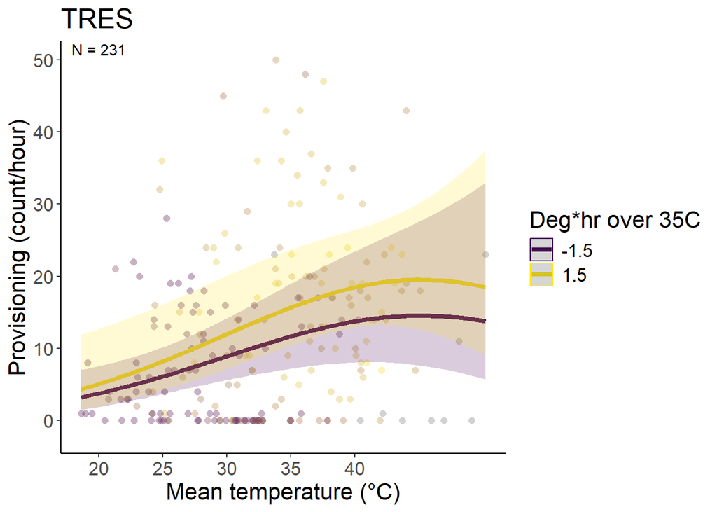

```r
data_TRES_q2h1_deghrover35 = dplyr::filter(p,!is.na(mean_temp),
                                  # !is.na(julian_date),
                                  !is.na(mean_nestling_age),
                                  !is.na(degreehours_over_35C_priorday),
                                  !is.na(brood_size),
                                  !is.na(tod_h),
                                  !is.na(site),
                                  !is.na(attempt_id),
                                  !is.na(year_fct),
                                  species == "TRES"# ,
                                                # tod >= hms::as.hms('11:00:00', tz = "America/Los_Angeles"),
                                                # tod_end <= hms::as.hms('17:00:00',tz = "America/Los_Angeles"),
                                                # tod_end >= hms::as.hms('11:00:00', tz = "America/Los_Angeles")
                                                ) %>%
                        mutate(across(c(tod_h,mean_temp,degreehours_over_35C_priorday,julian_date,mean_nestling_age,brood_size),
                                                    ~ scale(.x)[,1],
                                                    .names = "{.col}_scaled"))


mean_temp_TRES_q2h1_deghrover35 <- mean(data_TRES_q2h1_deghrover35 %>% pull(mean_temp))
sd_temp_TRES_q2h1_deghrover35 <- sd(data_TRES_q2h1_deghrover35 %>% pull(mean_temp))


temp_trans_TRES_q2h1_deghrover35 <- trans_new("temp_trans_TRES_q2h1_deghrover35",
                             transform = function(x){(x * sd_temp_TRES_q2h1_deghrover35) + mean_temp_TRES_q2h1_deghrover35},
                             inverse = function(x){x})

(figq2h1_deghrover35_TRES <- predict_response(m_TRES_q2h1_deghrover35,terms = c("mean_temp_scaled [all]","degreehours_over_35C_priorday_scaled [-1.5,1.5]"),margin = "marginalmeans") %>%
    plot(line_size = 1.5,alpha = .2,limit_range = TRUE,show_data = TRUE,colors = "viridis") +
    # scale_color_hue(labels = c("Low","High")) +
    # aes(linetype = .data[["group"]]) +
    theme_classic() +
    # facet_wrap(~ group, ncol = 2) +
    xlab("Mean temperature (\u00b0C)") +
    ylab("Provisioning (count/hour)") +
    # scale_fill_viridis(discrete = TRUE) +
    # scale_color_viridis(discrete = TRUE) +
    theme(text = element_text(size = 16)) +
    labs(title =  "TRES", color = "Deg*hr over 35C", fill = "Deg*hr over 35C") +
    scale_x_continuous(trans = temp_trans_TRES_q2h1_deghrover35,
                       breaks = c((20-mean_temp_TRES_q2h1_deghrover35)/sd_temp_TRES_q2h1_deghrover35,
                                  (25-mean_temp_TRES_q2h1_deghrover35)/sd_temp_TRES_q2h1_deghrover35,
                                  (30-mean_temp_TRES_q2h1_deghrover35)/sd_temp_TRES_q2h1_deghrover35,
                                  (35-mean_temp_TRES_q2h1_deghrover35)/sd_temp_TRES_q2h1_deghrover35,
                                  (40-mean_temp_TRES_q2h1_deghrover35)/sd_temp_TRES_q2h1_deghrover35),
                       # breaks = c(20,30,40,50),
                       # labels = c("20","30","40","50"),
                       # limits = c((15-mean(g$meanmaxtempI,na.rm = TRUE))/sd(g$meanmaxtempI,na.rm = TRUE),
                       #            (55-mean(g$meanmaxtempI,na.rm = TRUE))/sd(g$meanmaxtempI,na.rm = TRUE))
                       # limits = c(18,5)
    ) +
    # scale_linetype_manual(values = "solid") +
    ylim(-2,50) +
    geom_text(data = dat_text_TRES_q2h1_deghrover35, mapping = aes(x = -Inf, y = Inf,label = label),hjust = -.2, vjust = 1.2,inherit.aes = FALSE) # +
    #theme(legend.position = "none")
)
```

```r
ggsave("../figures/provisbymaxtempxhab_TRES_q2h1_deghrover35.png",plot =  figq2h1_deghrover35_TRES, width = 10, height = 6.6)
```

## Degree hours above 30C

### WEBL

```r
m_WEBL <- glmmTMB(valid_detections ~ poly(mean_temp_scaled,2) * degreehours_over_30C_priorday_scaled + poly(tod_h_scaled,2) + mean_nestling_age_scaled + brood_size_scaled + year_fct +  (1|site:attempt_id),
           family = nbinom2(),
           ziformula = ~ attempt_id,
           data = dplyr::filter(p,!is.na(mean_temp),
                                  # !is.na(julian_date),
                                  !is.na(mean_nestling_age),
                                  !is.na(degreehours_over_30C_priorday),
                                  !is.na(brood_size),
                                  !is.na(tod_h),
                                  !is.na(site),
                                  !is.na(attempt_id),
                                  !is.na(year_fct),
                                  species == "WEBL"# ,
                                                # tod >= hms::as.hms('11:00:00', tz = "America/Los_Angeles"),
                                                # tod_end <= hms::as.hms('17:00:00',tz = "America/Los_Angeles"),
                                                # tod_end >= hms::as.hms('11:00:00', tz = "America/Los_Angeles")
                                                ) %>%
                        mutate(across(c(tod_h,mean_temp,degreehours_over_30C_priorday,julian_date,mean_nestling_age,brood_size),
                                                    ~ scale(.x)[,1],
                                                    .names = "{.col}_scaled")),
           )

summary(m_WEBL)
```

```
##  Family: nbinom2  ( log )
## Formula:
## valid_detections ~ poly(mean_temp_scaled, 2) * degreehours_over_30C_priorday_scaled +
##     poly(tod_h_scaled, 2) + mean_nestling_age_scaled + brood_size_scaled +
##     year_fct + (1 | site:attempt_id)
## Zero inflation:                    ~attempt_id
## Data: dplyr::filter(p, !is.na(mean_temp), !is.na(mean_nestling_age),
##     !is.na(degreehours_over_30C_priorday), !is.na(brood_size),
##     !is.na(tod_h), !is.na(site), !is.na(attempt_id), !is.na(year_fct),
##     species == "WEBL") %>% mutate(across(c(tod_h, mean_temp,
##     degreehours_over_30C_priorday, julian_date, mean_nestling_age,
##     brood_size), ~scale(.x)[, 1], .names = "{.col}_scaled"))
##
##      AIC      BIC   logLik deviance df.resid
##   1853.2   2014.9   -883.6   1767.2      274
##
## Random effects:
##
## Conditional model:
##  Groups          Name        Variance Std.Dev.
##  site:attempt_id (Intercept) 0.1095   0.3309
## Number of obs: 317, groups:  site:attempt_id, 29
##
## Dispersion parameter for nbinom2 family (): 4.94
##
## Conditional model:
##                                                                 Estimate
## (Intercept)                                                      2.44679
## poly(mean_temp_scaled, 2)1                                       0.15868
## poly(mean_temp_scaled, 2)2                                       0.09846
## degreehours_over_30C_priorday_scaled                             0.14075
## poly(tod_h_scaled, 2)1                                           0.04934
## poly(tod_h_scaled, 2)2                                           1.12911
## mean_nestling_age_scaled                                         0.19117
## brood_size_scaled                                                0.12927
## year_fct2022                                                    -0.42526
## year_fct2023                                                    -0.38329
## poly(mean_temp_scaled, 2)1:degreehours_over_30C_priorday_scaled -0.63750
## poly(mean_temp_scaled, 2)2:degreehours_over_30C_priorday_scaled -1.54315
##                                                                 Std. Error
```

[output cut: 59 more lines]

```
## attempt_id2023_BRO6_1   -3.202e-01  1.541e+00  -0.208  0.83536
## attempt_id2023_MBNG14_1 -1.915e+01  1.231e+04  -0.002  0.99876
## attempt_id2023_PCC8_1   -2.113e+01  1.109e+04  -0.002  0.99848
## attempt_id2023_PCC8_2    2.586e-01  1.413e+00   0.183  0.85482
## attempt_id2023_PCC9_1   -7.422e-01  7.879e-01  -0.942  0.34615
## attempt_id2023_PICG7_1  -2.893e+00  1.484e+00  -1.949  0.05130 .
## attempt_id2023_PICO1_2  -2.161e+01  1.217e+04  -0.002  0.99858
## attempt_id2023_PICO13_1 -2.085e+00  1.010e+00  -2.064  0.03900 *
## attempt_id2023_PICO4_1  -1.915e+01  1.231e+04  -0.002  0.99876
## attempt_id2023_PICR10_1 -1.878e+01  7.265e+03  -0.003  0.99794
## attempt_id2023_RRRR3_1  -2.688e+00  9.631e-01  -2.791  0.00525 **
## attempt_id2023_RRRR8_1  -2.147e+01  1.190e+04  -0.002  0.99856
## attempt_id2023_RRRR8_2  -2.132e+01  1.154e+04  -0.002  0.99853
## ---
## Signif. codes:  0 '***' 0.001 '**' 0.01 '*' 0.05 '.' 0.1 ' ' 1
```

```r
m_webl_q2h1_deghrover30 <- m_WEBL

check_zeroinflation(m_WEBL)
```

```
## # Check for zero-inflation
##
##    Observed zeros: 45
##   Predicted zeros: 47
##             Ratio: 1.05
```

```
## Model seems ok, ratio of observed and predicted zeros is within the
##   tolerance range (p = 0.752).
```

```r
# (t <- emtrends(m_webl_q1h1,specs = ~ habitat, var = c("mean_temp_scaled"),max.degree = 1) %>% test() %>%
#    mutate(across(where(is.numeric), ~ round(.x, digits = 3)),
#           df = round(df),
#           p.value = if_else(p.value == 0.000,"<0.001",as.character(p.value))) %>%
#    rename(Habitat = "habitat", `Max temp trend` = "mean_temp_scaled.trend",Df = "df", `Z-ratio` = "z.ratio", P = "p.value") %>%
#    #group_by(degree) %>%
#    gt())

ss_year_webl_provis_q2h1_deghrover30 <- m_webl_q2h1_deghrover30$frame %>%
  group_by(year_fct) %>%
  summarize(count_ind = n(),count_attempt = n_distinct(attempt_id)) %>%
  rowwise() %>%
  mutate(count = tibble(count_ind,count_attempt)) %>%
  dplyr::select(-c(count_ind, count_attempt)) %>%
  pivot_wider(values_from = count,names_from = year_fct) %>%
  as.tibble() %>% # rename(Habitat = 'habitat') %>%
  ungroup() %>%
  mutate(`2021` = replace_na(`2021`,list(count_ind = 0,count_attempt = 0))) %>%
  mutate(Total = `2021` + `2022` + `2023`) %>%
  rowwise() %>%
  mutate(`2021` = paste0(`2021`$count_ind,", ",`2021`$count_attempt),
         `2022` = paste0(`2022`$count_ind,", ",`2022`$count_attempt),
         `2023` = paste0(`2023`$count_ind,", ",`2023`$count_attempt),
         Total = paste0(Total$count_ind,", ",Total$count_attempt)
  )

(t_ss_year_webl_provis_q2h1_deghrover30 <- ss_year_webl_provis_q2h1_deghrover30 %>% gt() %>%
    grand_summary_rows(fns = list(id = "Total") ~ {
      t <- str_split(.,", ",simplify = TRUE)
      t[,1] %>% as.numeric() %>% sum(na.rm = TRUE) %>% paste(t[,2] %>% as.numeric() %>% sum(na.rm = TRUE),sep = ", ")
    })
)
```

|  | 2021 | 2022 | 2023 | Total |
| --- | --- | --- | --- | --- |
|  | 21, 3 | 153, 12 | 143, 14 | 317, 29 |
| Total | 21, 3 | 153, 12 | 143, 14 | 317, 29 |

```r
t_ss_year_webl_provis_q2h1_deghrover30 %>% gtsave("../figures/ss_year_webl_provis_ch3_q2h1_deghrover30.html")

samp_q2h1_deghrover30 <- m_webl_q2h1_deghrover30$frame %>% summarize(count = n())
samp_q2h1_deghrover30 %>% gt() %>% gtsave("../figures/ss_webl_provis_ch3_q2h1_deghrover30.html")


dat_text_webl_q2h1_deghrover30 <- data.frame(
  label = paste("N =",samp_q2h1_deghrover30$count)# ,
  #group   = factor(c("Forest","Orchard","Grassland","Row crop"))
)

## num nestboxes
m_webl_q2h1_deghrover30$frame %>% pull(attempt_id) %>% unique() %>% length()
```

```
## [1] 29
```

```
## Data points may overlap. Use the `jitter` argument to add some amount of
##   random variation to the location of data points and avoid overplotting.
```

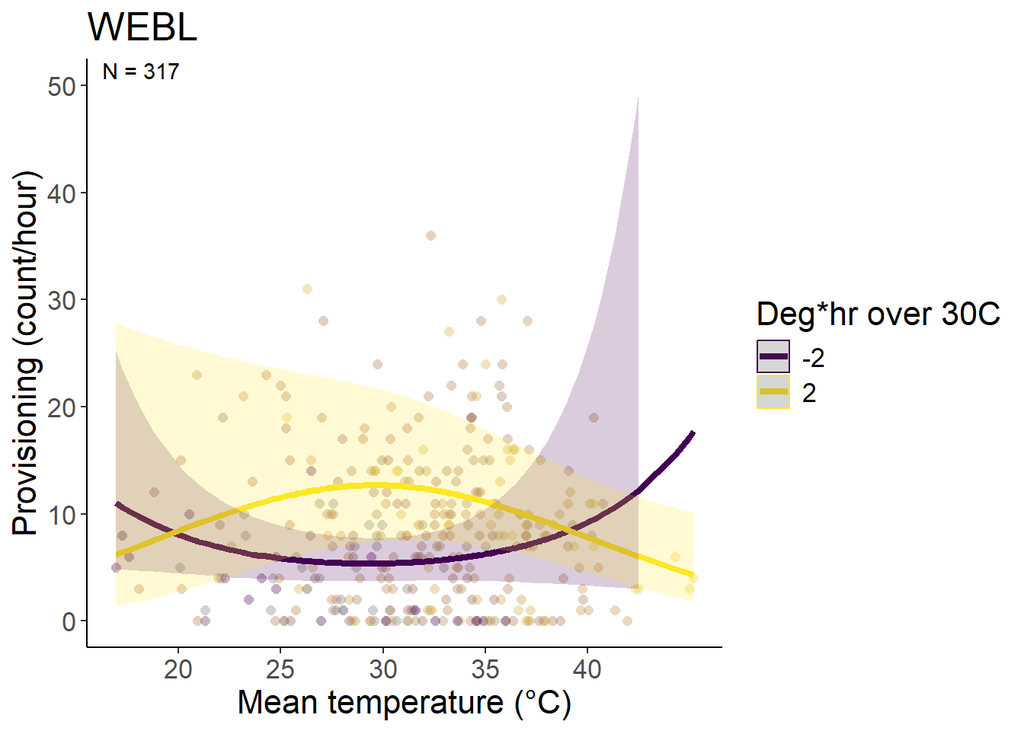

```r
data_webl_q2h1_deghrover30 = dplyr::filter(p,!is.na(mean_temp),
                                  # !is.na(julian_date),
                                  !is.na(mean_nestling_age),
                                  !is.na(degreehours_over_30C_priorday),
                                  !is.na(brood_size),
                                  !is.na(tod_h),
                                  !is.na(site),
                                  !is.na(attempt_id),
                                  !is.na(year_fct),
                                  species == "WEBL"# ,
                                                # tod >= hms::as.hms('11:00:00', tz = "America/Los_Angeles"),
                                                # tod_end <= hms::as.hms('17:00:00',tz = "America/Los_Angeles"),
                                                # tod_end >= hms::as.hms('11:00:00', tz = "America/Los_Angeles")
                                                ) %>%
                        mutate(across(c(tod_h,mean_temp,degreehours_over_30C_priorday,julian_date,mean_nestling_age,brood_size),
                                                    ~ scale(.x)[,1],
                                                    .names = "{.col}_scaled"))


mean_temp_webl_q2h1_deghrover30 <- mean(data_webl_q2h1_deghrover30 %>% pull(mean_temp))
sd_temp_webl_q2h1_deghrover30 <- sd(data_webl_q2h1_deghrover30 %>% pull(mean_temp))


temp_trans_webl_q2h1_deghrover30 <- trans_new("temp_trans_webl_q2h1_deghrover30",
                             transform = function(x){(x * sd_temp_webl_q2h1_deghrover30) + mean_temp_webl_q2h1_deghrover30},
                             inverse = function(x){x})

(figq2h1_deghrover30_webl <- predict_response(m_webl_q2h1_deghrover30,terms = c("mean_temp_scaled [all]","degreehours_over_30C_priorday_scaled [-2,2]"),margin = "marginalmeans") %>%
    plot(line_size = 1.5,alpha = .2,limit_range = TRUE,show_data = TRUE,colors = "viridis") +
    # scale_color_hue(labels = c("Low","High")) +
    # aes(linetype = .data[["group"]]) +
    theme_classic() +
    # facet_wrap(~ group, ncol = 2) +
    xlab("Mean temperature (\u00b0C)") +
    ylab("Provisioning (count/hour)") +
    # scale_fill_viridis(discrete = TRUE) +
    # scale_color_viridis(discrete = TRUE) +
    theme(text = element_text(size = 16)) +
    labs(title =  "WEBL", color = "Deg*hr over 30C", fill = "Deg*hr over 30C") +
    scale_x_continuous(trans = temp_trans_webl_q2h1_deghrover30,
                       breaks = c((20-mean_temp_webl_q2h1_deghrover30)/sd_temp_webl_q2h1_deghrover30,
                                  (25-mean_temp_webl_q2h1_deghrover30)/sd_temp_webl_q2h1_deghrover30,
                                  (30-mean_temp_webl_q2h1_deghrover30)/sd_temp_webl_q2h1_deghrover30,
                                  (35-mean_temp_webl_q2h1_deghrover30)/sd_temp_webl_q2h1_deghrover30,
                                  (40-mean_temp_webl_q2h1_deghrover30)/sd_temp_webl_q2h1_deghrover30),
                       # breaks = c(20,30,40,50),
                       # labels = c("20","30","40","50"),
                       # limits = c((15-mean(g$meanmaxtempI,na.rm = TRUE))/sd(g$meanmaxtempI,na.rm = TRUE),
                       #            (55-mean(g$meanmaxtempI,na.rm = TRUE))/sd(g$meanmaxtempI,na.rm = TRUE))
                       # limits = c(18,5)
    ) +
    # scale_linetype_manual(values = "solid") +
    ylim(0,50) +
    geom_text(data = dat_text_webl_q2h1_deghrover30, mapping = aes(x = -Inf, y = Inf,label = label),hjust = -.2, vjust = 1.2,inherit.aes = FALSE) # +
    #theme(legend.position = "none")
)
```

```r
ggsave("../figures/provisbymaxtempxhab_WEBL_q2h1_deghrover30.png",plot =  figq2h1_deghrover30_webl, width = 10, height = 6.6)
```

### TRES

```r
m_TRES <- glmmTMB(valid_detections ~ poly(mean_temp_scaled,2) * degreehours_over_30C_priorday_scaled + poly(tod_h_scaled,2) + mean_nestling_age_scaled + brood_size_scaled + year_fct +  (1|site:attempt_id),
           family = nbinom2(),
           ziformula = ~ (1|site:attempt_id),
           data = dplyr::filter(p,!is.na(mean_temp),
                                  # !is.na(julian_date),
                                  !is.na(mean_nestling_age),
                                  !is.na(degreehours_over_30C_priorday),
                                  !is.na(brood_size),
                                  !is.na(tod_h),
                                  !is.na(site),
                                  !is.na(attempt_id),
                                  !is.na(year_fct),
                                  species == "TRES"# ,
                                                # tod >= hms::as.hms('11:00:00', tz = "America/Los_Angeles"),
                                                # tod_end <= hms::as.hms('17:00:00',tz = "America/Los_Angeles"),
                                                # tod_end >= hms::as.hms('11:00:00', tz = "America/Los_Angeles")
                                                ) %>%
                        mutate(across(c(tod_h,mean_temp,degreehours_over_30C_priorday,julian_date,mean_nestling_age,brood_size),
                                                    ~ scale(.x)[,1],
                                                    .names = "{.col}_scaled")),
           )

m_TRES_noint <- glmmTMB(valid_detections ~ poly(mean_temp_scaled,2) + degreehours_over_30C_priorday_scaled + poly(tod_h_scaled,2) + mean_nestling_age_scaled + brood_size_scaled + year_fct +  (1|site:attempt_id),
           family = nbinom2(),
           ziformula = ~ (1|site:attempt_id),
           data = dplyr::filter(p,!is.na(mean_temp),
                                  # !is.na(julian_date),
                                  !is.na(mean_nestling_age),
                                  !is.na(degreehours_over_30C_priorday),
                                  !is.na(brood_size),
                                  !is.na(tod_h),
                                  !is.na(site),
                                  !is.na(attempt_id),
                                  !is.na(year_fct),
                                  species == "TRES"# ,
                                                # tod >= hms::as.hms('11:00:00', tz = "America/Los_Angeles"),
                                                # tod_end <= hms::as.hms('17:00:00',tz = "America/Los_Angeles"),
                                                # tod_end >= hms::as.hms('11:00:00', tz = "America/Los_Angeles")
                                                ) %>%
                        mutate(across(c(tod_h,mean_temp,degreehours_over_30C_priorday,julian_date,mean_nestling_age,brood_size),
                                                    ~ scale(.x)[,1],
                                                    .names = "{.col}_scaled")),
           )



summary(m_TRES)
```

```
##  Family: nbinom2  ( log )
## Formula:
## valid_detections ~ poly(mean_temp_scaled, 2) * degreehours_over_30C_priorday_scaled +
##     poly(tod_h_scaled, 2) + mean_nestling_age_scaled + brood_size_scaled +
##     year_fct + (1 | site:attempt_id)
## Zero inflation:                    ~(1 | site:attempt_id)
## Data: dplyr::filter(p, !is.na(mean_temp), !is.na(mean_nestling_age),
##     !is.na(degreehours_over_30C_priorday), !is.na(brood_size),
##     !is.na(tod_h), !is.na(site), !is.na(attempt_id), !is.na(year_fct),
##     species == "TRES") %>% mutate(across(c(tod_h, mean_temp,
##     degreehours_over_30C_priorday, julian_date, mean_nestling_age,
##     brood_size), ~scale(.x)[, 1], .names = "{.col}_scaled"))
##
##      AIC      BIC   logLik deviance df.resid
##   1502.2   1557.2   -735.1   1470.2      215
##
## Random effects:
##
## Conditional model:
##  Groups          Name        Variance Std.Dev.
##  site:attempt_id (Intercept) 0.2096   0.4578
## Number of obs: 231, groups:  site:attempt_id, 23
##
## Zero-inflation model:
##  Groups          Name        Variance Std.Dev.
##  site:attempt_id (Intercept) 4.108    2.027
## Number of obs: 231, groups:  site:attempt_id, 23
##
## Dispersion parameter for nbinom2 family (): 3.41
##
## Conditional model:
##                                                                   Estimate
## (Intercept)                                                      2.5985073
## poly(mean_temp_scaled, 2)1                                       8.0106163
## poly(mean_temp_scaled, 2)2                                      -2.5174066
## degreehours_over_30C_priorday_scaled                            -0.1263108
## poly(tod_h_scaled, 2)1                                           0.9728772
## poly(tod_h_scaled, 2)2                                           3.4504834
## mean_nestling_age_scaled                                         0.0004365
## brood_size_scaled                                                0.2767965
```

[output cut: 36 more lines]

```
## poly(tod_h_scaled, 2)2                                          0.011792 *
## mean_nestling_age_scaled                                        0.995261
## brood_size_scaled                                               0.068625 .
## year_fct2022                                                    0.840336
## year_fct2023                                                    0.276807
## poly(mean_temp_scaled, 2)1:degreehours_over_30C_priorday_scaled 0.471585
## poly(mean_temp_scaled, 2)2:degreehours_over_30C_priorday_scaled 0.432923
## ---
## Signif. codes:  0 '***' 0.001 '**' 0.01 '*' 0.05 '.' 0.1 ' ' 1
##
## Zero-inflation model:
##             Estimate Std. Error z value Pr(>|z|)
## (Intercept)  -2.2590     0.6241   -3.62 0.000295 ***
## ---
## Signif. codes:  0 '***' 0.001 '**' 0.01 '*' 0.05 '.' 0.1 ' ' 1
```

```r
summary(m_TRES_noint)
```

```
##  Family: nbinom2  ( log )
## Formula:
## valid_detections ~ poly(mean_temp_scaled, 2) + degreehours_over_30C_priorday_scaled +
##     poly(tod_h_scaled, 2) + mean_nestling_age_scaled + brood_size_scaled +
##     year_fct + (1 | site:attempt_id)
## Zero inflation:                    ~(1 | site:attempt_id)
## Data: dplyr::filter(p, !is.na(mean_temp), !is.na(mean_nestling_age),
##     !is.na(degreehours_over_30C_priorday), !is.na(brood_size),
##     !is.na(tod_h), !is.na(site), !is.na(attempt_id), !is.na(year_fct),
##     species == "TRES") %>% mutate(across(c(tod_h, mean_temp,
##     degreehours_over_30C_priorday, julian_date, mean_nestling_age,
##     brood_size), ~scale(.x)[, 1], .names = "{.col}_scaled"))
##
##      AIC      BIC   logLik deviance df.resid
##   1499.8   1548.0   -735.9   1471.8      217
##
## Random effects:
##
## Conditional model:
##  Groups          Name        Variance Std.Dev.
##  site:attempt_id (Intercept) 0.2099   0.4581
## Number of obs: 231, groups:  site:attempt_id, 23
##
## Zero-inflation model:
##  Groups          Name        Variance Std.Dev.
##  site:attempt_id (Intercept) 4.147    2.036
## Number of obs: 231, groups:  site:attempt_id, 23
##
## Dispersion parameter for nbinom2 family (): 3.38
##
## Conditional model:
##                                       Estimate Std. Error z value Pr(>|z|)
## (Intercept)                           2.656677   0.236248  11.245  < 2e-16 ***
## poly(mean_temp_scaled, 2)1            7.760009   2.120886   3.659 0.000253 ***
## poly(mean_temp_scaled, 2)2           -2.117290   0.943047  -2.245 0.024758 *
## degreehours_over_30C_priorday_scaled -0.172829   0.124819  -1.385 0.166164
## poly(tod_h_scaled, 2)1                0.898238   0.805621   1.115 0.264866
## poly(tod_h_scaled, 2)2                3.333900   1.346859   2.475 0.013312 *
## mean_nestling_age_scaled              0.002665   0.073031   0.036 0.970887
## brood_size_scaled                     0.282293   0.152130   1.856 0.063510 .
## year_fct2022                          0.108033   0.375906   0.287 0.773811
## year_fct2023                         -0.358700   0.304344  -1.179 0.238557
## ---
## Signif. codes:  0 '***' 0.001 '**' 0.01 '*' 0.05 '.' 0.1 ' ' 1
##
## Zero-inflation model:
##             Estimate Std. Error z value Pr(>|z|)
## (Intercept)  -2.2699     0.6321  -3.591 0.000329 ***
## ---
## Signif. codes:  0 '***' 0.001 '**' 0.01 '*' 0.05 '.' 0.1 ' ' 1
```

```r
m_TRES_q2h1_deghrover30 <- m_TRES_noint

check_zeroinflation(m_TRES)
```

```
## # Check for zero-inflation
##
##    Observed zeros: 51
##   Predicted zeros: 49
##             Ratio: 0.97
```

```
## Model seems ok, ratio of observed and predicted zeros is within the
##   tolerance range (p = 0.880).
```

```r
# (t <- emtrends(m_TRES_q1h1,specs = ~ habitat, var = c("mean_temp_scaled"),max.degree = 1) %>% test() %>%
#    mutate(across(where(is.numeric), ~ round(.x, digits = 3)),
#           df = round(df),
#           p.value = if_else(p.value == 0.000,"<0.001",as.character(p.value))) %>%
#    rename(Habitat = "habitat", `Max temp trend` = "mean_temp_scaled.trend",Df = "df", `Z-ratio` = "z.ratio", P = "p.value") %>%
#    #group_by(degree) %>%
#    gt())

ss_year_TRES_provis_q2h1_deghrover30 <- m_TRES_q2h1_deghrover30$frame %>%
  group_by(year_fct) %>%
  summarize(count_ind = n(),count_attempt = n_distinct(attempt_id)) %>%
  rowwise() %>%
  mutate(count = tibble(count_ind,count_attempt)) %>%
  dplyr::select(-c(count_ind, count_attempt)) %>%
  pivot_wider(values_from = count,names_from = year_fct) %>%
  as.tibble() %>% # rename(Habitat = 'habitat') %>%
  ungroup() %>%
  mutate(`2021` = replace_na(`2021`,list(count_ind = 0,count_attempt = 0))) %>%
  mutate(Total = `2021` + `2022` + `2023`) %>%
  rowwise() %>%
  mutate(`2021` = paste0(`2021`$count_ind,", ",`2021`$count_attempt),
         `2022` = paste0(`2022`$count_ind,", ",`2022`$count_attempt),
         `2023` = paste0(`2023`$count_ind,", ",`2023`$count_attempt),
         Total = paste0(Total$count_ind,", ",Total$count_attempt)
  )

(t_ss_year_TRES_provis_q2h1_deghrover30 <- ss_year_TRES_provis_q2h1_deghrover30 %>% gt() %>%
    grand_summary_rows(fns = list(id = "Total") ~ {
      t <- str_split(.,", ",simplify = TRUE)
      t[,1] %>% as.numeric() %>% sum(na.rm = TRUE) %>% paste(t[,2] %>% as.numeric() %>% sum(na.rm = TRUE),sep = ", ")
    })
)
```

|  | 2021 | 2022 | 2023 | Total |
| --- | --- | --- | --- | --- |
|  | 64, 7 | 75, 7 | 92, 9 | 231, 23 |
| Total | 64, 7 | 75, 7 | 92, 9 | 231, 23 |

```r
t_ss_year_TRES_provis_q2h1_deghrover30 %>% gtsave("../figures/ss_year_TRES_provis_ch3_q2h1_deghrover30.html")

samp_q2h1_deghrover30 <- m_TRES_q2h1_deghrover30$frame %>% summarize(count = n())
samp_q2h1_deghrover30 %>% gt() %>% gtsave("../figures/ss_TRES_provis_ch3_q2h1_deghrover30.html")


dat_text_TRES_q2h1_deghrover30 <- data.frame(
  label = paste("N =",samp_q2h1_deghrover30$count)# ,
  #group   = factor(c("Forest","Orchard","Grassland","Row crop"))
)

## num nestboxes
m_TRES_q2h1_deghrover30$frame %>% pull(attempt_id) %>% unique() %>% length()
```

```
## [1] 23
```

```
## Data points may overlap. Use the `jitter` argument to add some amount of
##   random variation to the location of data points and avoid overplotting.
```

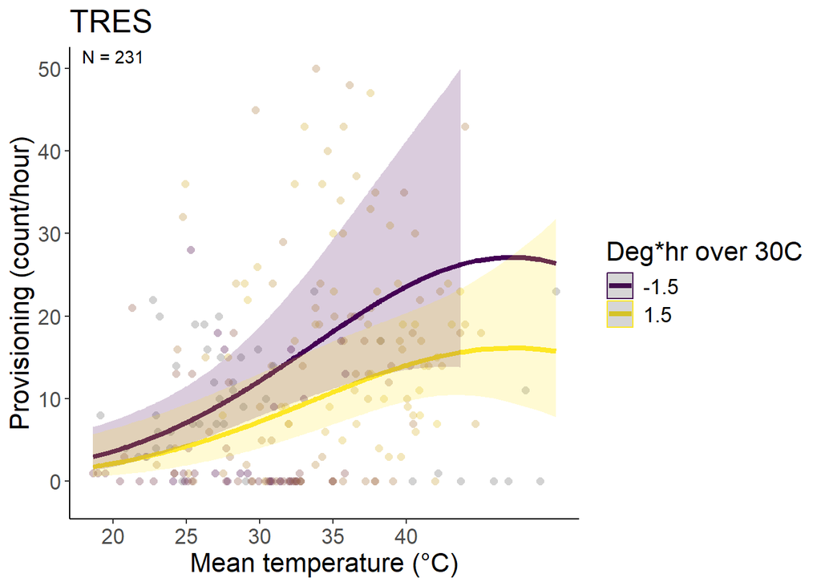

```r
data_TRES_q2h1_deghrover30 = dplyr::filter(p,!is.na(mean_temp),
                                  # !is.na(julian_date),
                                  !is.na(mean_nestling_age),
                                  !is.na(degreehours_over_30C_priorday),
                                  !is.na(brood_size),
                                  !is.na(tod_h),
                                  !is.na(site),
                                  !is.na(attempt_id),
                                  !is.na(year_fct),
                                  species == "TRES"# ,
                                                # tod >= hms::as.hms('11:00:00', tz = "America/Los_Angeles"),
                                                # tod_end <= hms::as.hms('17:00:00',tz = "America/Los_Angeles"),
                                                # tod_end >= hms::as.hms('11:00:00', tz = "America/Los_Angeles")
                                                ) %>%
                        mutate(across(c(tod_h,mean_temp,degreehours_over_30C_priorday,julian_date,mean_nestling_age,brood_size),
                                                    ~ scale(.x)[,1],
                                                    .names = "{.col}_scaled"))


mean_temp_TRES_q2h1_deghrover30 <- mean(data_TRES_q2h1_deghrover30 %>% pull(mean_temp))
sd_temp_TRES_q2h1_deghrover30 <- sd(data_TRES_q2h1_deghrover30 %>% pull(mean_temp))


temp_trans_TRES_q2h1_deghrover30 <- trans_new("temp_trans_TRES_q2h1_deghrover30",
                             transform = function(x){(x * sd_temp_TRES_q2h1_deghrover30) + mean_temp_TRES_q2h1_deghrover30},
                             inverse = function(x){x})

(figq2h1_deghrover30_TRES <- predict_response(m_TRES_q2h1_deghrover30,terms = c("mean_temp_scaled [all]","degreehours_over_30C_priorday_scaled [-1.5,1.5]"),margin = "marginalmeans") %>%
    plot(line_size = 1.5,alpha = .2,limit_range = TRUE,show_data = TRUE,colors = "viridis") +
    # scale_color_hue(labels = c("Low","High")) +
    # aes(linetype = .data[["group"]]) +
    theme_classic() +
    # facet_wrap(~ group, ncol = 2) +
    xlab("Mean temperature (\u00b0C)") +
    ylab("Provisioning (count/hour)") +
    # scale_fill_viridis(discrete = TRUE) +
    # scale_color_viridis(discrete = TRUE) +
    theme(text = element_text(size = 16)) +
    labs(title =  "TRES", color = "Deg*hr over 30C", fill = "Deg*hr over 30C") +
    scale_x_continuous(trans = temp_trans_TRES_q2h1_deghrover30,
                       breaks = c((20-mean_temp_TRES_q2h1_deghrover30)/sd_temp_TRES_q2h1_deghrover30,
                                  (25-mean_temp_TRES_q2h1_deghrover30)/sd_temp_TRES_q2h1_deghrover30,
                                  (30-mean_temp_TRES_q2h1_deghrover30)/sd_temp_TRES_q2h1_deghrover30,
                                  (35-mean_temp_TRES_q2h1_deghrover30)/sd_temp_TRES_q2h1_deghrover30,
                                  (40-mean_temp_TRES_q2h1_deghrover30)/sd_temp_TRES_q2h1_deghrover30),
                       # breaks = c(20,30,40,50),
                       # labels = c("20","30","40","50"),
                       # limits = c((15-mean(g$meanmaxtempI,na.rm = TRUE))/sd(g$meanmaxtempI,na.rm = TRUE),
                       #            (55-mean(g$meanmaxtempI,na.rm = TRUE))/sd(g$meanmaxtempI,na.rm = TRUE))
                       # limits = c(18,5)
    ) +
    # scale_linetype_manual(values = "solid") +
    ylim(-2,50) +
    geom_text(data = dat_text_TRES_q2h1_deghrover30, mapping = aes(x = -Inf, y = Inf,label = label),hjust = -.2, vjust = 1.2,inherit.aes = FALSE) # +
    #theme(legend.position = "none")
)
```

```r
ggsave("../figures/provisbymaxtempxhab_TRES_q2h1_deghrover30.png",plot =  figq2h1_deghrover30_TRES, width = 10, height = 6.6)
```

## Max temp prior day

### WEBL

```r
m_WEBL <- glmmTMB(valid_detections ~ poly(mean_temp_scaled,2) * maxt_prior_scaled + poly(tod_h_scaled,2) + mean_nestling_age_scaled + brood_size_scaled + year_fct +  (1|site:attempt_id),
           family = nbinom2(),
           ziformula = ~ attempt_id,
           data = dplyr::filter(p,!is.na(mean_temp),
                                  # !is.na(julian_date),
                                  !is.na(mean_nestling_age),
                                  !is.na(maxt_prior),
                                  !is.na(brood_size),
                                  !is.na(tod_h),
                                  !is.na(site),
                                  !is.na(attempt_id),
                                  !is.na(year_fct),
                                  species == "WEBL"# ,
                                                # tod >= hms::as.hms('11:00:00', tz = "America/Los_Angeles"),
                                                # tod_end <= hms::as.hms('17:00:00',tz = "America/Los_Angeles"),
                                                # tod_end >= hms::as.hms('11:00:00', tz = "America/Los_Angeles")
                                                ) %>%
                        mutate(across(c(tod_h,mean_temp,maxt_prior,julian_date,mean_nestling_age,brood_size),
                                                    ~ scale(.x)[,1],
                                                    .names = "{.col}_scaled")),
           )

summary(m_WEBL)
```

```
##  Family: nbinom2  ( log )
## Formula:
## valid_detections ~ poly(mean_temp_scaled, 2) * maxt_prior_scaled +
##     poly(tod_h_scaled, 2) + mean_nestling_age_scaled + brood_size_scaled +
##     year_fct + (1 | site:attempt_id)
## Zero inflation:                    ~attempt_id
## Data: dplyr::filter(p, !is.na(mean_temp), !is.na(mean_nestling_age),
##     !is.na(maxt_prior), !is.na(brood_size), !is.na(tod_h), !is.na(site),
##     !is.na(attempt_id), !is.na(year_fct), species == "WEBL") %>%
##     mutate(across(c(tod_h, mean_temp, maxt_prior, julian_date,
##         mean_nestling_age, brood_size), ~scale(.x)[, 1], .names = "{.col}_scaled"))
##
##      AIC      BIC   logLik deviance df.resid
##   1843.2   2004.9   -878.6   1757.2      274
##
## Random effects:
##
## Conditional model:
##  Groups          Name        Variance Std.Dev.
##  site:attempt_id (Intercept) 0.09845  0.3138
## Number of obs: 317, groups:  site:attempt_id, 29
##
## Dispersion parameter for nbinom2 family (): 5.32
##
## Conditional model:
##                                              Estimate Std. Error z value
## (Intercept)                                   2.41713    0.27252   8.869
## poly(mean_temp_scaled, 2)1                    1.02685    1.46735   0.700
## poly(mean_temp_scaled, 2)2                    1.51899    0.91207   1.665
## maxt_prior_scaled                             0.07921    0.07880   1.005
## poly(tod_h_scaled, 2)1                        0.04979    0.66252   0.075
## poly(tod_h_scaled, 2)2                        0.99135    1.10884   0.894
## mean_nestling_age_scaled                      0.16766    0.04498   3.727
## brood_size_scaled                             0.12173    0.08456   1.440
## year_fct2022                                 -0.34656    0.30467  -1.137
## year_fct2023                                 -0.27767    0.30149  -0.921
## poly(mean_temp_scaled, 2)1:maxt_prior_scaled -2.85203    0.94373  -3.022
## poly(mean_temp_scaled, 2)2:maxt_prior_scaled -1.73182    0.63396  -2.732
##                                              Pr(>|z|)
## (Intercept)                                   < 2e-16 ***
```

[output cut: 32 more lines]

```
## attempt_id2023_BRO6_1   -3.263e-01  1.542e+00  -0.212  0.83241
## attempt_id2023_MBNG14_1 -1.964e+01  1.573e+04  -0.001  0.99900
## attempt_id2023_PCC8_1   -2.195e+01  1.668e+04  -0.001  0.99895
## attempt_id2023_PCC8_2    2.699e-01  1.406e+00   0.192  0.84776
## attempt_id2023_PCC9_1   -7.023e-01  7.766e-01  -0.904  0.36584
## attempt_id2023_PICG7_1  -2.833e+00  1.412e+00  -2.006  0.04483 *
## attempt_id2023_PICO1_2  -2.236e+01  1.769e+04  -0.001  0.99899
## attempt_id2023_PICO13_1 -2.067e+00  9.970e-01  -2.074  0.03813 *
## attempt_id2023_PICO4_1  -1.964e+01  1.573e+04  -0.001  0.99900
## attempt_id2023_PICR10_1 -1.981e+01  1.214e+04  -0.002  0.99870
## attempt_id2023_RRRR3_1  -2.697e+00  9.656e-01  -2.793  0.00522 **
## attempt_id2023_RRRR8_1  -2.224e+01  1.745e+04  -0.001  0.99898
## attempt_id2023_RRRR8_2  -2.211e+01  1.711e+04  -0.001  0.99897
## ---
## Signif. codes:  0 '***' 0.001 '**' 0.01 '*' 0.05 '.' 0.1 ' ' 1
```

```r
m_webl_q2h1_maxt_prior <- m_WEBL

check_zeroinflation(m_WEBL)
```

```
## # Check for zero-inflation
##
##    Observed zeros: 45
##   Predicted zeros: 48
##             Ratio: 1.07
```

```
## Model seems ok, ratio of observed and predicted zeros is within the
##   tolerance range (p = 0.568).
```

```r
# (t <- emtrends(m_webl_q1h1,specs = ~ habitat, var = c("mean_temp_scaled"),max.degree = 1) %>% test() %>%
#    mutate(across(where(is.numeric), ~ round(.x, digits = 3)),
#           df = round(df),
#           p.value = if_else(p.value == 0.000,"<0.001",as.character(p.value))) %>%
#    rename(Habitat = "habitat", `Max temp trend` = "mean_temp_scaled.trend",Df = "df", `Z-ratio` = "z.ratio", P = "p.value") %>%
#    #group_by(degree) %>%
#    gt())

ss_year_webl_provis_q2h1_maxt_prior <- m_webl_q2h1_maxt_prior$frame %>%
  group_by(year_fct) %>%
  summarize(count_ind = n(),count_attempt = n_distinct(attempt_id)) %>%
  rowwise() %>%
  mutate(count = tibble(count_ind,count_attempt)) %>%
  dplyr::select(-c(count_ind, count_attempt)) %>%
  pivot_wider(values_from = count,names_from = year_fct) %>%
  as.tibble() %>% # rename(Habitat = 'habitat') %>%
  ungroup() %>%
  mutate(`2021` = replace_na(`2021`,list(count_ind = 0,count_attempt = 0))) %>%
  mutate(Total = `2021` + `2022` + `2023`) %>%
  rowwise() %>%
  mutate(`2021` = paste0(`2021`$count_ind,", ",`2021`$count_attempt),
         `2022` = paste0(`2022`$count_ind,", ",`2022`$count_attempt),
         `2023` = paste0(`2023`$count_ind,", ",`2023`$count_attempt),
         Total = paste0(Total$count_ind,", ",Total$count_attempt)
  )

(t_ss_year_webl_provis_q2h1_maxt_prior <- ss_year_webl_provis_q2h1_maxt_prior %>% gt() %>%
    grand_summary_rows(fns = list(id = "Total") ~ {
      t <- str_split(.,", ",simplify = TRUE)
      t[,1] %>% as.numeric() %>% sum(na.rm = TRUE) %>% paste(t[,2] %>% as.numeric() %>% sum(na.rm = TRUE),sep = ", ")
    })
)
```

|  | 2021 | 2022 | 2023 | Total |
| --- | --- | --- | --- | --- |
|  | 21, 3 | 153, 12 | 143, 14 | 317, 29 |
| Total | 21, 3 | 153, 12 | 143, 14 | 317, 29 |

```r
t_ss_year_webl_provis_q2h1_maxt_prior %>% gtsave("../figures/ss_year_webl_provis_ch3_q2h1_maxt_prior.html")

samp_q2h1_maxt_prior <- m_webl_q2h1_maxt_prior$frame %>% summarize(count = n())
samp_q2h1_maxt_prior %>% gt() %>% gtsave("../figures/ss_webl_provis_ch3_q2h1_maxt_prior.html")


dat_text_webl_q2h1_maxt_prior <- data.frame(
  label = paste("N =",samp_q2h1_maxt_prior$count)# ,
  #group   = factor(c("Forest","Orchard","Grassland","Row crop"))
)

## num nestboxes
m_webl_q2h1_maxt_prior$frame %>% pull(attempt_id) %>% unique() %>% length()
```

```
## [1] 29
```

```
## Data points may overlap. Use the `jitter` argument to add some amount of
##   random variation to the location of data points and avoid overplotting.
```

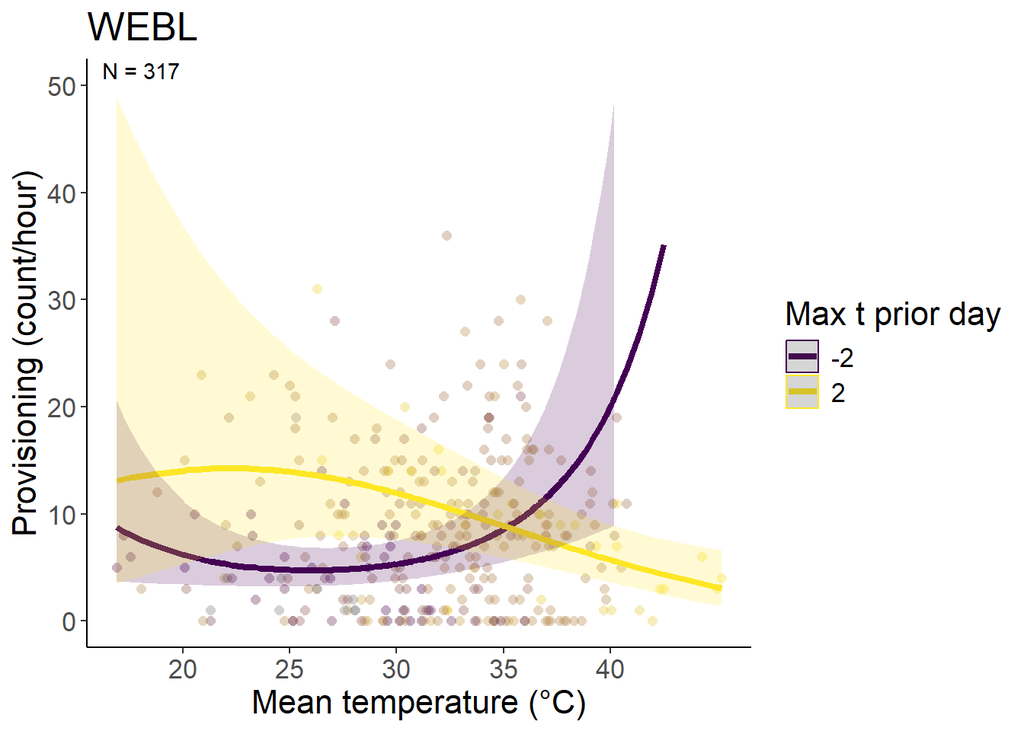

```r
data_webl_q2h1_maxt_prior = dplyr::filter(p,!is.na(mean_temp),
                                  # !is.na(julian_date),
                                  !is.na(mean_nestling_age),
                                  !is.na(maxt_prior),
                                  !is.na(brood_size),
                                  !is.na(tod_h),
                                  !is.na(site),
                                  !is.na(attempt_id),
                                  !is.na(year_fct),
                                  species == "WEBL"# ,
                                                # tod >= hms::as.hms('11:00:00', tz = "America/Los_Angeles"),
                                                # tod_end <= hms::as.hms('17:00:00',tz = "America/Los_Angeles"),
                                                # tod_end >= hms::as.hms('11:00:00', tz = "America/Los_Angeles")
                                                ) %>%
                        mutate(across(c(tod_h,mean_temp,maxt_prior,julian_date,mean_nestling_age,brood_size),
                                                    ~ scale(.x)[,1],
                                                    .names = "{.col}_scaled"))


mean_temp_webl_q2h1_maxt_prior <- mean(data_webl_q2h1_maxt_prior %>% pull(mean_temp))
sd_temp_webl_q2h1_maxt_prior <- sd(data_webl_q2h1_maxt_prior %>% pull(mean_temp))


temp_trans_webl_q2h1_maxt_prior <- trans_new("temp_trans_webl_q2h1_maxt_prior",
                             transform = function(x){(x * sd_temp_webl_q2h1_maxt_prior) + mean_temp_webl_q2h1_maxt_prior},
                             inverse = function(x){x})

(figq2h1_maxt_prior_webl <- predict_response(m_webl_q2h1_maxt_prior,terms = c("mean_temp_scaled [all]","maxt_prior_scaled [-2,2]"),margin = "marginalmeans") %>%
    plot(line_size = 1.5,alpha = .2,limit_range = TRUE,show_data = TRUE,colors = "viridis") +
    # scale_color_hue(labels = c("Low","High")) +
    # aes(linetype = .data[["group"]]) +
    theme_classic() +
    # facet_wrap(~ group, ncol = 2) +
    xlab("Mean temperature (\u00b0C)") +
    ylab("Provisioning (count/hour)") +
    # scale_fill_viridis(discrete = TRUE) +
    # scale_color_viridis(discrete = TRUE) +
    theme(text = element_text(size = 16)) +
    labs(title =  "WEBL", color = "Max t prior day", fill = "Max t prior day") +
    scale_x_continuous(trans = temp_trans_webl_q2h1_maxt_prior,
                       breaks = c((20-mean_temp_webl_q2h1_maxt_prior)/sd_temp_webl_q2h1_maxt_prior,
                                  (25-mean_temp_webl_q2h1_maxt_prior)/sd_temp_webl_q2h1_maxt_prior,
                                  (30-mean_temp_webl_q2h1_maxt_prior)/sd_temp_webl_q2h1_maxt_prior,
                                  (35-mean_temp_webl_q2h1_maxt_prior)/sd_temp_webl_q2h1_maxt_prior,
                                  (40-mean_temp_webl_q2h1_maxt_prior)/sd_temp_webl_q2h1_maxt_prior),
                       # breaks = c(20,30,40,50),
                       # labels = c("20","30","40","50"),
                       # limits = c((15-mean(g$meanmaxtempI,na.rm = TRUE))/sd(g$meanmaxtempI,na.rm = TRUE),
                       #            (55-mean(g$meanmaxtempI,na.rm = TRUE))/sd(g$meanmaxtempI,na.rm = TRUE))
                       # limits = c(18,5)
    ) +
    # scale_linetype_manual(values = "solid") +
    ylim(0,50) +
    geom_text(data = dat_text_webl_q2h1_maxt_prior, mapping = aes(x = -Inf, y = Inf,label = label),hjust = -.2, vjust = 1.2,inherit.aes = FALSE) # +
    #theme(legend.position = "none")
)
```

```r
ggsave("../figures/provisbymaxtempxhab_WEBL_q2h1_maxt_prior.png",plot =  figq2h1_maxt_prior_webl, width = 10, height = 6.6)
```

### TRES

```r
m_TRES <- glmmTMB(valid_detections ~ poly(mean_temp_scaled,2) * maxt_prior_scaled + poly(tod_h_scaled,2) + mean_nestling_age_scaled + brood_size_scaled + year_fct +  (1|site:attempt_id),
           family = nbinom2(),
           ziformula = ~ (1|site:attempt_id),
           data = dplyr::filter(p,!is.na(mean_temp),
                                  # !is.na(julian_date),
                                  !is.na(mean_nestling_age),
                                  !is.na(maxt_prior),
                                  !is.na(brood_size),
                                  !is.na(tod_h),
                                  !is.na(site),
                                  !is.na(attempt_id),
                                  !is.na(year_fct),
                                  species == "TRES"# ,
                                                # tod >= hms::as.hms('11:00:00', tz = "America/Los_Angeles"),
                                                # tod_end <= hms::as.hms('17:00:00',tz = "America/Los_Angeles"),
                                                # tod_end >= hms::as.hms('11:00:00', tz = "America/Los_Angeles")
                                                ) %>%
                        mutate(across(c(tod_h,mean_temp,maxt_prior,julian_date,mean_nestling_age,brood_size),
                                                    ~ scale(.x)[,1],
                                                    .names = "{.col}_scaled")),
           )

m_TRES_noint <- glmmTMB(valid_detections ~ poly(mean_temp_scaled,2) + maxt_prior_scaled + poly(tod_h_scaled,2) + mean_nestling_age_scaled + brood_size_scaled + year_fct +  (1|site:attempt_id),
           family = nbinom2(),
           ziformula = ~ (1|site:attempt_id),
           data = dplyr::filter(p,!is.na(mean_temp),
                                  # !is.na(julian_date),
                                  !is.na(mean_nestling_age),
                                  !is.na(maxt_prior),
                                  !is.na(brood_size),
                                  !is.na(tod_h),
                                  !is.na(site),
                                  !is.na(attempt_id),
                                  !is.na(year_fct),
                                  species == "TRES"# ,
                                                # tod >= hms::as.hms('11:00:00', tz = "America/Los_Angeles"),
                                                # tod_end <= hms::as.hms('17:00:00',tz = "America/Los_Angeles"),
                                                # tod_end >= hms::as.hms('11:00:00', tz = "America/Los_Angeles")
                                                ) %>%
                        mutate(across(c(tod_h,mean_temp,maxt_prior,julian_date,mean_nestling_age,brood_size),
                                                    ~ scale(.x)[,1],
                                                    .names = "{.col}_scaled")),
           )



summary(m_TRES)
```

```
##  Family: nbinom2  ( log )
## Formula:
## valid_detections ~ poly(mean_temp_scaled, 2) * maxt_prior_scaled +
##     poly(tod_h_scaled, 2) + mean_nestling_age_scaled + brood_size_scaled +
##     year_fct + (1 | site:attempt_id)
## Zero inflation:                    ~(1 | site:attempt_id)
## Data: dplyr::filter(p, !is.na(mean_temp), !is.na(mean_nestling_age),
##     !is.na(maxt_prior), !is.na(brood_size), !is.na(tod_h), !is.na(site),
##     !is.na(attempt_id), !is.na(year_fct), species == "TRES") %>%
##     mutate(across(c(tod_h, mean_temp, maxt_prior, julian_date,
##         mean_nestling_age, brood_size), ~scale(.x)[, 1], .names = "{.col}_scaled"))
##
##      AIC      BIC   logLik deviance df.resid
##   1503.8   1558.8   -735.9   1471.8      215
##
## Random effects:
##
## Conditional model:
##  Groups          Name        Variance Std.Dev.
##  site:attempt_id (Intercept) 0.2104   0.4587
## Number of obs: 231, groups:  site:attempt_id, 23
##
## Zero-inflation model:
##  Groups          Name        Variance Std.Dev.
##  site:attempt_id (Intercept) 4.122    2.03
## Number of obs: 231, groups:  site:attempt_id, 23
##
## Dispersion parameter for nbinom2 family (): 3.38
##
## Conditional model:
##                                               Estimate Std. Error z value
## (Intercept)                                   2.578204   0.248699  10.367
## poly(mean_temp_scaled, 2)1                    7.347826   2.034361   3.612
## poly(mean_temp_scaled, 2)2                   -2.579643   1.253346  -2.058
## maxt_prior_scaled                            -0.094071   0.106586  -0.883
## poly(tod_h_scaled, 2)1                        0.971942   0.804819   1.208
## poly(tod_h_scaled, 2)2                        3.256026   1.337663   2.434
## mean_nestling_age_scaled                     -0.005274   0.075352  -0.070
## brood_size_scaled                             0.290590   0.152013   1.912
## year_fct2022                                  0.115141   0.380533   0.303
```

[output cut: 9 more lines]

```
## poly(tod_h_scaled, 2)2                       0.014928 *
## mean_nestling_age_scaled                     0.944203
## brood_size_scaled                            0.055925 .
## year_fct2022                                 0.762211
## year_fct2023                                 0.281490
## poly(mean_temp_scaled, 2)1:maxt_prior_scaled 0.338733
## poly(mean_temp_scaled, 2)2:maxt_prior_scaled 0.682555
## ---
## Signif. codes:  0 '***' 0.001 '**' 0.01 '*' 0.05 '.' 0.1 ' ' 1
##
## Zero-inflation model:
##             Estimate Std. Error z value Pr(>|z|)
## (Intercept)  -2.2655     0.6293    -3.6 0.000318 ***
## ---
## Signif. codes:  0 '***' 0.001 '**' 0.01 '*' 0.05 '.' 0.1 ' ' 1
```

```r
summary(m_TRES_noint)
```

```
##  Family: nbinom2  ( log )
## Formula:
## valid_detections ~ poly(mean_temp_scaled, 2) + maxt_prior_scaled +
##     poly(tod_h_scaled, 2) + mean_nestling_age_scaled + brood_size_scaled +
##     year_fct + (1 | site:attempt_id)
## Zero inflation:                    ~(1 | site:attempt_id)
## Data: dplyr::filter(p, !is.na(mean_temp), !is.na(mean_nestling_age),
##     !is.na(maxt_prior), !is.na(brood_size), !is.na(tod_h), !is.na(site),
##     !is.na(attempt_id), !is.na(year_fct), species == "TRES") %>%
##     mutate(across(c(tod_h, mean_temp, maxt_prior, julian_date,
##         mean_nestling_age, brood_size), ~scale(.x)[, 1], .names = "{.col}_scaled"))
##
##      AIC      BIC   logLik deviance df.resid
##   1500.8   1549.0   -736.4   1472.8      217
##
## Random effects:
##
## Conditional model:
##  Groups          Name        Variance Std.Dev.
##  site:attempt_id (Intercept) 0.1991   0.4462
## Number of obs: 231, groups:  site:attempt_id, 23
##
## Zero-inflation model:
##  Groups          Name        Variance Std.Dev.
##  site:attempt_id (Intercept) 4.084    2.021
## Number of obs: 231, groups:  site:attempt_id, 23
##
## Dispersion parameter for nbinom2 family (): 3.36
##
## Conditional model:
##                             Estimate Std. Error z value Pr(>|z|)
## (Intercept)                 2.642263   0.231478  11.415  < 2e-16 ***
## poly(mean_temp_scaled, 2)1  6.909001   1.955935   3.532 0.000412 ***
## poly(mean_temp_scaled, 2)2 -1.981508   0.937530  -2.114 0.034554 *
## maxt_prior_scaled          -0.099826   0.105746  -0.944 0.345161
## poly(tod_h_scaled, 2)1      0.951667   0.805247   1.182 0.237272
## poly(tod_h_scaled, 2)2      2.884564   1.272359   2.267 0.023384 *
## mean_nestling_age_scaled    0.002287   0.073755   0.031 0.975265
## brood_size_scaled           0.295934   0.148862   1.988 0.046814 *
## year_fct2022                0.128942   0.370645   0.348 0.727926
## year_fct2023               -0.350439   0.299531  -1.170 0.242018
## ---
## Signif. codes:  0 '***' 0.001 '**' 0.01 '*' 0.05 '.' 0.1 ' ' 1
##
## Zero-inflation model:
##             Estimate Std. Error z value Pr(>|z|)
## (Intercept)  -2.2555     0.6266    -3.6 0.000319 ***
## ---
## Signif. codes:  0 '***' 0.001 '**' 0.01 '*' 0.05 '.' 0.1 ' ' 1
```

```r
m_TRES_q2h1_maxt_prior <- m_TRES_noint

check_zeroinflation(m_TRES_noint)
```

```
## # Check for zero-inflation
##
##    Observed zeros: 51
##   Predicted zeros: 52
##             Ratio: 1.01
```

```
## Model seems ok, ratio of observed and predicted zeros is within the
##   tolerance range (p > .999).
```

```r
# (t <- emtrends(m_TRES_q1h1,specs = ~ habitat, var = c("mean_temp_scaled"),max.degree = 1) %>% test() %>%
#    mutate(across(where(is.numeric), ~ round(.x, digits = 3)),
#           df = round(df),
#           p.value = if_else(p.value == 0.000,"<0.001",as.character(p.value))) %>%
#    rename(Habitat = "habitat", `Max temp trend` = "mean_temp_scaled.trend",Df = "df", `Z-ratio` = "z.ratio", P = "p.value") %>%
#    #group_by(degree) %>%
#    gt())

ss_year_TRES_provis_q2h1_maxt_prior <- m_TRES_q2h1_maxt_prior$frame %>%
  group_by(year_fct) %>%
  summarize(count_ind = n(),count_attempt = n_distinct(attempt_id)) %>%
  rowwise() %>%
  mutate(count = tibble(count_ind,count_attempt)) %>%
  dplyr::select(-c(count_ind, count_attempt)) %>%
  pivot_wider(values_from = count,names_from = year_fct) %>%
  as.tibble() %>% # rename(Habitat = 'habitat') %>%
  ungroup() %>%
  mutate(`2021` = replace_na(`2021`,list(count_ind = 0,count_attempt = 0))) %>%
  mutate(Total = `2021` + `2022` + `2023`) %>%
  rowwise() %>%
  mutate(`2021` = paste0(`2021`$count_ind,", ",`2021`$count_attempt),
         `2022` = paste0(`2022`$count_ind,", ",`2022`$count_attempt),
         `2023` = paste0(`2023`$count_ind,", ",`2023`$count_attempt),
         Total = paste0(Total$count_ind,", ",Total$count_attempt)
  )

(t_ss_year_TRES_provis_q2h1_maxt_prior <- ss_year_TRES_provis_q2h1_maxt_prior %>% gt() %>%
    grand_summary_rows(fns = list(id = "Total") ~ {
      t <- str_split(.,", ",simplify = TRUE)
      t[,1] %>% as.numeric() %>% sum(na.rm = TRUE) %>% paste(t[,2] %>% as.numeric() %>% sum(na.rm = TRUE),sep = ", ")
    })
)
```

|  | 2021 | 2022 | 2023 | Total |
| --- | --- | --- | --- | --- |
|  | 64, 7 | 75, 7 | 92, 9 | 231, 23 |
| Total | 64, 7 | 75, 7 | 92, 9 | 231, 23 |

```r
t_ss_year_TRES_provis_q2h1_maxt_prior %>% gtsave("../figures/ss_year_TRES_provis_ch3_q2h1_maxt_prior.html")

samp_q2h1_maxt_prior <- m_TRES_q2h1_maxt_prior$frame %>% summarize(count = n())
samp_q2h1_maxt_prior %>% gt() %>% gtsave("../figures/ss_TRES_provis_ch3_q2h1_maxt_prior.html")


dat_text_TRES_q2h1_maxt_prior <- data.frame(
  label = paste("N =",samp_q2h1_maxt_prior$count)# ,
  #group   = factor(c("Forest","Orchard","Grassland","Row crop"))
)

## num nestboxes
m_TRES_q2h1_maxt_prior$frame %>% pull(attempt_id) %>% unique() %>% length()
```

```
## [1] 23
```

```
## Data points may overlap. Use the `jitter` argument to add some amount of
##   random variation to the location of data points and avoid overplotting.
```

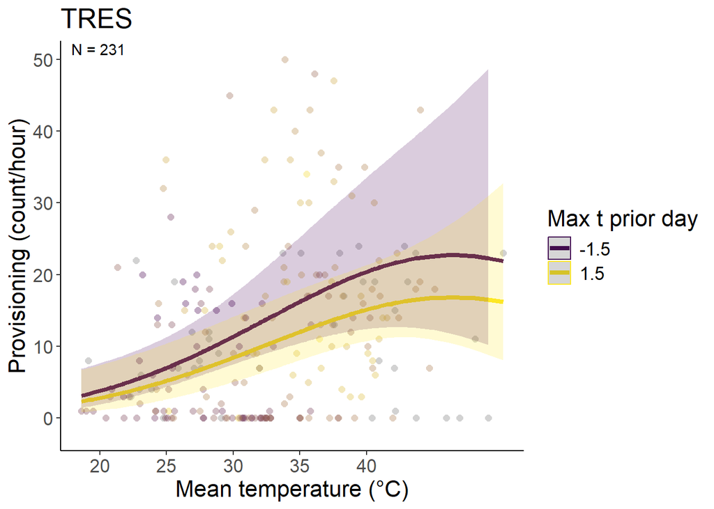

```r
data_TRES_q2h1_maxt_prior = dplyr::filter(p,!is.na(mean_temp),
                                  # !is.na(julian_date),
                                  !is.na(mean_nestling_age),
                                  !is.na(maxt_prior),
                                  !is.na(brood_size),
                                  !is.na(tod_h),
                                  !is.na(site),
                                  !is.na(attempt_id),
                                  !is.na(year_fct),
                                  species == "TRES"# ,
                                                # tod >= hms::as.hms('11:00:00', tz = "America/Los_Angeles"),
                                                # tod_end <= hms::as.hms('17:00:00',tz = "America/Los_Angeles"),
                                                # tod_end >= hms::as.hms('11:00:00', tz = "America/Los_Angeles")
                                                ) %>%
                        mutate(across(c(tod_h,mean_temp,maxt_prior,julian_date,mean_nestling_age,brood_size),
                                                    ~ scale(.x)[,1],
                                                    .names = "{.col}_scaled"))


mean_temp_TRES_q2h1_maxt_prior <- mean(data_TRES_q2h1_maxt_prior %>% pull(mean_temp))
sd_temp_TRES_q2h1_maxt_prior <- sd(data_TRES_q2h1_maxt_prior %>% pull(mean_temp))


temp_trans_TRES_q2h1_maxt_prior <- trans_new("temp_trans_TRES_q2h1_maxt_prior",
                             transform = function(x){(x * sd_temp_TRES_q2h1_maxt_prior) + mean_temp_TRES_q2h1_maxt_prior},
                             inverse = function(x){x})

(figq2h1_maxt_prior_TRES <- predict_response(m_TRES_q2h1_maxt_prior,terms = c("mean_temp_scaled [all]","maxt_prior_scaled [-1.5,1.5]"),margin = "marginalmeans") %>%
    plot(line_size = 1.5,alpha = .2,limit_range = TRUE,show_data = TRUE,colors = "viridis") +
    # scale_color_hue(labels = c("Low","High")) +
    # aes(linetype = .data[["group"]]) +
    theme_classic() +
    # facet_wrap(~ group, ncol = 2) +
    xlab("Mean temperature (\u00b0C)") +
    ylab("Provisioning (count/hour)") +
    # scale_fill_viridis(discrete = TRUE) +
    # scale_color_viridis(discrete = TRUE) +
    theme(text = element_text(size = 16)) +
    labs(title =  "TRES", color = "Max t prior day", fill = "Max t prior day") +
    scale_x_continuous(trans = temp_trans_TRES_q2h1_maxt_prior,
                       breaks = c((20-mean_temp_TRES_q2h1_maxt_prior)/sd_temp_TRES_q2h1_maxt_prior,
                                  (25-mean_temp_TRES_q2h1_maxt_prior)/sd_temp_TRES_q2h1_maxt_prior,
                                  (30-mean_temp_TRES_q2h1_maxt_prior)/sd_temp_TRES_q2h1_maxt_prior,
                                  (35-mean_temp_TRES_q2h1_maxt_prior)/sd_temp_TRES_q2h1_maxt_prior,
                                  (40-mean_temp_TRES_q2h1_maxt_prior)/sd_temp_TRES_q2h1_maxt_prior),
                       # breaks = c(20,30,40,50),
                       # labels = c("20","30","40","50"),
                       # limits = c((15-mean(g$meanmaxtempI,na.rm = TRUE))/sd(g$meanmaxtempI,na.rm = TRUE),
                       #            (55-mean(g$meanmaxtempI,na.rm = TRUE))/sd(g$meanmaxtempI,na.rm = TRUE))
                       # limits = c(18,5)
    ) +
    # scale_linetype_manual(values = "solid") +
    ylim(-2,50) +
    geom_text(data = dat_text_TRES_q2h1_maxt_prior, mapping = aes(x = -Inf, y = Inf,label = label),hjust = -.2, vjust = 1.2,inherit.aes = FALSE) # +
    #theme(legend.position = "none")
)
```

```r
ggsave("../figures/provisbymaxtempxhab_TRES_q2h1_maxt_prior.png",plot =  figq2h1_maxt_prior_TRES, width = 10, height = 6.6)
```

## Q2H2

2. What mediates how responsive provisioning rates are to temperature? (H2) females in better condition (mass/tarsus) would be less likely than females in worse condition to reduce their visits during hot periods because they are able to mobilize the energy required to engage in more energetically costly active thermoregulatory behaviors

### WEBL

```r
m_WEBL <- glmmTMB(valid_detections ~ poly(mean_temp_scaled,2) * female_condition_scaled + poly(tod_h_scaled,2) + mean_nestling_age_scaled + brood_size_scaled + year_fct + (1|site:attempt_id),
           family = nbinom2(),
           ziformula = ~ 1,
           data = dplyr::filter(p,!is.na(mean_temp),
                                !is.na(female_condition),
                                  # !is.na(julian_date),
                                  !is.na(mean_nestling_age),
                                  !is.na(brood_size),
                                  !is.na(tod_h),
                                  !is.na(site),
                                  !is.na(attempt_id),
                                  !is.na(year),
                                  species == "WEBL"# ,
                                                # tod >= hms::as.hms('11:00:00', tz = "America/Los_Angeles"),
                                                # tod_end <= hms::as.hms('17:00:00',tz = "America/Los_Angeles"),
                                                # tod_end >= hms::as.hms('11:00:00', tz = "America/Los_Angeles")
                                                ) %>%
                        mutate(across(c(tod_h,mean_temp,female_condition,julian_date,mean_nestling_age,brood_size),
                                                    ~ scale(.x)[,1],
                                                    .names = "{.col}_scaled")),
           )

m_WEBL_linint <- glmmTMB(valid_detections ~ mean_temp_scaled * female_condition_scaled + poly(mean_temp_scaled,degree = 2) + poly(tod_h_scaled,2) + mean_nestling_age_scaled + brood_size_scaled + year_fct + (1|site:attempt_id),
           family = nbinom2(),
           ziformula = ~ 1,
           data = dplyr::filter(p,!is.na(mean_temp),
                                !is.na(female_condition),
                                  # !is.na(julian_date),
                                  !is.na(mean_nestling_age),
                                  !is.na(brood_size),
                                  !is.na(tod_h),
                                  !is.na(site),
                                  !is.na(attempt_id),
                                  !is.na(year),
                                  species == "WEBL"# ,
                                                # tod >= hms::as.hms('11:00:00', tz = "America/Los_Angeles"),
                                                # tod_end <= hms::as.hms('17:00:00',tz = "America/Los_Angeles"),
                                                # tod_end >= hms::as.hms('11:00:00', tz = "America/Los_Angeles")
                                                ) %>%
                        mutate(across(c(tod_h,mean_temp,female_condition,julian_date,mean_nestling_age,brood_size),
                                                    ~ scale(.x)[,1],
                                                    .names = "{.col}_scaled")),
           )
```

```
## dropping columns from rank-deficient conditional model: poly(mean_temp_scaled, degree = 2)1
```

```r
m_WEBL_noint <- glmmTMB(valid_detections ~ female_condition_scaled + poly(mean_temp_scaled,degree = 2) + poly(tod_h_scaled,2) + mean_nestling_age_scaled + brood_size_scaled + year_fct + (1|site:attempt_id),
           family = nbinom2(),
           ziformula = ~ 1,
           data = dplyr::filter(p,!is.na(mean_temp),
                                !is.na(female_condition),
                                  # !is.na(julian_date),
                                  !is.na(mean_nestling_age),
                                  !is.na(brood_size),
                                  !is.na(tod_h),
                                  !is.na(site),
                                  !is.na(attempt_id),
                                  !is.na(year),
                                  species == "WEBL"# ,
                                                # tod >= hms::as.hms('11:00:00', tz = "America/Los_Angeles"),
                                                # tod_end <= hms::as.hms('17:00:00',tz = "America/Los_Angeles"),
                                                # tod_end >= hms::as.hms('11:00:00', tz = "America/Los_Angeles")
                                                ) %>%
                        mutate(across(c(tod_h,mean_temp,female_condition,julian_date,mean_nestling_age,brood_size),
                                                    ~ scale(.x)[,1],
                                                    .names = "{.col}_scaled")),
           )




c <- anova(m_WEBL,m_WEBL_linint,m_WEBL_noint) %>% tibble() %>% mutate(Model = c("No temp * LC interaction","Linear temp * LC interaction","Squared temp * LC interaction"),.before = Df)

(tab <- c %>%
  as.tibble() %>%
  mutate(across(where(is.numeric),~round(.x,digits = 4)),
         P = `Pr(>Chisq)`) %>%
  dplyr::select(Model,AIC,Chisq,P) %>%
  mutate(across(c(AIC,Chisq), ~ round(.x, digits = 2)),
         P = if_else(P < 0.001,"<0.001",as.character(P))) %>% gt())
```

| Model | AIC | Chisq | P |
| --- | --- | --- | --- |
| No temp * LC interaction | 876.26 | NA | NA |
| Linear temp * LC interaction | 873.59 | 4.67 | 0.0307 |
| Squared temp * LC interaction | 875.49 | 0.10 | 0.7569 |

```r
gtsave(tab,"../figures/int_tab_provis_ch3_q2h2_webl.html")

summary(m_WEBL_linint)
```

```
##  Family: nbinom2  ( log )
## Formula:
## valid_detections ~ mean_temp_scaled * female_condition_scaled +
##     poly(mean_temp_scaled, degree = 2) + poly(tod_h_scaled, 2) +
##     mean_nestling_age_scaled + brood_size_scaled + year_fct +
##     (1 | site:attempt_id)
## Zero inflation:                    ~1
## Data: dplyr::filter(p, !is.na(mean_temp), !is.na(female_condition),
##     !is.na(mean_nestling_age), !is.na(brood_size), !is.na(tod_h),
##     !is.na(site), !is.na(attempt_id), !is.na(year), species ==
##         "WEBL") %>% mutate(across(c(tod_h, mean_temp, female_condition,
##     julian_date, mean_nestling_age, brood_size), ~scale(.x)[,
##     1], .names = "{.col}_scaled"))
##
##      AIC      BIC   logLik deviance df.resid
##    873.6    913.2   -423.8    847.6      142
##
## Random effects:
##
## Conditional model:
##  Groups          Name        Variance Std.Dev.
##  site:attempt_id (Intercept) 0.4757   0.6897
## Number of obs: 155, groups:  site:attempt_id, 14
##
## Dispersion parameter for nbinom2 family (): 5.81
##
## Conditional model:
##                                          Estimate Std. Error z value Pr(>|z|)
## (Intercept)                               1.95928    0.32151   6.094 1.10e-09
## mean_temp_scaled                         -0.49344    0.10154  -4.859 1.18e-06
## female_condition_scaled                  -0.11452    0.19008  -0.602  0.54686
## poly(mean_temp_scaled, degree = 2)1            NA         NA      NA       NA
## poly(mean_temp_scaled, degree = 2)2      -1.19858    0.84914  -1.412  0.15809
## poly(tod_h_scaled, 2)1                   -1.45894    0.59201  -2.464  0.01373
## poly(tod_h_scaled, 2)2                   -1.01990    0.88722  -1.150  0.25033
## mean_nestling_age_scaled                  0.09839    0.07220   1.363  0.17295
## brood_size_scaled                         0.47593    0.16684   2.853  0.00434
## year_fct2023                             -0.80079    0.43071  -1.859  0.06299
## mean_temp_scaled:female_condition_scaled -0.15207    0.07044  -2.159  0.03087
##
## (Intercept)                              ***
## mean_temp_scaled                         ***
## female_condition_scaled
## poly(mean_temp_scaled, degree = 2)1
## poly(mean_temp_scaled, degree = 2)2
## poly(tod_h_scaled, 2)1                   *
## poly(tod_h_scaled, 2)2
## mean_nestling_age_scaled
## brood_size_scaled                        **
## year_fct2023                             .
## mean_temp_scaled:female_condition_scaled *
## ---
## Signif. codes:  0 '***' 0.001 '**' 0.01 '*' 0.05 '.' 0.1 ' ' 1
##
## Zero-inflation model:
##             Estimate Std. Error z value Pr(>|z|)
## (Intercept)   -20.05    4569.78  -0.004    0.996
```

```r
summary(m_WEBL_noint)
```

```
##  Family: nbinom2  ( log )
## Formula:
## valid_detections ~ female_condition_scaled + poly(mean_temp_scaled,
##     degree = 2) + poly(tod_h_scaled, 2) + mean_nestling_age_scaled +
##     brood_size_scaled + year_fct + (1 | site:attempt_id)
## Zero inflation:                    ~1
## Data: dplyr::filter(p, !is.na(mean_temp), !is.na(female_condition),
##     !is.na(mean_nestling_age), !is.na(brood_size), !is.na(tod_h),
##     !is.na(site), !is.na(attempt_id), !is.na(year), species ==
##         "WEBL") %>% mutate(across(c(tod_h, mean_temp, female_condition,
##     julian_date, mean_nestling_age, brood_size), ~scale(.x)[,
##     1], .names = "{.col}_scaled"))
##
##      AIC      BIC   logLik deviance df.resid
##    876.3    912.8   -426.1    852.3      143
##
## Random effects:
##
## Conditional model:
##  Groups          Name        Variance Std.Dev.
##  site:attempt_id (Intercept) 0.5192   0.7206
## Number of obs: 155, groups:  site:attempt_id, 14
##
## Dispersion parameter for nbinom2 family (): 5.63
##
## Conditional model:
##                                     Estimate Std. Error z value Pr(>|z|)
## (Intercept)                          1.99789    0.33465   5.970 2.37e-09 ***
## female_condition_scaled             -0.05723    0.19561  -0.293  0.76986
## poly(mean_temp_scaled, degree = 2)1 -5.74758    1.25329  -4.586 4.52e-06 ***
## poly(mean_temp_scaled, degree = 2)2 -0.32832    0.75134  -0.437  0.66212
## poly(tod_h_scaled, 2)1              -1.34664    0.59377  -2.268  0.02333 *
## poly(tod_h_scaled, 2)2              -1.07345    0.89382  -1.201  0.22976
## mean_nestling_age_scaled             0.10747    0.07222   1.488  0.13673
## brood_size_scaled                    0.44524    0.16941   2.628  0.00858 **
## year_fct2023                        -0.74866    0.44622  -1.678  0.09339 .
## ---
## Signif. codes:  0 '***' 0.001 '**' 0.01 '*' 0.05 '.' 0.1 ' ' 1
##
## Zero-inflation model:
##             Estimate Std. Error z value Pr(>|z|)
## (Intercept)   -19.26    4358.99  -0.004    0.996
```

```r
m_webl_q2h2 <- m_WEBL_linint

check_zeroinflation(m_WEBL_linint)
```

```
## # Check for zero-inflation
##
##    Observed zeros: 17
##   Predicted zeros: 12
##             Ratio: 0.73
```

```
## Model is underfitting zeros (probable zero-inflation) (p = 0.352).
```

```r
(t <- emtrends(m_webl_q2h2,specs = ~ female_condition_scaled, var = c("mean_temp_scaled"),max.degree = 1) %>% test() %>%
   mutate(across(where(is.numeric), ~ round(.x, digits = 3)),
          df = round(df),
          p.value = if_else(p.value == 0.000,"<0.001",as.character(p.value))) %>%
   rename(`Female condition` = "female_condition_scaled", `Max temp trend` = "mean_temp_scaled.trend",Df = "df", `Z-ratio` = "z.ratio", P = "p.value") %>%
   #group_by(degree) %>%
   gt())
```

| Female condition | Max temp trend | SE | Df | Z-ratio | P |
| --- | --- | --- | --- | --- | --- |
| 0 | -0.492 | 0.101 | Inf | -4.85 | <0.001 |

```r
joint_tests(m_webl_q2h2)
```

|  | model term | df1 | df2 | F.ratio | Chisq | p.value |
| --- | --- | --- | --- | --- | --- | --- |
| 1 | mean_temp_scaled | 1 | Inf | 23.502 | 23.502 | 1.247939e-06 |
| 3 | female_condition_scaled | 1 | Inf | 0.363 | 0.363 | 5.468570e-01 |
| 4 | tod_h_scaled | 1 | Inf | 5.213 | 5.213 | 2.242063e-02 |
| 5 | mean_nestling_age_scaled | 1 | Inf | 1.857 | 1.857 | 1.729457e-01 |
| 6 | brood_size_scaled | 1 | Inf | 8.137 | 8.137 | 4.336517e-03 |
| 7 | year_fct | 1 | Inf | 3.457 | 3.457 | 6.299246e-02 |
| 2 | mean_temp_scaled:female_condition_scaled | 1 | Inf | 4.660 | 4.660 | 3.086834e-02 |

```r
# gtsave(t,"../figures/weblprovistrend_ch3_q2h2.html")


ss_year_webl_provis <- m_webl_q2h2$frame %>%
  group_by(year_fct) %>%
  summarize(count_ind = n(),count_attempt = n_distinct(attempt_id)) %>%
  rowwise() %>%
  mutate(count = tibble(count_ind,count_attempt)) %>%
  dplyr::select(-c(count_ind, count_attempt)) %>%
  pivot_wider(values_from = count,names_from = year_fct) %>%
  as.tibble() %>%
  ungroup() %>%
  # mutate(`2021` = replace_na(`2021`,list(count_ind = 0,count_attempt = 0))) %>%
  mutate(Total = `2022` + `2023`) %>%
  rowwise() %>%
  mutate(`2022` = paste0(`2022`$count_ind,", ",`2022`$count_attempt),
         `2023` = paste0(`2023`$count_ind,", ",`2023`$count_attempt),
         Total = paste0(Total$count_ind,", ",Total$count_attempt)
  )

(t_ss_year_webl_provis <- ss_year_webl_provis %>% gt() %>%
    grand_summary_rows(fns = list(id = "Total") ~ {
      t <- str_split(.,", ",simplify = TRUE)
      t[,1] %>% as.numeric() %>% sum(na.rm = TRUE) %>% paste(t[,2] %>% as.numeric() %>% sum(na.rm = TRUE),sep = ", ")
    })
)
```

|  | 2022 | 2023 | Total |
| --- | --- | --- | --- |
|  | 88, 5 | 67, 9 | 155, 14 |
| Total | 88, 5 | 67, 9 | 155, 14 |

```r
t_ss_year_webl_provis %>% gtsave("../figures/ss_year_webl_provis_ch3.html")

samp <- m_webl_q2h2$frame %>% summarize(count = n())
samp %>% gt() %>% gtsave("../figures/ss_webl_provis_ch3.html")


dat_text_webl_q2h2 <- data.frame(
  label = paste("N =",samp$count),
  group   = factor(c("Forest","Orchard","Grassland","Row crop"))
)

## num nestboxes
m_webl_q2h2$frame %>% pull(attempt_id) %>% unique() %>% length()
```

```
## [1] 14
```

```
## Data points may overlap. Use the `jitter` argument to add some amount of
##   random variation to the location of data points and avoid overplotting.
```

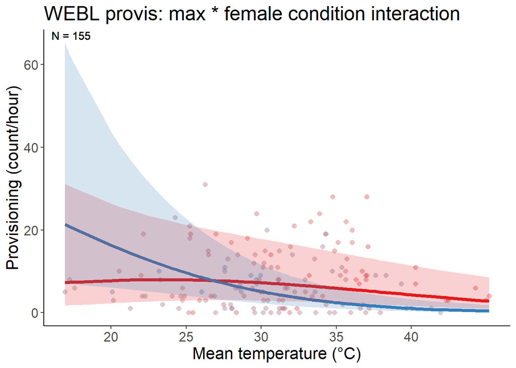

```r
data_webl_q2h2 = dplyr::filter(p,!is.na(mean_temp),
                               !is.na(female_condition),
                                  # !is.na(julian_date),
                                  !is.na(mean_nestling_age),
                                  !is.na(brood_size),
                                  !is.na(tod_h),
                                  !is.na(site),
                                  !is.na(attempt_id),
                                  !is.na(year),
                                  species == "WEBL"# ,
                                                # tod >= hms::as.hms('11:00:00', tz = "America/Los_Angeles"),
                                                # tod_end <= hms::as.hms('17:00:00',tz = "America/Los_Angeles"),
                                                # tod_end >= hms::as.hms('11:00:00', tz = "America/Los_Angeles")
                                                ) %>%
                        mutate(across(c(tod_h,mean_temp,female_condition,julian_date,mean_nestling_age,brood_size),
                                                    ~ scale(.x)[,1],
                                                    .names = "{.col}_scaled"))


mean_temp_webl_q2h2 <- mean(data_webl_q2h2 %>% pull(mean_temp))
sd_temp_webl_q2h2 <- sd(data_webl_q2h2 %>% pull(mean_temp))


temp_trans_webl_q2h2 <- trans_new("temp_trans_webl_q2h2",
                             transform = function(x){(x * sd_temp_webl_q2h2) + mean_temp_webl_q2h2},
                             inverse = function(x){x})

(figq2h2_webl <- predict_response(m_webl_q2h2,terms = c("mean_temp_scaled [all]","female_condition_scaled [-2,2]"),margin = "marginalmeans") %>%
    plot(line_size = 1.5,alpha = .2,show_data = TRUE,limit_range = TRUE) +
    # aes(linetype = .data[["group"]]) +
    theme_classic() +
    # facet_wrap(~ group, ncol = 2) +
    xlab("Mean temperature (\u00b0C)") +
    ylab("Provisioning (count/hour)") +
    # scale_fill_viridis(discrete = TRUE) +
    # scale_color_viridis(discrete = TRUE) +
    theme(text = element_text(size = 16)) +
    labs(title =  "WEBL provis: max * female condition interaction") +
    scale_x_continuous(trans = temp_trans_webl_q2h2,
                       breaks = c((20-mean_temp_webl_q2h2)/sd_temp_webl_q2h2,
                                  (25-mean_temp_webl_q2h2)/sd_temp_webl_q2h2,
                                  (30-mean_temp_webl_q2h2)/sd_temp_webl_q2h2,
                                  (35-mean_temp_webl_q2h2)/sd_temp_webl_q2h2,
                                  (40-mean_temp_webl_q2h2)/sd_temp_webl_q2h2),
                       # breaks = c(20,30,40,50),
                       # labels = c("20","30","40","50"),
                       # limits = c((15-mean(g$meanmaxtempI,na.rm = TRUE))/sd(g$meanmaxtempI,na.rm = TRUE),
                       #            (55-mean(g$meanmaxtempI,na.rm = TRUE))/sd(g$meanmaxtempI,na.rm = TRUE))
                       # limits = c(18,5)
    ) +
    # scale_linetype_manual(values = c("Forest" = "solid","Orchard" = "dashed","Grassland" = "solid","Row crop" = "dotted")) +
    #ylim(-5,5) +
    geom_text(data = dat_text_webl_q2h2, mapping = aes(x = -Inf, y = Inf,label = label),hjust = -.2, vjust = 1.2,inherit.aes = FALSE) +
    theme(legend.position = "none")
)
```

```r
ggsave("../figures/provisbymaxtempxhab_WEBL_q2h2.png",plot =  figq2h2_webl, width = 10, height = 6.6)
```

When it’s hot, females in better condition provision less. Maybe they have the capacity to compensate?

### TRES

```r
m_TRES <- glmmTMB(valid_detections ~ poly(mean_temp_scaled,2) * female_condition_scaled + poly(tod_h_scaled,2) + mean_nestling_age_scaled + brood_size_scaled + year_fct + (1|site:attempt_id),
           family = nbinom2(),
           ziformula = ~ 1,
           data = dplyr::filter(p,!is.na(mean_temp),
                                !is.na(female_condition),
                                  # !is.na(julian_date),
                                  !is.na(mean_nestling_age),
                                  !is.na(brood_size),
                                  !is.na(tod_h),
                                  !is.na(site),
                                  !is.na(attempt_id),
                                  !is.na(year),
                                  species == "TRES"# ,
                                                # tod >= hms::as.hms('11:00:00', tz = "America/Los_Angeles"),
                                                # tod_end <= hms::as.hms('17:00:00',tz = "America/Los_Angeles"),
                                                # tod_end >= hms::as.hms('11:00:00', tz = "America/Los_Angeles")
                                                ) %>%
                        mutate(across(c(tod_h,mean_temp,female_condition,julian_date,mean_nestling_age,brood_size),
                                                    ~ scale(.x)[,1],
                                                    .names = "{.col}_scaled")),
           )

m_TRES_linint <- glmmTMB(valid_detections ~ mean_temp_scaled * female_condition_scaled + poly(mean_temp_scaled,degree = 2) + poly(tod_h_scaled,2) + mean_nestling_age_scaled + brood_size_scaled + year_fct + (1|site:attempt_id),
           family = nbinom2(),
           ziformula = ~ 1,
           data = dplyr::filter(p,!is.na(mean_temp),
                                !is.na(female_condition),
                                  # !is.na(julian_date),
                                  !is.na(mean_nestling_age),
                                  !is.na(brood_size),
                                  !is.na(tod_h),
                                  !is.na(site),
                                  !is.na(attempt_id),
                                  !is.na(year),
                                  species == "TRES"# ,
                                                # tod >= hms::as.hms('11:00:00', tz = "America/Los_Angeles"),
                                                # tod_end <= hms::as.hms('17:00:00',tz = "America/Los_Angeles"),
                                                # tod_end >= hms::as.hms('11:00:00', tz = "America/Los_Angeles")
                                                ) %>%
                        mutate(across(c(tod_h,mean_temp,female_condition,julian_date,mean_nestling_age,brood_size),
                                                    ~ scale(.x)[,1],
                                                    .names = "{.col}_scaled")),
           )
```

```
## dropping columns from rank-deficient conditional model: poly(mean_temp_scaled, degree = 2)1
```

```r
m_TRES_noint <- glmmTMB(valid_detections ~ female_condition_scaled + poly(mean_temp_scaled,degree = 2) + poly(tod_h_scaled,2) + mean_nestling_age_scaled + brood_size_scaled + year_fct + (1|site:attempt_id),
           family = nbinom2(),
           ziformula = ~ 1,
           data = dplyr::filter(p,!is.na(mean_temp),
                                !is.na(female_condition),
                                  # !is.na(julian_date),
                                  !is.na(mean_nestling_age),
                                  !is.na(brood_size),
                                  !is.na(tod_h),
                                  !is.na(site),
                                  !is.na(attempt_id),
                                  !is.na(year),
                                  species == "TRES"# ,
                                                # tod >= hms::as.hms('11:00:00', tz = "America/Los_Angeles"),
                                                # tod_end <= hms::as.hms('17:00:00',tz = "America/Los_Angeles"),
                                                # tod_end >= hms::as.hms('11:00:00', tz = "America/Los_Angeles")
                                                ) %>%
                        mutate(across(c(tod_h,mean_temp,female_condition,julian_date,mean_nestling_age,brood_size),
                                                    ~ scale(.x)[,1],
                                                    .names = "{.col}_scaled")),
           )




c <- anova(m_TRES,m_TRES_linint,m_TRES_noint) %>% tibble() %>% mutate(Model = c("No temp * LC interaction","Linear temp * LC interaction","Squared temp * LC interaction"),.before = Df)

(tab <- c %>%
  as.tibble() %>%
  mutate(across(where(is.numeric),~round(.x,digits = 4)),
         P = `Pr(>Chisq)`) %>%
  dplyr::select(Model,AIC,Chisq,P) %>%
  mutate(across(c(AIC,Chisq), ~ round(.x, digits = 2)),
         P = if_else(P < 0.001,"<0.001",as.character(P))) %>% gt())
```

| Model | AIC | Chisq | P |
| --- | --- | --- | --- |
| No temp * LC interaction | 1046.62 | NA | NA |
| Linear temp * LC interaction | 1048.55 | 0.07 | 0.7981 |
| Squared temp * LC interaction | 1050.50 | 0.06 | 0.8101 |

```r
gtsave(tab,"../figures/int_tab_provis_ch3_q2h2_tres.html")

summary(m_TRES_linint)
```

```
##  Family: nbinom2  ( log )
## Formula:
## valid_detections ~ mean_temp_scaled * female_condition_scaled +
##     poly(mean_temp_scaled, degree = 2) + poly(tod_h_scaled, 2) +
##     mean_nestling_age_scaled + brood_size_scaled + year_fct +
##     (1 | site:attempt_id)
## Zero inflation:                    ~1
## Data: dplyr::filter(p, !is.na(mean_temp), !is.na(female_condition),
##     !is.na(mean_nestling_age), !is.na(brood_size), !is.na(tod_h),
##     !is.na(site), !is.na(attempt_id), !is.na(year), species ==
##         "TRES") %>% mutate(across(c(tod_h, mean_temp, female_condition,
##     julian_date, mean_nestling_age, brood_size), ~scale(.x)[,
##     1], .names = "{.col}_scaled"))
##
##      AIC      BIC   logLik deviance df.resid
##   1048.6   1088.2   -511.3   1022.6      143
##
## Random effects:
##
## Conditional model:
##  Groups          Name        Variance Std.Dev.
##  site:attempt_id (Intercept) 0.8308   0.9115
## Number of obs: 156, groups:  site:attempt_id, 14
##
## Dispersion parameter for nbinom2 family (): 2.87
##
## Conditional model:
##                                          Estimate Std. Error z value Pr(>|z|)
## (Intercept)                               2.70791    0.50444   5.368 7.95e-08
## mean_temp_scaled                          0.53263    0.18678   2.852  0.00435
## female_condition_scaled                   0.64644    0.32268   2.003  0.04514
## poly(mean_temp_scaled, degree = 2)1            NA         NA      NA       NA
## poly(mean_temp_scaled, degree = 2)2      -1.01704    0.98240  -1.035  0.30055
## poly(tod_h_scaled, 2)1                   -0.46210    0.86813  -0.532  0.59452
## poly(tod_h_scaled, 2)2                    3.11433    1.46649   2.124  0.03370
## mean_nestling_age_scaled                 -0.01919    0.10128  -0.189  0.84972
## brood_size_scaled                         0.61321    0.38074   1.611  0.10727
## year_fct2023                             -0.92232    0.75130  -1.228  0.21959
## mean_temp_scaled:female_condition_scaled -0.02745    0.10707  -0.256  0.79765
##
## (Intercept)                              ***
## mean_temp_scaled                         **
## female_condition_scaled                  *
## poly(mean_temp_scaled, degree = 2)1
## poly(mean_temp_scaled, degree = 2)2
## poly(tod_h_scaled, 2)1
## poly(tod_h_scaled, 2)2                   *
## mean_nestling_age_scaled
## brood_size_scaled
## year_fct2023
## mean_temp_scaled:female_condition_scaled
## ---
## Signif. codes:  0 '***' 0.001 '**' 0.01 '*' 0.05 '.' 0.1 ' ' 1
##
## Zero-inflation model:
##             Estimate Std. Error z value Pr(>|z|)
## (Intercept)  -2.1114     0.3061  -6.898 5.28e-12 ***
## ---
## Signif. codes:  0 '***' 0.001 '**' 0.01 '*' 0.05 '.' 0.1 ' ' 1
```

```r
summary(m_TRES_noint)
```

```
##  Family: nbinom2  ( log )
## Formula:
## valid_detections ~ female_condition_scaled + poly(mean_temp_scaled,
##     degree = 2) + poly(tod_h_scaled, 2) + mean_nestling_age_scaled +
##     brood_size_scaled + year_fct + (1 | site:attempt_id)
## Zero inflation:                    ~1
## Data: dplyr::filter(p, !is.na(mean_temp), !is.na(female_condition),
##     !is.na(mean_nestling_age), !is.na(brood_size), !is.na(tod_h),
##     !is.na(site), !is.na(attempt_id), !is.na(year), species ==
##         "TRES") %>% mutate(across(c(tod_h, mean_temp, female_condition,
##     julian_date, mean_nestling_age, brood_size), ~scale(.x)[,
##     1], .names = "{.col}_scaled"))
##
##      AIC      BIC   logLik deviance df.resid
##   1046.6   1083.2   -511.3   1022.6      144
##
## Random effects:
##
## Conditional model:
##  Groups          Name        Variance Std.Dev.
##  site:attempt_id (Intercept) 0.8181   0.9045
## Number of obs: 156, groups:  site:attempt_id, 14
##
## Dispersion parameter for nbinom2 family (): 2.84
##
## Conditional model:
##                                     Estimate Std. Error z value Pr(>|z|)
## (Intercept)                          2.71217    0.50072   5.416 6.08e-08 ***
## female_condition_scaled              0.65048    0.32018   2.032  0.04219 *
## poly(mean_temp_scaled, degree = 2)1  6.59523    2.32565   2.836  0.00457 **
## poly(mean_temp_scaled, degree = 2)2 -0.97897    0.97630  -1.003  0.31599
## poly(tod_h_scaled, 2)1              -0.44642    0.86791  -0.514  0.60700
## poly(tod_h_scaled, 2)2               3.15481    1.46367   2.155  0.03113 *
## mean_nestling_age_scaled            -0.02132    0.10137  -0.210  0.83342
## brood_size_scaled                    0.61023    0.37808   1.614  0.10652
## year_fct2023                        -0.92834    0.74643  -1.244  0.21361
## ---
## Signif. codes:  0 '***' 0.001 '**' 0.01 '*' 0.05 '.' 0.1 ' ' 1
##
## Zero-inflation model:
##             Estimate Std. Error z value Pr(>|z|)
## (Intercept)   -2.118      0.307  -6.899 5.25e-12 ***
## ---
## Signif. codes:  0 '***' 0.001 '**' 0.01 '*' 0.05 '.' 0.1 ' ' 1
```

```r
m_tres_q2h2 <- m_TRES_noint

check_zeroinflation(m_TRES_noint)
```

```
## # Check for zero-inflation
##
##    Observed zeros: 29
##   Predicted zeros: 26
##             Ratio: 0.91
```

```
## Model seems ok, ratio of observed and predicted zeros is within the
##   tolerance range (p = 0.608).
```

```r
(t <- emtrends(m_tres_q2h2,specs = ~ female_condition_scaled, var = c("mean_temp_scaled"),max.degree = 1) %>% test() %>%
   mutate(across(where(is.numeric), ~ round(.x, digits = 3)),
          df = round(df),
          p.value = if_else(p.value == 0.000,"<0.001",as.character(p.value))) %>%
   rename(`Female condition` = "female_condition_scaled", `Max temp trend` = "mean_temp_scaled.trend",Df = "df", `Z-ratio` = "z.ratio", P = "p.value") %>%
   #group_by(degree) %>%
   gt())
```

| Female condition | Max temp trend | SE | Df | Z-ratio | P |
| --- | --- | --- | --- | --- | --- |
| 0 | 0.523 | 0.185 | Inf | 2.821 | 0.005 |

```r
joint_tests(m_tres_q2h2)
```

|  | model term | df1 | df2 | F.ratio | Chisq | p.value |
| --- | --- | --- | --- | --- | --- | --- |
| 1 | female_condition_scaled | 1 | Inf | 4.127 | 4.127 | 0.042192875 |
| 2 | mean_temp_scaled | 1 | Inf | 7.964 | 7.964 | 0.004772756 |
| 3 | tod_h_scaled | 1 | Inf | 1.198 | 1.198 | 0.273735294 |
| 4 | mean_nestling_age_scaled | 1 | Inf | 0.044 | 0.044 | 0.833419886 |
| 5 | brood_size_scaled | 1 | Inf | 2.605 | 2.605 | 0.106516328 |
| 6 | year_fct | 1 | Inf | 1.547 | 1.547 | 0.213610297 |

```r
# gtsave(t,"../figures/tresprovistrend_ch3_q2h2.html")


ss_year_tres_provis <- m_tres_q2h2$frame %>%
  group_by(year_fct) %>%
  summarize(count_ind = n(),count_attempt = n_distinct(attempt_id)) %>%
  rowwise() %>%
  mutate(count = tibble(count_ind,count_attempt)) %>%
  dplyr::select(-c(count_ind, count_attempt)) %>%
  pivot_wider(values_from = count,names_from = year_fct) %>%
  as.tibble() %>%
  ungroup() %>%
  # mutate(`2021` = replace_na(`2021`,list(count_ind = 0,count_attempt = 0))) %>%
  mutate(Total = `2022` + `2023`) %>%
  rowwise() %>%
  mutate(`2022` = paste0(`2022`$count_ind,", ",`2022`$count_attempt),
         `2023` = paste0(`2023`$count_ind,", ",`2023`$count_attempt),
         Total = paste0(Total$count_ind,", ",Total$count_attempt)
  )

(t_ss_year_tres_provis <- ss_year_tres_provis %>% gt() %>%
    grand_summary_rows(fns = list(id = "Total") ~ {
      t <- str_split(.,", ",simplify = TRUE)
      t[,1] %>% as.numeric() %>% sum(na.rm = TRUE) %>% paste(t[,2] %>% as.numeric() %>% sum(na.rm = TRUE),sep = ", ")
    })
)
```

|  | 2022 | 2023 | Total |
| --- | --- | --- | --- |
|  | 68, 6 | 88, 8 | 156, 14 |
| Total | 68, 6 | 88, 8 | 156, 14 |

```r
t_ss_year_tres_provis %>% gtsave("../figures/ss_year_tres_provis_ch3.html")

samp <- m_tres_q2h2$frame %>% summarize(count = n())
samp %>% gt() %>% gtsave("../figures/ss_tres_provis_ch3.html")


dat_text_tres_q2h2 <- data.frame(
  label = paste("N =",samp$count),
  group   = factor(c("Forest","Orchard","Grassland","Row crop"))
)

## num nestboxes
m_tres_q2h2$frame %>% pull(attempt_id) %>% unique() %>% length()
```

```
## [1] 14
```

```
## Data points may overlap. Use the `jitter` argument to add some amount of
##   random variation to the location of data points and avoid overplotting.
```

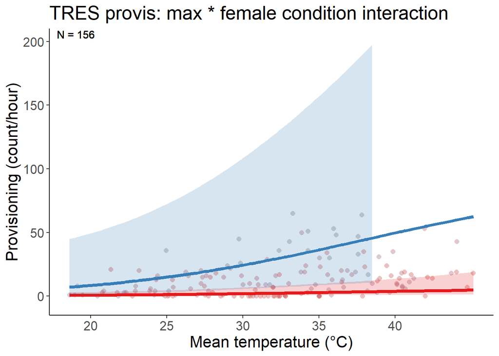

```r
data_tres_q2h2 = dplyr::filter(p,!is.na(mean_temp),
                               !is.na(female_condition),
                                  # !is.na(julian_date),
                                  !is.na(mean_nestling_age),
                                  !is.na(brood_size),
                                  !is.na(tod_h),
                                  !is.na(site),
                                  !is.na(attempt_id),
                                  !is.na(year),
                                  species == "TRES"# ,
                                                # tod >= hms::as.hms('11:00:00', tz = "America/Los_Angeles"),
                                                # tod_end <= hms::as.hms('17:00:00',tz = "America/Los_Angeles"),
                                                # tod_end >= hms::as.hms('11:00:00', tz = "America/Los_Angeles")
                                                ) %>%
                        mutate(across(c(tod_h,mean_temp,female_condition,julian_date,mean_nestling_age,brood_size),
                                                    ~ scale(.x)[,1],
                                                    .names = "{.col}_scaled"))


mean_temp_tres_q2h2 <- mean(data_tres_q2h2 %>% pull(mean_temp))
sd_temp_tres_q2h2 <- sd(data_tres_q2h2 %>% pull(mean_temp))


temp_trans_tres_q2h2 <- trans_new("temp_trans_tres_q2h2",
                             transform = function(x){(x * sd_temp_tres_q2h2) + mean_temp_tres_q2h2},
                             inverse = function(x){x})

(figq2h2_tres <- predict_response(m_tres_q2h2,terms = c("mean_temp_scaled [all]","female_condition_scaled [-2,2]"),margin = "marginalmeans") %>%
    plot(line_size = 1.5,alpha = .2,show_data = TRUE,limit_range = TRUE) +
    # aes(linetype = .data[["group"]]) +
    theme_classic() +
    # facet_wrap(~ group, ncol = 2) +
    xlab("Mean temperature (\u00b0C)") +
    ylab("Provisioning (count/hour)") +
    # scale_fill_viridis(discrete = TRUE) +
    # scale_color_viridis(discrete = TRUE) +
    theme(text = element_text(size = 16)) +
    labs(title =  "TRES provis: max * female condition interaction") +
    scale_x_continuous(trans = temp_trans_tres_q2h2,
                       breaks = c((20-mean_temp_tres_q2h2)/sd_temp_tres_q2h2,
                                  (25-mean_temp_tres_q2h2)/sd_temp_tres_q2h2,
                                  (30-mean_temp_tres_q2h2)/sd_temp_tres_q2h2,
                                  (35-mean_temp_tres_q2h2)/sd_temp_tres_q2h2,
                                  (40-mean_temp_tres_q2h2)/sd_temp_tres_q2h2),
                       # breaks = c(20,30,40,50),
                       # labels = c("20","30","40","50"),
                       # limits = c((15-mean(g$meanmaxtempI,na.rm = TRUE))/sd(g$meanmaxtempI,na.rm = TRUE),
                       #            (55-mean(g$meanmaxtempI,na.rm = TRUE))/sd(g$meanmaxtempI,na.rm = TRUE))
                       # limits = c(18,5)
    ) +
    # scale_linetype_manual(values = c("Forest" = "solid","Orchard" = "dashed","Grassland" = "solid","Row crop" = "dotted")) +
    ylim(-5,200) +
    geom_text(data = dat_text_tres_q2h2, mapping = aes(x = -Inf, y = Inf,label = label),hjust = -.2, vjust = 1.2,inherit.aes = FALSE) +
    theme(legend.position = "none")
)
```

```r
ggsave("../figures/provisbymaxtempxhab_TRES_q2h2.png",plot =  figq2h2_tres, width = 10, height = 6.6)
```

So for TRES, when females are in better body condition, there’s more provisioning, and when it’s hot, there’s also more provisioning. But no interaction between the two.

## Q2H3

2. What mediates how responsive provisioning rates are to temperature?
3. (H3) Females with higher baseline cort will be less responsive to temperature - possibly because they are exposing themselves to suboptimal conditions

### WEBL

```r
m_WEBL <- glmmTMB(valid_detections ~ poly(mean_temp_scaled,2) * cort_s1_mother_scaled + poly(tod_h_scaled,2) + mean_nestling_age_scaled + brood_size_scaled + year_fct + (1|site:attempt_id),
           family = nbinom2(),
           ziformula = ~ 1,
           data = dplyr::filter(p,!is.na(mean_temp),
                                !is.na(cort_s1_mother),
                                  # !is.na(julian_date),
                                  !is.na(mean_nestling_age),
                                  !is.na(brood_size),
                                  !is.na(tod_h),
                                  !is.na(site),
                                  !is.na(attempt_id),
                                  !is.na(year),
                                  species == "WEBL"# ,
                                                # tod >= hms::as.hms('11:00:00', tz = "America/Los_Angeles"),
                                                # tod_end <= hms::as.hms('17:00:00',tz = "America/Los_Angeles"),
                                                # tod_end >= hms::as.hms('11:00:00', tz = "America/Los_Angeles")
                                                ) %>%
                        mutate(across(c(tod_h,mean_temp,cort_s1_mother,julian_date,mean_nestling_age,brood_size),
                                                    ~ scale(.x)[,1],
                                                    .names = "{.col}_scaled")),
           )

m_WEBL_linint <- glmmTMB(valid_detections ~ mean_temp_scaled * cort_s1_mother_scaled + poly(mean_temp_scaled,degree = 2) + poly(tod_h_scaled,2) + mean_nestling_age_scaled + brood_size_scaled + year_fct + (1|site:attempt_id),
           family = nbinom2(),
           ziformula = ~ 1,
           data = dplyr::filter(p,!is.na(mean_temp),
                                !is.na(cort_s1_mother),
                                  # !is.na(julian_date),
                                  !is.na(mean_nestling_age),
                                  !is.na(brood_size),
                                  !is.na(tod_h),
                                  !is.na(site),
                                  !is.na(attempt_id),
                                  !is.na(year),
                                  species == "WEBL"# ,
                                                # tod >= hms::as.hms('11:00:00', tz = "America/Los_Angeles"),
                                                # tod_end <= hms::as.hms('17:00:00',tz = "America/Los_Angeles"),
                                                # tod_end >= hms::as.hms('11:00:00', tz = "America/Los_Angeles")
                                                ) %>%
                        mutate(across(c(tod_h,mean_temp,cort_s1_mother,julian_date,mean_nestling_age,brood_size),
                                                    ~ scale(.x)[,1],
                                                    .names = "{.col}_scaled")),
           )
```

```
## dropping columns from rank-deficient conditional model: poly(mean_temp_scaled, degree = 2)1
```

```r
m_WEBL_noint <- glmmTMB(valid_detections ~ cort_s1_mother_scaled + poly(mean_temp_scaled,degree = 2) + poly(tod_h_scaled,2) + mean_nestling_age_scaled + brood_size_scaled + year_fct + (1|site:attempt_id),
           family = nbinom2(),
           ziformula = ~ 1,
           data = dplyr::filter(p,!is.na(mean_temp),
                                !is.na(cort_s1_mother),
                                  # !is.na(julian_date),
                                  !is.na(mean_nestling_age),
                                  !is.na(brood_size),
                                  !is.na(tod_h),
                                  !is.na(site),
                                  !is.na(attempt_id),
                                  !is.na(year),
                                  species == "WEBL"# ,
                                                # tod >= hms::as.hms('11:00:00', tz = "America/Los_Angeles"),
                                                # tod_end <= hms::as.hms('17:00:00',tz = "America/Los_Angeles"),
                                                # tod_end >= hms::as.hms('11:00:00', tz = "America/Los_Angeles")
                                                ) %>%
                        mutate(across(c(tod_h,mean_temp,cort_s1_mother,julian_date,mean_nestling_age,brood_size),
                                                    ~ scale(.x)[,1],
                                                    .names = "{.col}_scaled")),
           )




c <- anova(m_WEBL,m_WEBL_linint,m_WEBL_noint) %>% tibble() %>% mutate(Model = c("No temp * LC interaction","Linear temp * LC interaction","Squared temp * LC interaction"),.before = Df)

(tab <- c %>%
  as.tibble() %>%
  mutate(across(where(is.numeric),~round(.x,digits = 4)),
         P = `Pr(>Chisq)`) %>%
  dplyr::select(Model,AIC,Chisq,P) %>%
  mutate(across(c(AIC,Chisq), ~ round(.x, digits = 2)),
         P = if_else(P < 0.001,"<0.001",as.character(P))) %>% gt())
```

| Model | AIC | Chisq | P |
| --- | --- | --- | --- |
| No temp * LC interaction | 816.04 | NA | NA |
| Linear temp * LC interaction | 815.39 | 2.65 | 0.1033 |
| Squared temp * LC interaction | 808.35 | 9.04 | 0.0026 |

```r
gtsave(tab,"../figures/int_tab_provis_ch3_q2h3_webl.html")

summary(m_WEBL)
```

```
##  Family: nbinom2  ( log )
## Formula:
## valid_detections ~ poly(mean_temp_scaled, 2) * cort_s1_mother_scaled +
##     poly(tod_h_scaled, 2) + mean_nestling_age_scaled + brood_size_scaled +
##     year_fct + (1 | site:attempt_id)
## Zero inflation:                    ~1
## Data:
## dplyr::filter(p, !is.na(mean_temp), !is.na(cort_s1_mother), !is.na(mean_nestling_age),
##     !is.na(brood_size), !is.na(tod_h), !is.na(site), !is.na(attempt_id),
##     !is.na(year), species == "WEBL") %>% mutate(across(c(tod_h,
##     mean_temp, cort_s1_mother, julian_date, mean_nestling_age,
##     brood_size), ~scale(.x)[, 1], .names = "{.col}_scaled"))
##
##      AIC      BIC   logLik deviance df.resid
##    808.3    849.8   -390.2    780.3      129
##
## Random effects:
##
## Conditional model:
##  Groups          Name        Variance Std.Dev.
##  site:attempt_id (Intercept) 0.5203   0.7213
## Number of obs: 143, groups:  site:attempt_id, 12
##
## Dispersion parameter for nbinom2 family (): 6.56
##
## Conditional model:
##                                                  Estimate Std. Error z value
## (Intercept)                                       1.92141    0.37787   5.085
## poly(mean_temp_scaled, 2)1                       -2.54983    1.39333  -1.830
## poly(mean_temp_scaled, 2)2                       -1.71784    1.02001  -1.684
## cort_s1_mother_scaled                             0.13361    0.28048   0.476
## poly(tod_h_scaled, 2)1                           -0.93472    0.57475  -1.626
## poly(tod_h_scaled, 2)2                           -0.38947    0.87024  -0.448
## mean_nestling_age_scaled                          0.07367    0.07381   0.998
## brood_size_scaled                                 0.56040    0.24741   2.265
## year_fct2023                                     -0.72290    0.55492  -1.303
## poly(mean_temp_scaled, 2)1:cort_s1_mother_scaled -0.30889    1.46071  -0.211
## poly(mean_temp_scaled, 2)2:cort_s1_mother_scaled  2.85001    0.93240   3.057
##                                                  Pr(>|z|)
## (Intercept)                                      3.68e-07 ***
## poly(mean_temp_scaled, 2)1                        0.06725 .
## poly(mean_temp_scaled, 2)2                        0.09216 .
## cort_s1_mother_scaled                             0.63382
## poly(tod_h_scaled, 2)1                            0.10388
## poly(tod_h_scaled, 2)2                            0.65448
## mean_nestling_age_scaled                          0.31825
## brood_size_scaled                                 0.02351 *
## year_fct2023                                      0.19268
## poly(mean_temp_scaled, 2)1:cort_s1_mother_scaled  0.83253
## poly(mean_temp_scaled, 2)2:cort_s1_mother_scaled  0.00224 **
## ---
## Signif. codes:  0 '***' 0.001 '**' 0.01 '*' 0.05 '.' 0.1 ' ' 1
##
## Zero-inflation model:
##             Estimate Std. Error z value Pr(>|z|)
## (Intercept)   -20.76    6231.92  -0.003    0.997
```

```r
summary(m_WEBL_noint)
```

```
##  Family: nbinom2  ( log )
## Formula:
## valid_detections ~ cort_s1_mother_scaled + poly(mean_temp_scaled,
##     degree = 2) + poly(tod_h_scaled, 2) + mean_nestling_age_scaled +
##     brood_size_scaled + year_fct + (1 | site:attempt_id)
## Zero inflation:                    ~1
## Data:
## dplyr::filter(p, !is.na(mean_temp), !is.na(cort_s1_mother), !is.na(mean_nestling_age),
##     !is.na(brood_size), !is.na(tod_h), !is.na(site), !is.na(attempt_id),
##     !is.na(year), species == "WEBL") %>% mutate(across(c(tod_h,
##     mean_temp, cort_s1_mother, julian_date, mean_nestling_age,
##     brood_size), ~scale(.x)[, 1], .names = "{.col}_scaled"))
##
##      AIC      BIC   logLik deviance df.resid
##    816.0    851.6   -396.0    792.0      131
##
## Random effects:
##
## Conditional model:
##  Groups          Name        Variance Std.Dev.
##  site:attempt_id (Intercept) 0.5529   0.7436
## Number of obs: 143, groups:  site:attempt_id, 12
##
## Dispersion parameter for nbinom2 family (): 5.51
##
## Conditional model:
##                                     Estimate Std. Error z value Pr(>|z|)
## (Intercept)                          2.01719    0.38317   5.264 1.41e-07 ***
## cort_s1_mother_scaled                0.11356    0.28093   0.404   0.6860
## poly(mean_temp_scaled, degree = 2)1 -5.15668    1.24159  -4.153 3.28e-05 ***
## poly(mean_temp_scaled, degree = 2)2 -0.57101    0.75527  -0.756   0.4496
## poly(tod_h_scaled, 2)1              -1.28785    0.59332  -2.171   0.0300 *
## poly(tod_h_scaled, 2)2              -1.00345    0.87601  -1.145   0.2520
## mean_nestling_age_scaled             0.07654    0.07667   0.998   0.3181
## brood_size_scaled                    0.52247    0.25191   2.074   0.0381 *
## year_fct2023                        -0.86461    0.56819  -1.522   0.1281
## ---
## Signif. codes:  0 '***' 0.001 '**' 0.01 '*' 0.05 '.' 0.1 ' ' 1
##
## Zero-inflation model:
##             Estimate Std. Error z value Pr(>|z|)
## (Intercept)   -19.99    4277.86  -0.005    0.996
```

```r
m_webl_q2h3 <- m_WEBL

check_zeroinflation(m_WEBL)
```

```
## # Check for zero-inflation
##
##    Observed zeros: 16
##   Predicted zeros: 13
##             Ratio: 0.81
```

```
## Model is underfitting zeros (probable zero-inflation) (p = 0.536).
```

```r
(t <- emtrends(m_webl_q2h3,specs = ~ cort_s1_mother_scaled, var = c("mean_temp_scaled"),max.degree = 1) %>% test() %>%
   mutate(across(where(is.numeric), ~ round(.x, digits = 3)),
          df = round(df),
          p.value = if_else(p.value == 0.000,"<0.001",as.character(p.value))) %>%
   rename(`Female condition` = "cort_s1_mother_scaled", `Max temp trend` = "mean_temp_scaled.trend",Df = "df", `Z-ratio` = "z.ratio", P = "p.value") %>%
   #group_by(degree) %>%
   gt())
```

| Female condition | Max temp trend | SE | Df | Z-ratio | P |
| --- | --- | --- | --- | --- | --- |
| 0 | -0.21 | 0.117 | Inf | -1.795 | 0.073 |

```r
joint_tests(m_webl_q2h3)
```

|  | model term | df1 | df2 | F.ratio | Chisq | p.value |
| --- | --- | --- | --- | --- | --- | --- |
| 1 | mean_temp_scaled | 1 | Inf | 3.204 | 3.204 | 0.07345694 |
| 3 | cort_s1_mother_scaled | 1 | Inf | 0.231 | 0.231 | 0.63086484 |
| 4 | tod_h_scaled | 1 | Inf | 2.455 | 2.455 | 0.11716257 |
| 5 | mean_nestling_age_scaled | 1 | Inf | 0.996 | 0.996 | 0.31824600 |
| 6 | brood_size_scaled | 1 | Inf | 5.130 | 5.130 | 0.02351027 |
| 7 | year_fct | 1 | Inf | 1.697 | 1.697 | 0.19267772 |
| 2 | mean_temp_scaled:cort_s1_mother_scaled | 1 | Inf | 0.073 | 0.073 | 0.78718655 |

```r
# gtsave(t,"../figures/weblprovistrend_ch3_q2h3.html")


ss_year_webl_provis <- m_webl_q2h3$frame %>%
  group_by(year_fct) %>%
  summarize(count_ind = n(),count_attempt = n_distinct(attempt_id)) %>%
  rowwise() %>%
  mutate(count = tibble(count_ind,count_attempt)) %>%
  dplyr::select(-c(count_ind, count_attempt)) %>%
  pivot_wider(values_from = count,names_from = year_fct) %>%
  as.tibble() %>%
  ungroup() %>%
  # mutate(`2021` = replace_na(`2021`,list(count_ind = 0,count_attempt = 0))) %>%
  mutate(Total = `2022` + `2023`) %>%
  rowwise() %>%
  mutate(`2022` = paste0(`2022`$count_ind,", ",`2022`$count_attempt),
         `2023` = paste0(`2023`$count_ind,", ",`2023`$count_attempt),
         Total = paste0(Total$count_ind,", ",Total$count_attempt)
  )

(t_ss_year_webl_provis <- ss_year_webl_provis %>% gt() %>%
    grand_summary_rows(fns = list(id = "Total") ~ {
      t <- str_split(.,", ",simplify = TRUE)
      t[,1] %>% as.numeric() %>% sum(na.rm = TRUE) %>% paste(t[,2] %>% as.numeric() %>% sum(na.rm = TRUE),sep = ", ")
    })
)
```

|  | 2022 | 2023 | Total |
| --- | --- | --- | --- |
|  | 88, 5 | 55, 7 | 143, 12 |
| Total | 88, 5 | 55, 7 | 143, 12 |

```r
t_ss_year_webl_provis %>% gtsave("../figures/ss_year_webl_provis_ch3.html")

samp <- m_webl_q2h3$frame %>% summarize(count = n())
samp %>% gt() %>% gtsave("../figures/ss_webl_provis_ch3.html")


dat_text_webl_q2h3 <- data.frame(
  label = paste("N =",samp$count),
  group   = factor(c("Forest","Orchard","Grassland","Row crop"))
)

## num nestboxes
m_webl_q2h3$frame %>% pull(attempt_id) %>% unique() %>% length()
```

```
## [1] 12
```

```
## Data points may overlap. Use the `jitter` argument to add some amount of
##   random variation to the location of data points and avoid overplotting.
```

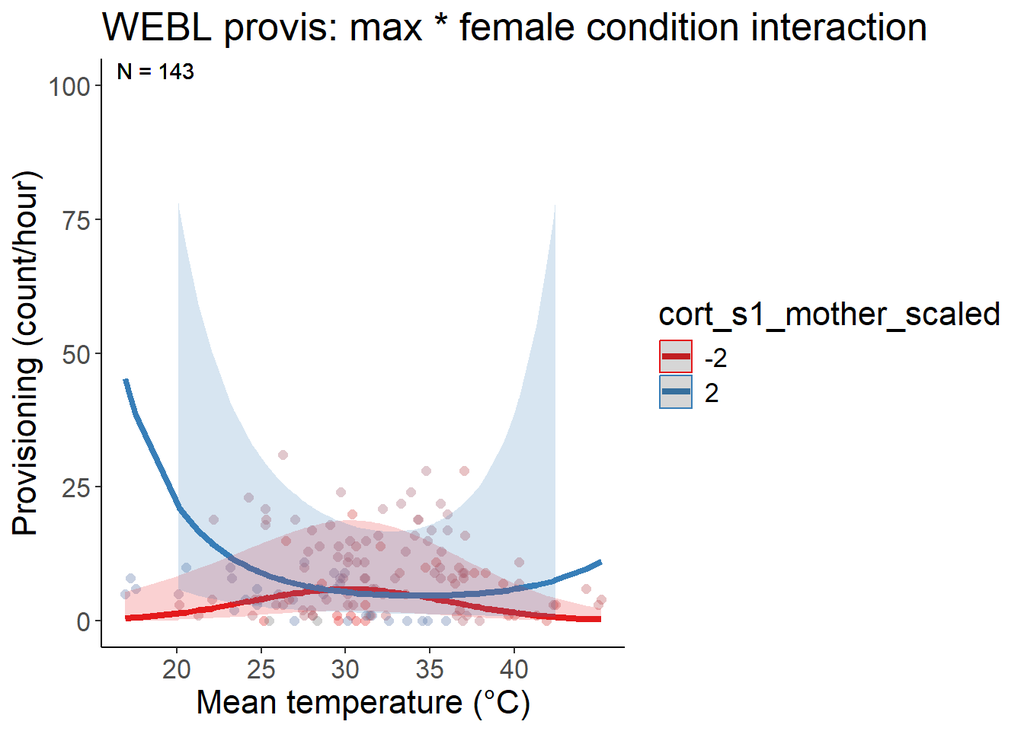

```r
data_webl_q2h3 = dplyr::filter(p,!is.na(mean_temp),
                               !is.na(cort_s1_mother),
                                  # !is.na(julian_date),
                                  !is.na(mean_nestling_age),
                                  !is.na(brood_size),
                                  !is.na(tod_h),
                                  !is.na(site),
                                  !is.na(attempt_id),
                                  !is.na(year),
                                  species == "WEBL"# ,
                                                # tod >= hms::as.hms('11:00:00', tz = "America/Los_Angeles"),
                                                # tod_end <= hms::as.hms('17:00:00',tz = "America/Los_Angeles"),
                                                # tod_end >= hms::as.hms('11:00:00', tz = "America/Los_Angeles")
                                                ) %>%
                        mutate(across(c(tod_h,mean_temp,cort_s1_mother,julian_date,mean_nestling_age,brood_size),
                                                    ~ scale(.x)[,1],
                                                    .names = "{.col}_scaled"))


mean_temp_webl_q2h3 <- mean(data_webl_q2h3 %>% pull(mean_temp))
sd_temp_webl_q2h3 <- sd(data_webl_q2h3 %>% pull(mean_temp))


temp_trans_webl_q2h3 <- trans_new("temp_trans_webl_q2h3",
                             transform = function(x){(x * sd_temp_webl_q2h3) + mean_temp_webl_q2h3},
                             inverse = function(x){x})

(figq2h3_webl <- predict_response(m_webl_q2h3,terms = c("mean_temp_scaled [all]","cort_s1_mother_scaled [-2,2]"),margin = "marginalmeans") %>%
    plot(line_size = 1.5,alpha = .2,show_data = TRUE,limit_range = TRUE) +
    # aes(linetype = .data[["group"]]) +
    theme_classic() +
    # facet_wrap(~ group, ncol = 2) +
    xlab("Mean temperature (\u00b0C)") +
    ylab("Provisioning (count/hour)") +
    # scale_fill_viridis(discrete = TRUE) +
    # scale_color_viridis(discrete = TRUE) +
    theme(text = element_text(size = 16)) +
    labs(title =  "WEBL provis: max * female condition interaction") +
    scale_x_continuous(trans = temp_trans_webl_q2h3,
                       breaks = c((20-mean_temp_webl_q2h3)/sd_temp_webl_q2h3,
                                  (25-mean_temp_webl_q2h3)/sd_temp_webl_q2h3,
                                  (30-mean_temp_webl_q2h3)/sd_temp_webl_q2h3,
                                  (35-mean_temp_webl_q2h3)/sd_temp_webl_q2h3,
                                  (40-mean_temp_webl_q2h3)/sd_temp_webl_q2h3),
                       # breaks = c(20,30,40,50),
                       # labels = c("20","30","40","50"),
                       # limits = c((15-mean(g$meanmaxtempI,na.rm = TRUE))/sd(g$meanmaxtempI,na.rm = TRUE),
                       #            (55-mean(g$meanmaxtempI,na.rm = TRUE))/sd(g$meanmaxtempI,na.rm = TRUE))
                       # limits = c(18,5)
    ) +
    # scale_linetype_manual(values = c("Forest" = "solid","Orchard" = "dashed","Grassland" = "solid","Row crop" = "dotted")) +
    ylim(0,100) +
    geom_text(data = dat_text_webl_q2h3, mapping = aes(x = -Inf, y = Inf,label = label),hjust = -.2, vjust = 1.2,inherit.aes = FALSE)# +
    # theme(legend.position = "none")
)
```

```r
ggsave("../figures/provisbymaxtempxhab_WEBL_q2h3.png",plot =  figq2h3_webl, width = 10, height = 6.6)
```

Females with lower cort are “peakier” (more responsive to temp) than females with higher baseline cort

### TRES

```r
m_TRES <- glmmTMB(valid_detections ~ poly(mean_temp_scaled,2) * cort_s1_mother_scaled + poly(tod_h_scaled,2) + mean_nestling_age_scaled + brood_size_scaled + year_fct + (1|site:attempt_id),
           family = nbinom2(),
           ziformula = ~ 1,
           data = dplyr::filter(p,!is.na(mean_temp),
                                !is.na(cort_s1_mother),
                                  # !is.na(julian_date),
                                  !is.na(mean_nestling_age),
                                  !is.na(brood_size),
                                  !is.na(tod_h),
                                  !is.na(site),
                                  !is.na(attempt_id),
                                  !is.na(year),
                                  species == "TRES"# ,
                                                # tod >= hms::as.hms('11:00:00', tz = "America/Los_Angeles"),
                                                # tod_end <= hms::as.hms('17:00:00',tz = "America/Los_Angeles"),
                                                # tod_end >= hms::as.hms('11:00:00', tz = "America/Los_Angeles")
                                                ) %>%
                        mutate(across(c(tod_h,mean_temp,cort_s1_mother,julian_date,mean_nestling_age,brood_size),
                                                    ~ scale(.x)[,1],
                                                    .names = "{.col}_scaled")),
           )

m_TRES_linint <- glmmTMB(valid_detections ~ mean_temp_scaled * cort_s1_mother_scaled + poly(mean_temp_scaled,degree = 2) + poly(tod_h_scaled,2) + mean_nestling_age_scaled + brood_size_scaled + year_fct + (1|site:attempt_id),
           family = nbinom2(),
           ziformula = ~ 1,
           data = dplyr::filter(p,!is.na(mean_temp),
                                !is.na(cort_s1_mother),
                                  # !is.na(julian_date),
                                  !is.na(mean_nestling_age),
                                  !is.na(brood_size),
                                  !is.na(tod_h),
                                  !is.na(site),
                                  !is.na(attempt_id),
                                  !is.na(year),
                                  species == "TRES"# ,
                                                # tod >= hms::as.hms('11:00:00', tz = "America/Los_Angeles"),
                                                # tod_end <= hms::as.hms('17:00:00',tz = "America/Los_Angeles"),
                                                # tod_end >= hms::as.hms('11:00:00', tz = "America/Los_Angeles")
                                                ) %>%
                        mutate(across(c(tod_h,mean_temp,cort_s1_mother,julian_date,mean_nestling_age,brood_size),
                                                    ~ scale(.x)[,1],
                                                    .names = "{.col}_scaled")),
           )
```

```
## dropping columns from rank-deficient conditional model: poly(mean_temp_scaled, degree = 2)1
```

```r
m_TRES_noint <- glmmTMB(valid_detections ~ cort_s1_mother_scaled + poly(mean_temp_scaled,degree = 2) + poly(tod_h_scaled,2) + mean_nestling_age_scaled + brood_size_scaled + year_fct + (1|site:attempt_id),
           family = nbinom2(),
           ziformula = ~ 1,
           data = dplyr::filter(p,!is.na(mean_temp),
                                !is.na(cort_s1_mother),
                                  # !is.na(julian_date),
                                  !is.na(mean_nestling_age),
                                  !is.na(brood_size),
                                  !is.na(tod_h),
                                  !is.na(site),
                                  !is.na(attempt_id),
                                  !is.na(year),
                                  species == "TRES"# ,
                                                # tod >= hms::as.hms('11:00:00', tz = "America/Los_Angeles"),
                                                # tod_end <= hms::as.hms('17:00:00',tz = "America/Los_Angeles"),
                                                # tod_end >= hms::as.hms('11:00:00', tz = "America/Los_Angeles")
                                                ) %>%
                        mutate(across(c(tod_h,mean_temp,cort_s1_mother,julian_date,mean_nestling_age,brood_size),
                                                    ~ scale(.x)[,1],
                                                    .names = "{.col}_scaled")),
           )




c <- anova(m_TRES,m_TRES_linint,m_TRES_noint) %>% tibble() %>% mutate(Model = c("No temp * LC interaction","Linear temp * LC interaction","Squared temp * LC interaction"),.before = Df)

(tab <- c %>%
  as.tibble() %>%
  mutate(across(where(is.numeric),~round(.x,digits = 4)),
         P = `Pr(>Chisq)`) %>%
  dplyr::select(Model,AIC,Chisq,P) %>%
  mutate(across(c(AIC,Chisq), ~ round(.x, digits = 2)),
         P = if_else(P < 0.001,"<0.001",as.character(P))) %>% gt())
```

| Model | AIC | Chisq | P |
| --- | --- | --- | --- |
| No temp * LC interaction | 983.92 | NA | NA |
| Linear temp * LC interaction | 985.92 | 0.00 | 0.9526 |
| Squared temp * LC interaction | 985.38 | 2.53 | 0.1115 |

```r
gtsave(tab,"../figures/int_tab_provis_ch3_q2h3_tres.html")

summary(m_TRES_linint)
```

```
##  Family: nbinom2  ( log )
## Formula:
## valid_detections ~ mean_temp_scaled * cort_s1_mother_scaled +
##     poly(mean_temp_scaled, degree = 2) + poly(tod_h_scaled, 2) +
##     mean_nestling_age_scaled + brood_size_scaled + year_fct +
##     (1 | site:attempt_id)
## Zero inflation:                    ~1
## Data:
## dplyr::filter(p, !is.na(mean_temp), !is.na(cort_s1_mother), !is.na(mean_nestling_age),
##     !is.na(brood_size), !is.na(tod_h), !is.na(site), !is.na(attempt_id),
##     !is.na(year), species == "TRES") %>% mutate(across(c(tod_h,
##     mean_temp, cort_s1_mother, julian_date, mean_nestling_age,
##     brood_size), ~scale(.x)[, 1], .names = "{.col}_scaled"))
##
##      AIC      BIC   logLik deviance df.resid
##    985.9   1024.8   -480.0    959.9      134
##
## Random effects:
##
## Conditional model:
##  Groups          Name        Variance Std.Dev.
##  site:attempt_id (Intercept) 0.6425   0.8016
## Number of obs: 147, groups:  site:attempt_id, 13
##
## Dispersion parameter for nbinom2 family (): 2.81
##
## Conditional model:
##                                         Estimate Std. Error z value Pr(>|z|)
## (Intercept)                             2.206000   0.395169   5.582 2.37e-08
## mean_temp_scaled                        0.507554   0.187792   2.703  0.00688
## cort_s1_mother_scaled                  -0.808373   0.291494  -2.773  0.00555
## poly(mean_temp_scaled, degree = 2)1           NA         NA      NA       NA
## poly(mean_temp_scaled, degree = 2)2    -0.340622   1.068655  -0.319  0.74992
## poly(tod_h_scaled, 2)1                 -0.872169   0.887263  -0.983  0.32561
## poly(tod_h_scaled, 2)2                  3.455995   1.507866   2.292  0.02191
## mean_nestling_age_scaled                0.035264   0.108087   0.326  0.74423
## brood_size_scaled                       0.390533   0.318146   1.228  0.21962
## year_fct2023                            0.019125   0.594236   0.032  0.97432
## mean_temp_scaled:cort_s1_mother_scaled  0.007425   0.125067   0.059  0.95266
##
## (Intercept)                            ***
## mean_temp_scaled                       **
## cort_s1_mother_scaled                  **
## poly(mean_temp_scaled, degree = 2)1
## poly(mean_temp_scaled, degree = 2)2
## poly(tod_h_scaled, 2)1
## poly(tod_h_scaled, 2)2                 *
## mean_nestling_age_scaled
## brood_size_scaled
## year_fct2023
## mean_temp_scaled:cort_s1_mother_scaled
## ---
## Signif. codes:  0 '***' 0.001 '**' 0.01 '*' 0.05 '.' 0.1 ' ' 1
##
## Zero-inflation model:
##             Estimate Std. Error z value Pr(>|z|)
## (Intercept)  -2.0408     0.3106   -6.57 5.04e-11 ***
## ---
## Signif. codes:  0 '***' 0.001 '**' 0.01 '*' 0.05 '.' 0.1 ' ' 1
```

```r
summary(m_TRES_noint)
```

```
##  Family: nbinom2  ( log )
## Formula:
## valid_detections ~ cort_s1_mother_scaled + poly(mean_temp_scaled,
##     degree = 2) + poly(tod_h_scaled, 2) + mean_nestling_age_scaled +
##     brood_size_scaled + year_fct + (1 | site:attempt_id)
## Zero inflation:                    ~1
## Data:
## dplyr::filter(p, !is.na(mean_temp), !is.na(cort_s1_mother), !is.na(mean_nestling_age),
##     !is.na(brood_size), !is.na(tod_h), !is.na(site), !is.na(attempt_id),
##     !is.na(year), species == "TRES") %>% mutate(across(c(tod_h,
##     mean_temp, cort_s1_mother, julian_date, mean_nestling_age,
##     brood_size), ~scale(.x)[, 1], .names = "{.col}_scaled"))
##
##      AIC      BIC   logLik deviance df.resid
##    983.9   1019.8   -480.0    959.9      135
##
## Random effects:
##
## Conditional model:
##  Groups          Name        Variance Std.Dev.
##  site:attempt_id (Intercept) 0.6436   0.8022
## Number of obs: 147, groups:  site:attempt_id, 13
##
## Dispersion parameter for nbinom2 family (): 2.81
##
## Conditional model:
##                                     Estimate Std. Error z value Pr(>|z|)
## (Intercept)                          2.20376    0.39350   5.600 2.14e-08 ***
## cort_s1_mother_scaled               -0.81092    0.28850  -2.811  0.00494 **
## poly(mean_temp_scaled, degree = 2)1  6.13266    2.26814   2.704  0.00685 **
## poly(mean_temp_scaled, degree = 2)2 -0.36200    1.00554  -0.360  0.71885
## poly(tod_h_scaled, 2)1              -0.86643    0.88182  -0.983  0.32583
## poly(tod_h_scaled, 2)2               3.47050    1.48774   2.333  0.01966 *
## mean_nestling_age_scaled             0.03415    0.10644   0.321  0.74837
## brood_size_scaled                    0.39065    0.31835   1.227  0.21978
## year_fct2023                         0.02036    0.59410   0.034  0.97267
## ---
## Signif. codes:  0 '***' 0.001 '**' 0.01 '*' 0.05 '.' 0.1 ' ' 1
##
## Zero-inflation model:
##             Estimate Std. Error z value Pr(>|z|)
## (Intercept)  -2.0410     0.3104  -6.575 4.85e-11 ***
## ---
## Signif. codes:  0 '***' 0.001 '**' 0.01 '*' 0.05 '.' 0.1 ' ' 1
```

```r
m_tres_q2h3 <- m_TRES_noint

check_zeroinflation(m_TRES_noint)
```

```
## # Check for zero-inflation
##
##    Observed zeros: 29
##   Predicted zeros: 27
##             Ratio: 0.93
```

```
## Model seems ok, ratio of observed and predicted zeros is within the
##   tolerance range (p = 0.776).
```

```r
(t <- emtrends(m_tres_q2h3,specs = ~ cort_s1_mother_scaled, var = c("mean_temp_scaled"),max.degree = 1) %>% test() %>%
   mutate(across(where(is.numeric), ~ round(.x, digits = 3)),
          df = round(df),
          p.value = if_else(p.value == 0.000,"<0.001",as.character(p.value))) %>%
   rename(`Female condition` = "cort_s1_mother_scaled", `Max temp trend` = "mean_temp_scaled.trend",Df = "df", `Z-ratio` = "z.ratio", P = "p.value") %>%
   #group_by(degree) %>%
   gt())
```

| Female condition | Max temp trend | SE | Df | Z-ratio | P |
| --- | --- | --- | --- | --- | --- |
| 0 | 0.503 | 0.185 | Inf | 2.719 | 0.007 |

```r
joint_tests(m_tres_q2h3)
```

|  | model term | df1 | df2 | F.ratio | Chisq | p.value |
| --- | --- | --- | --- | --- | --- | --- |
| 1 | cort_s1_mother_scaled | 1 | Inf | 7.901 | 7.901 | 0.004941718 |
| 2 | mean_temp_scaled | 1 | Inf | 7.392 | 7.392 | 0.006550488 |
| 3 | tod_h_scaled | 1 | Inf | 2.006 | 2.006 | 0.156714511 |
| 4 | mean_nestling_age_scaled | 1 | Inf | 0.103 | 0.103 | 0.748373099 |
| 5 | brood_size_scaled | 1 | Inf | 1.506 | 1.506 | 0.219780853 |
| 6 | year_fct | 1 | Inf | 0.001 | 0.001 | 0.972666287 |

```r
# gtsave(t,"../figures/tresprovistrend_ch3_q2h3.html")


ss_year_tres_provis <- m_tres_q2h3$frame %>%
  group_by(year_fct) %>%
  summarize(count_ind = n(),count_attempt = n_distinct(attempt_id)) %>%
  rowwise() %>%
  mutate(count = tibble(count_ind,count_attempt)) %>%
  dplyr::select(-c(count_ind, count_attempt)) %>%
  pivot_wider(values_from = count,names_from = year_fct) %>%
  as.tibble() %>%
  ungroup() %>%
  # mutate(`2021` = replace_na(`2021`,list(count_ind = 0,count_attempt = 0))) %>%
  mutate(Total = `2022` + `2023`) %>%
  rowwise() %>%
  mutate(`2022` = paste0(`2022`$count_ind,", ",`2022`$count_attempt),
         `2023` = paste0(`2023`$count_ind,", ",`2023`$count_attempt),
         Total = paste0(Total$count_ind,", ",Total$count_attempt)
  )

(t_ss_year_tres_provis <- ss_year_tres_provis %>% gt() %>%
    grand_summary_rows(fns = list(id = "Total") ~ {
      t <- str_split(.,", ",simplify = TRUE)
      t[,1] %>% as.numeric() %>% sum(na.rm = TRUE) %>% paste(t[,2] %>% as.numeric() %>% sum(na.rm = TRUE),sep = ", ")
    })
)
```

|  | 2022 | 2023 | Total |
| --- | --- | --- | --- |
|  | 68, 6 | 79, 7 | 147, 13 |
| Total | 68, 6 | 79, 7 | 147, 13 |

```r
t_ss_year_tres_provis %>% gtsave("../figures/ss_year_tres_provis_ch3_q2h3.html")

samp <- m_tres_q2h3$frame %>% summarize(count = n())
samp %>% gt() %>% gtsave("../figures/ss_tres_provis_ch_q2h3.html")


dat_text_tres_q2h3 <- data.frame(
  label = paste("N =",samp$count),
  group   = factor(c("Forest","Orchard","Grassland","Row crop"))
)

## num nestboxes
m_tres_q2h3$frame %>% pull(attempt_id) %>% unique() %>% length()
```

```
## [1] 13
```

```
## Data points may overlap. Use the `jitter` argument to add some amount of
##   random variation to the location of data points and avoid overplotting.
```

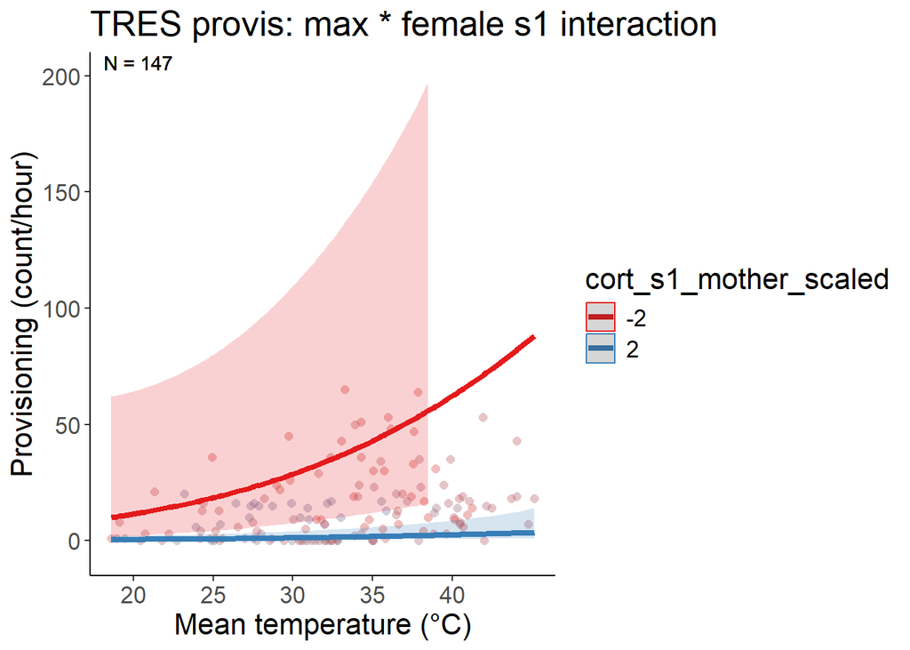

```r
data_tres_q2h3 = dplyr::filter(p,!is.na(mean_temp),
                               !is.na(cort_s1_mother),
                                  # !is.na(julian_date),
                                  !is.na(mean_nestling_age),
                                  !is.na(brood_size),
                                  !is.na(tod_h),
                                  !is.na(site),
                                  !is.na(attempt_id),
                                  !is.na(year),
                                  species == "TRES"# ,
                                                # tod >= hms::as.hms('11:00:00', tz = "America/Los_Angeles"),
                                                # tod_end <= hms::as.hms('17:00:00',tz = "America/Los_Angeles"),
                                                # tod_end >= hms::as.hms('11:00:00', tz = "America/Los_Angeles")
                                                ) %>%
                        mutate(across(c(tod_h,mean_temp,cort_s1_mother,julian_date,mean_nestling_age,brood_size),
                                                    ~ scale(.x)[,1],
                                                    .names = "{.col}_scaled"))


mean_temp_tres_q2h3 <- mean(data_tres_q2h3 %>% pull(mean_temp))
sd_temp_tres_q2h3 <- sd(data_tres_q2h3 %>% pull(mean_temp))


temp_trans_tres_q2h3 <- trans_new("temp_trans_tres_q2h3",
                             transform = function(x){(x * sd_temp_tres_q2h3) + mean_temp_tres_q2h3},
                             inverse = function(x){x})

(figq2h3_tres <- predict_response(m_tres_q2h3,terms = c("mean_temp_scaled [all]","cort_s1_mother_scaled [-2,2]"),margin = "marginalmeans") %>%
    plot(line_size = 1.5,alpha = .2,show_data = TRUE,limit_range = TRUE) +
    # aes(linetype = .data[["group"]]) +
    theme_classic() +
    # facet_wrap(~ group, ncol = 2) +
    xlab("Mean temperature (\u00b0C)") +
    ylab("Provisioning (count/hour)") +
    # scale_fill_viridis(discrete = TRUE) +
    # scale_color_viridis(discrete = TRUE) +
    theme(text = element_text(size = 16)) +
    labs(title =  "TRES provis: max * female s1 interaction") +
    scale_x_continuous(trans = temp_trans_tres_q2h3,
                       breaks = c((20-mean_temp_tres_q2h3)/sd_temp_tres_q2h3,
                                  (25-mean_temp_tres_q2h3)/sd_temp_tres_q2h3,
                                  (30-mean_temp_tres_q2h3)/sd_temp_tres_q2h3,
                                  (35-mean_temp_tres_q2h3)/sd_temp_tres_q2h3,
                                  (40-mean_temp_tres_q2h3)/sd_temp_tres_q2h3),
                       # breaks = c(20,30,40,50),
                       # labels = c("20","30","40","50"),
                       # limits = c((15-mean(g$meanmaxtempI,na.rm = TRUE))/sd(g$meanmaxtempI,na.rm = TRUE),
                       #            (55-mean(g$meanmaxtempI,na.rm = TRUE))/sd(g$meanmaxtempI,na.rm = TRUE))
                       # limits = c(18,5)
    ) +
    # scale_linetype_manual(values = c("Forest" = "solid","Orchard" = "dashed","Grassland" = "solid","Row crop" = "dotted")) +
    ylim(-5,200) +
    geom_text(data = dat_text_tres_q2h3, mapping = aes(x = -Inf, y = Inf,label = label),hjust = -.2, vjust = 1.2,inherit.aes = FALSE)# +
    #theme(legend.position = "none")
)
```

```r
ggsave("../figures/provisbymaxtempxhab_TRES_q2h3.png",plot =  figq2h3_tres, width = 10, height = 6.6)
```

Females with lower cort provision more overall, but the interaction is not significant.

## Q2H4

2. What mediates how responsive provisioning rates are to temperature? D. (H4) Females with higher stress-induced cort will be more responsive to temperature because they have been experiencing their environment as stressful, and therefore may not have extra energy to put towards thermoregulation during hot periods.

### WEBL

```r
m_WEBL <- glmmTMB(valid_detections ~ poly(mean_temp_scaled,2) * cort_s2_mother_scaled + poly(tod_h_scaled,2) + mean_nestling_age_scaled + brood_size_scaled + year_fct + (1|site/attempt_id),
           family = nbinom2(),
           ziformula = ~ 1,
           data = dplyr::filter(p,!is.na(mean_temp),
                                !is.na(cort_s2_mother),
                                  # !is.na(julian_date),
                                  !is.na(mean_nestling_age),
                                  !is.na(brood_size),
                                  !is.na(tod_h),
                                  !is.na(site),
                                  !is.na(attempt_id),
                                  !is.na(year),
                                  species == "WEBL"# ,
                                                # tod >= hms::as.hms('11:00:00', tz = "America/Los_Angeles"),
                                                # tod_end <= hms::as.hms('17:00:00',tz = "America/Los_Angeles"),
                                                # tod_end >= hms::as.hms('11:00:00', tz = "America/Los_Angeles")
                                                ) %>%
                        mutate(across(c(tod_h,mean_temp,cort_s2_mother,julian_date,mean_nestling_age,brood_size),
                                                    ~ scale(.x)[,1],
                                                    .names = "{.col}_scaled")),
           )

m_WEBL_linint <- glmmTMB(valid_detections ~ mean_temp_scaled * cort_s2_mother_scaled + poly(mean_temp_scaled,degree = 2) + poly(tod_h_scaled,2) + mean_nestling_age_scaled + brood_size_scaled + year_fct + (1|site/attempt_id),
           family = nbinom2(),
           ziformula = ~ 1,
           data = dplyr::filter(p,!is.na(mean_temp),
                                !is.na(cort_s2_mother),
                                  # !is.na(julian_date),
                                  !is.na(mean_nestling_age),
                                  !is.na(brood_size),
                                  !is.na(tod_h),
                                  !is.na(site),
                                  !is.na(attempt_id),
                                  !is.na(year),
                                  species == "WEBL"# ,
                                                # tod >= hms::as.hms('11:00:00', tz = "America/Los_Angeles"),
                                                # tod_end <= hms::as.hms('17:00:00',tz = "America/Los_Angeles"),
                                                # tod_end >= hms::as.hms('11:00:00', tz = "America/Los_Angeles")
                                                ) %>%
                        mutate(across(c(tod_h,mean_temp,cort_s2_mother,julian_date,mean_nestling_age,brood_size),
                                                    ~ scale(.x)[,1],
                                                    .names = "{.col}_scaled")),
           )
```

```
## dropping columns from rank-deficient conditional model: poly(mean_temp_scaled, degree = 2)1
```

```r
m_WEBL_noint <- glmmTMB(valid_detections ~ cort_s2_mother_scaled + poly(mean_temp_scaled,degree = 2) + poly(tod_h_scaled,2) + mean_nestling_age_scaled + brood_size_scaled + year_fct + (1|site/attempt_id),
           family = nbinom2(),
           ziformula = ~ 1,
           data = dplyr::filter(p,!is.na(mean_temp),
                                !is.na(cort_s2_mother),
                                  # !is.na(julian_date),
                                  !is.na(mean_nestling_age),
                                  !is.na(brood_size),
                                  !is.na(tod_h),
                                  !is.na(site),
                                  !is.na(attempt_id),
                                  !is.na(year),
                                  species == "WEBL"# ,
                                                # tod >= hms::as.hms('11:00:00', tz = "America/Los_Angeles"),
                                                # tod_end <= hms::as.hms('17:00:00',tz = "America/Los_Angeles"),
                                                # tod_end >= hms::as.hms('11:00:00', tz = "America/Los_Angeles")
                                                ) %>%
                        mutate(across(c(tod_h,mean_temp,cort_s2_mother,julian_date,mean_nestling_age,brood_size),
                                                    ~ scale(.x)[,1],
                                                    .names = "{.col}_scaled")),
           )
c <- anova(m_WEBL,m_WEBL_linint,m_WEBL_noint) %>% tibble() %>% mutate(Model = c("No temp * LC interaction","Linear temp * LC interaction","Squared temp * LC interaction"),.before = Df)

(tab <- c %>%
  as.tibble() %>%
  mutate(across(where(is.numeric),~round(.x,digits = 4)),
         P = `Pr(>Chisq)`) %>%
  dplyr::select(Model,AIC,Chisq,P) %>%
  mutate(across(c(AIC,Chisq), ~ round(.x, digits = 2)),
         P = if_else(P < 0.001,"<0.001",as.character(P))) %>% gt())
```

| Model | AIC | Chisq | P |
| --- | --- | --- | --- |
| No temp * LC interaction | NA | NA | NA |
| Linear temp * LC interaction | 866.20 | NA | NA |
| Squared temp * LC interaction | 865.77 | 2.43 | 0.1188 |

```r
gtsave(tab,"../figures/int_tab_provis_ch3_q4h2_webl.html")

summary(m_WEBL)
```

```
##  Family: nbinom2  ( log )
## Formula:
## valid_detections ~ poly(mean_temp_scaled, 2) * cort_s2_mother_scaled +
##     poly(tod_h_scaled, 2) + mean_nestling_age_scaled + brood_size_scaled +
##     year_fct + (1 | site/attempt_id)
## Zero inflation:                    ~1
## Data:
## dplyr::filter(p, !is.na(mean_temp), !is.na(cort_s2_mother), !is.na(mean_nestling_age),
##     !is.na(brood_size), !is.na(tod_h), !is.na(site), !is.na(attempt_id),
##     !is.na(year), species == "WEBL") %>% mutate(across(c(tod_h,
##     mean_temp, cort_s2_mother, julian_date, mean_nestling_age,
##     brood_size), ~scale(.x)[, 1], .names = "{.col}_scaled"))
##
##      AIC      BIC   logLik deviance df.resid
##    865.8    911.0   -417.9    835.8      136
##
## Random effects:
##
## Conditional model:
##  Groups          Name        Variance  Std.Dev.
##  attempt_id:site (Intercept) 5.681e-01 7.537e-01
##  site            (Intercept) 3.564e-17 5.970e-09
## Number of obs: 151, groups:  attempt_id:site, 12; site, 3
##
## Dispersion parameter for nbinom2 family (): 5.97
##
## Conditional model:
##                                                  Estimate Std. Error z value
## (Intercept)                                       2.07263    0.35405   5.854
## poly(mean_temp_scaled, 2)1                       -5.58154    1.23210  -4.530
## poly(mean_temp_scaled, 2)2                       -0.02609    0.75915  -0.034
## cort_s2_mother_scaled                            -0.10078    0.24395  -0.413
## poly(tod_h_scaled, 2)1                           -1.41720    0.57871  -2.449
## poly(tod_h_scaled, 2)2                           -1.25612    0.89141  -1.409
## mean_nestling_age_scaled                          0.10375    0.07168   1.447
## brood_size_scaled                                 0.28100    0.17890   1.571
## year_fct2023                                     -0.75057    0.49606  -1.513
## poly(mean_temp_scaled, 2)1:cort_s2_mother_scaled  2.47564    1.11047   2.229
## poly(mean_temp_scaled, 2)2:cort_s2_mother_scaled  2.28785    1.46284   1.564
##                                                  Pr(>|z|)
## (Intercept)                                       4.8e-09 ***
## poly(mean_temp_scaled, 2)1                        5.9e-06 ***
## poly(mean_temp_scaled, 2)2                         0.9726
## cort_s2_mother_scaled                              0.6795
## poly(tod_h_scaled, 2)1                             0.0143 *
## poly(tod_h_scaled, 2)2                             0.1588
## mean_nestling_age_scaled                           0.1478
## brood_size_scaled                                  0.1162
## year_fct2023                                       0.1303
## poly(mean_temp_scaled, 2)1:cort_s2_mother_scaled   0.0258 *
## poly(mean_temp_scaled, 2)2:cort_s2_mother_scaled   0.1178
## ---
## Signif. codes:  0 '***' 0.001 '**' 0.01 '*' 0.05 '.' 0.1 ' ' 1
##
## Zero-inflation model:
##             Estimate Std. Error z value Pr(>|z|)
## (Intercept)    -19.1     4218.2  -0.005    0.996
```

```r
summary(m_WEBL_noint)
```

```
##  Family: nbinom2  ( log )
## Formula:
## valid_detections ~ cort_s2_mother_scaled + poly(mean_temp_scaled,
##     degree = 2) + poly(tod_h_scaled, 2) + mean_nestling_age_scaled +
##     brood_size_scaled + year_fct + (1 | site/attempt_id)
## Zero inflation:                    ~1
## Data:
## dplyr::filter(p, !is.na(mean_temp), !is.na(cort_s2_mother), !is.na(mean_nestling_age),
##     !is.na(brood_size), !is.na(tod_h), !is.na(site), !is.na(attempt_id),
##     !is.na(year), species == "WEBL") %>% mutate(across(c(tod_h,
##     mean_temp, cort_s2_mother, julian_date, mean_nestling_age,
##     brood_size), ~scale(.x)[, 1], .names = "{.col}_scaled"))
##
##      AIC      BIC   logLik deviance df.resid
##       NA       NA       NA       NA      138
##
## Random effects:
##
## Conditional model:
##  Groups          Name        Variance  Std.Dev.
##  attempt_id:site (Intercept) 5.308e-01 7.285e-01
##  site            (Intercept) 2.779e-19 5.271e-10
## Number of obs: 151, groups:  attempt_id:site, 12; site, 3
##
## Dispersion parameter for nbinom2 family (): 5.64
##
## Conditional model:
##                                     Estimate Std. Error z value Pr(>|z|)
## (Intercept)                          2.04201    0.34291   5.955 2.60e-09 ***
## cort_s2_mother_scaled               -0.20792    0.23273  -0.893   0.3716
## poly(mean_temp_scaled, degree = 2)1 -5.68468    1.24822  -4.554 5.26e-06 ***
## poly(mean_temp_scaled, degree = 2)2 -0.40461    0.75019  -0.539   0.5896
## poly(tod_h_scaled, 2)1              -1.38908    0.58472  -2.376   0.0175 *
## poly(tod_h_scaled, 2)2              -0.98715    0.88681  -1.113   0.2656
## mean_nestling_age_scaled             0.09989    0.07269   1.374   0.1694
## brood_size_scaled                    0.27297    0.17451   1.564   0.1178
## year_fct2023                        -0.77109    0.48257  -1.598   0.1101
## ---
## Signif. codes:  0 '***' 0.001 '**' 0.01 '*' 0.05 '.' 0.1 ' ' 1
##
## Zero-inflation model:
##             Estimate Std. Error z value Pr(>|z|)
## (Intercept)   -19.19    4188.66  -0.005    0.996
```